# Otsustuspuu paketiga mlr

2024-05-11

Otsustuspuu: hüperparameetrid ja pesastatud ristvalideerimine paketiga `mlr`

Aluseks on võetud näide raamatust Rhys, H. (2020) Machine Learning with R, the tidyverse, and mlr. Manning Publications. [**Link O’Reilly andmebaasis**](https://learning.oreilly.com/library/view/machine-learning-with/9781617296574/)(ligipääs TÜ kontoga).

# Paketid

```r
library(mlr)
library(mlbench)
library(tidyverse)
library(rpart.plot)
```

# 1. Andmed

Andmed tulevad paketist `mlbench`, kus on andmestik *zoo*. Andmestikus on 101 looma andmed, kirjeldatud erinevate tunnuste abil. Nende erinevate tunnuste alusel me võiksime saada neid klassifitseerida, st kas tegu imetaja, putuka, kahepaiksega jne.

Loeme andmed sisse.

```r
data(Zoo, package = "mlbench")
```

Muudame andmetüübi *tibble*’ks. Tibble on dataframe’i laadne tüüp, mis on lihtsalt veidi uuem ja eelis on näiteks see, et andmestiku sisu kuvatakse kompaktsemalt.

```r
zooTib <- as_tibble(Zoo)
zooTib
```

```
## # A tibble: 101 × 17
##    hair  feathers eggs  milk  airborne aquatic predator toothed backbone
##    <lgl> <lgl>    <lgl> <lgl> <lgl>    <lgl>   <lgl>    <lgl>   <lgl>
##  1 TRUE  FALSE    FALSE TRUE  FALSE    FALSE   TRUE     TRUE    TRUE
##  2 TRUE  FALSE    FALSE TRUE  FALSE    FALSE   FALSE    TRUE    TRUE
##  3 FALSE FALSE    TRUE  FALSE FALSE    TRUE    TRUE     TRUE    TRUE
##  4 TRUE  FALSE    FALSE TRUE  FALSE    FALSE   TRUE     TRUE    TRUE
##  5 TRUE  FALSE    FALSE TRUE  FALSE    FALSE   TRUE     TRUE    TRUE
##  6 TRUE  FALSE    FALSE TRUE  FALSE    FALSE   FALSE    TRUE    TRUE
##  7 TRUE  FALSE    FALSE TRUE  FALSE    FALSE   FALSE    TRUE    TRUE
##  8 FALSE FALSE    TRUE  FALSE FALSE    TRUE    FALSE    TRUE    TRUE
##  9 FALSE FALSE    TRUE  FALSE FALSE    TRUE    TRUE     TRUE    TRUE
## 10 TRUE  FALSE    FALSE TRUE  FALSE    FALSE   FALSE    TRUE    TRUE
## # ℹ 91 more rows
## # ℹ 8 more variables: breathes <lgl>, venomous <lgl>, fins <lgl>, legs <int>,
## #   tail <lgl>, domestic <lgl>, catsize <lgl>, type <fct>
```

Andmestikus on enamus tunnustest nn loogilised ehk väärtus saab olla TRUE/FALSE. See ei sobi hästi `mlr`-le ja seetõttu me muudame need faktori tüüpi tunnusteks. Nüüd on näha, et iga veeru all on kirjas `<fctr>` ehk tegu on kategoriaalsete tunnustega.

```r
zooTib <- mutate_if(zooTib, is.logical, as.factor)
zooTib
```

```
## # A tibble: 101 × 17
##    hair  feathers eggs  milk  airborne aquatic predator toothed backbone
##    <fct> <fct>    <fct> <fct> <fct>    <fct>   <fct>    <fct>   <fct>
##  1 TRUE  FALSE    FALSE TRUE  FALSE    FALSE   TRUE     TRUE    TRUE
##  2 TRUE  FALSE    FALSE TRUE  FALSE    FALSE   FALSE    TRUE    TRUE
##  3 FALSE FALSE    TRUE  FALSE FALSE    TRUE    TRUE     TRUE    TRUE
##  4 TRUE  FALSE    FALSE TRUE  FALSE    FALSE   TRUE     TRUE    TRUE
##  5 TRUE  FALSE    FALSE TRUE  FALSE    FALSE   TRUE     TRUE    TRUE
##  6 TRUE  FALSE    FALSE TRUE  FALSE    FALSE   FALSE    TRUE    TRUE
##  7 TRUE  FALSE    FALSE TRUE  FALSE    FALSE   FALSE    TRUE    TRUE
##  8 FALSE FALSE    TRUE  FALSE FALSE    TRUE    FALSE    TRUE    TRUE
##  9 FALSE FALSE    TRUE  FALSE FALSE    TRUE    TRUE     TRUE    TRUE
## 10 TRUE  FALSE    FALSE TRUE  FALSE    FALSE   FALSE    TRUE    TRUE
## # ℹ 91 more rows
## # ℹ 8 more variables: breathes <fct>, venomous <fct>, fins <fct>, legs <int>,
## #   tail <fct>, domestic <fct>, catsize <fct>, type <fct>
```

Otsustuspuu meetodi eelis on see, et saame kasutada nii arvulisi kui ka kategoriaalseid tunnuseid.

# 2. Mudel

Tunnuses *type* on kirjas, mis liiki mingi loom täpselt on.

Paneme paika ülesande ehk **defineerime andmed ja klassifitseerimistunnuse ning algoritmi**. Määratleme andmed ja mis on see tunnus, kus on klassifikatsioon.

```r
zooTask <- makeClassifTask(data = zooTib, target = "type")
zooTask
```

```
## Supervised task: zooTib
## Type: classif
## Target: type
## Observations: 101
## Features:
##    numerics     factors     ordered functionals
##           1          15           0           0
## Missings: FALSE
## Has weights: FALSE
## Has blocking: FALSE
## Has coordinates: FALSE
## Classes: 7
##        mammal          bird       reptile          fish     amphibian
##            41            20             5            13             4
##        insect mollusc.et.al
##             8            10
## Positive class: NA
```

Funktsiooniga `makeLearner` määrame meetodi.

```r
tree <- makeLearner("classif.rpart")
tree
```

```
## Learner classif.rpart from package rpart
## Type: classif
## Name: Decision Tree; Short name: rpart
## Class: classif.rpart
## Properties: twoclass,multiclass,missings,numerics,factors,ordered,prob,weights,featimp
## Predict-Type: response
## Hyperparameters: xval=0
```

## Hüperparameetrid

### Ettevalmistus hüperparameetrite tuunimiseks

Uurime, millised hüperparameetrid on otsustuspuu puhul võimalikud. On nii mõndagi, mida tuunida, aga piirdume nende neljaga, millega tutvusime ka loengus.

```r
getParamSet(tree)
```

```
##                    Type len  Def   Constr Req Tunable Trafo
## minsplit        integer   -   20 1 to Inf   -    TRUE     -
## minbucket       integer   -    - 1 to Inf   -    TRUE     -
## cp              numeric   - 0.01   0 to 1   -    TRUE     -
## maxcompete      integer   -    4 0 to Inf   -    TRUE     -
## maxsurrogate    integer   -    5 0 to Inf   -    TRUE     -
## usesurrogate   discrete   -    2    0,1,2   -    TRUE     -
## surrogatestyle discrete   -    0      0,1   -    TRUE     -
## maxdepth        integer   -   30  1 to 30   -    TRUE     -
## xval            integer   -   10 0 to Inf   -   FALSE     -
## parms           untyped   -    -        -   -    TRUE     -
```

kui tahame hüperparameetreid tuunida, on vaja ette anda eelnevad objektid (andmed ja algoritm) ning võimalike hüperparameetrite loend, kuidas nende hulgast hüperparameetrite väärtusi valime ning valideerimise eeskiri.

Anname ette hüperparameetrite loendi, millega mudelit nö tuunida tahame ja nende piirid ehk mis vahemikku jäävaid väärtusi tahame katsetada, st milliste hüperparameetrite juures me võiksime saada kõige täpsema mudeli.

Kasutame funktsiooni `makeParamSet` ja vastava hüperparameetri puhul, siis kas `makeIntegerParam` (hüperparameetri väärtused täisarvulised) või `makeNumericParam` (hüperparameetri väärtused murdarvulised).

```r
treeParamSpace <- makeParamSet(
  makeIntegerParam("minsplit", lower = 5, upper = 20),
  makeIntegerParam("minbucket", lower = 3, upper = 10),
  makeNumericParam("cp", lower = 0.01, upper = 0.1),
  makeIntegerParam("maxdepth", lower = 3, upper = 10))

treeParamSpace
```

```
##              Type len Def      Constr Req Tunable Trafo
## minsplit  integer   -   -     5 to 20   -    TRUE     -
## minbucket integer   -   -     3 to 10   -    TRUE     -
## cp        numeric   -   - 0.01 to 0.1   -    TRUE     -
## maxdepth  integer   -   -     3 to 10   -    TRUE     -
```

Kui väärtused on näiteks murdarvulised siis neid erinevaid väärtusi võib olla väga palju. Funktsiooniga `makeTuneControlRandom` paneme paika, kui palju erinevaid hüperparameetrite kombinatsioone me tahame proovida. Praegusel juhul on piiriks 200 ehk 200 korda proovitakse erinevaid hüperparameetrite kombinatsioone.

```r
randSearch <- makeTuneControlRandom(maxit = 200)
randSearch
```

```
## Tune control: TuneControlRandom
## Same resampling instance: TRUE
## Imputation value: <worst>
## Start: <NULL>
## Budget: 200
## Tune threshold: FALSE
## Further arguments: maxit=200
```

Määratleme ka selle, kuidas me valideerime seda mudelit. Siin kasutatakse viiekordset valideerimist.

```r
cvForTuning <- makeResampleDesc("CV", iters = 5)
cvForTuning
```

```
## Resample description: cross-validation with 5 iterations.
## Predict: test
## Stratification: FALSE
```

### Hüperparameetrite optimeerimine

`tuneParams` funktsioonis anname ette:

- `par.set`, mis on objekt kuhu me panime kirja võimalikud hüperparameetrite väärtused;
- argumendis `control` on see objekt, kuhu me panime kirja, kui palju erinevaid kombinatsioone läbi proovitakse;
- `resampling` - valideerimise skeem;
- `tree` - objekt, kus on defineeritud õpimeetod;
- `task` - objekt, kus meil olid andmed kirja pandud.

```r
tunedTreePars <- tuneParams(learner = tree,
                            task = zooTask,
                            resampling = cvForTuning,
                            par.set = treeParamSpace,
                            control = randSearch)
```

```
## [Tune] Started tuning learner classif.rpart for parameter set:
```

```
##              Type len Def      Constr Req Tunable Trafo
## minsplit  integer   -   -     5 to 20   -    TRUE     -
## minbucket integer   -   -     3 to 10   -    TRUE     -
## cp        numeric   -   - 0.01 to 0.1   -    TRUE     -
## maxdepth  integer   -   -     3 to 10   -    TRUE     -
```

```
## With control class: TuneControlRandom
```

```
## Imputation value: 1
```

```
## [Tune-x] 1: minsplit=8; minbucket=8; cp=0.0954; maxdepth=6
```

```
## [Tune-y] 1: mmce.test.mean=0.1980952; time: 0.0 min
```

```
## [Tune-x] 2: minsplit=19; minbucket=3; cp=0.04; maxdepth=3
```

```
## [Tune-y] 2: mmce.test.mean=0.1885714; time: 0.0 min
```

```
## [Tune-x] 3: minsplit=16; minbucket=6; cp=0.0882; maxdepth=10
```

```
## [Tune-y] 3: mmce.test.mean=0.1980952; time: 0.0 min
```

```
## [Tune-x] 4: minsplit=15; minbucket=8; cp=0.0556; maxdepth=7
```

```
## [Tune-y] 4: mmce.test.mean=0.1980952; time: 0.0 min
```

```
## [Tune-x] 5: minsplit=14; minbucket=7; cp=0.0223; maxdepth=3
```

```
## [Tune-y] 5: mmce.test.mean=0.1885714; time: 0.0 min
```

```
## [Tune-x] 6: minsplit=18; minbucket=6; cp=0.0121; maxdepth=3
```

```
## [Tune-y] 6: mmce.test.mean=0.1885714; time: 0.0 min
```

```
## [Tune-x] 7: minsplit=18; minbucket=5; cp=0.0473; maxdepth=10
```

```
## [Tune-y] 7: mmce.test.mean=0.1980952; time: 0.0 min
```

```
## [Tune-x] 8: minsplit=7; minbucket=3; cp=0.0926; maxdepth=4
```

```
## [Tune-y] 8: mmce.test.mean=0.1980952; time: 0.0 min
```

```
## [Tune-x] 9: minsplit=10; minbucket=7; cp=0.0826; maxdepth=3
```

```
## [Tune-y] 9: mmce.test.mean=0.1885714; time: 0.0 min
```

```
## [Tune-x] 10: minsplit=8; minbucket=5; cp=0.0837; maxdepth=3
```

```
## [Tune-y] 10: mmce.test.mean=0.1885714; time: 0.0 min
```

```
## [Tune-x] 11: minsplit=8; minbucket=5; cp=0.0845; maxdepth=10
```

```
## [Tune-y] 11: mmce.test.mean=0.1780952; time: 0.0 min
```

```
## [Tune-x] 12: minsplit=18; minbucket=8; cp=0.0958; maxdepth=3
```

```
## [Tune-y] 12: mmce.test.mean=0.1885714; time: 0.0 min
```

```
## [Tune-x] 13: minsplit=16; minbucket=4; cp=0.0998; maxdepth=5
```

```
## [Tune-y] 13: mmce.test.mean=0.1980952; time: 0.0 min
```

```
## [Tune-x] 14: minsplit=15; minbucket=5; cp=0.0803; maxdepth=7
```

```
## [Tune-y] 14: mmce.test.mean=0.1980952; time: 0.0 min
```

```
## [Tune-x] 15: minsplit=15; minbucket=8; cp=0.0465; maxdepth=7
```

```
## [Tune-y] 15: mmce.test.mean=0.1980952; time: 0.0 min
```

```
## [Tune-x] 16: minsplit=15; minbucket=9; cp=0.075; maxdepth=9
```

```
## [Tune-y] 16: mmce.test.mean=0.1980952; time: 0.0 min
```

```
## [Tune-x] 17: minsplit=20; minbucket=3; cp=0.0467; maxdepth=10
```

```
## [Tune-y] 17: mmce.test.mean=0.1980952; time: 0.0 min
```

```
## [Tune-x] 18: minsplit=9; minbucket=9; cp=0.0569; maxdepth=7
```

```
## [Tune-y] 18: mmce.test.mean=0.1980952; time: 0.0 min
```

```
## [Tune-x] 19: minsplit=15; minbucket=5; cp=0.0511; maxdepth=8
```

```
## [Tune-y] 19: mmce.test.mean=0.1885714; time: 0.0 min
```

```
## [Tune-x] 20: minsplit=12; minbucket=5; cp=0.0243; maxdepth=8
```

```
## [Tune-y] 20: mmce.test.mean=0.1485714; time: 0.0 min
```

```
## [Tune-x] 21: minsplit=16; minbucket=8; cp=0.078; maxdepth=5
```

```
## [Tune-y] 21: mmce.test.mean=0.1980952; time: 0.0 min
```

```
## [Tune-x] 22: minsplit=9; minbucket=7; cp=0.0339; maxdepth=10
```

```
## [Tune-y] 22: mmce.test.mean=0.1685714; time: 0.0 min
```

```
## [Tune-x] 23: minsplit=15; minbucket=7; cp=0.0126; maxdepth=3
```

```
## [Tune-y] 23: mmce.test.mean=0.1885714; time: 0.0 min
```

```
## [Tune-x] 24: minsplit=13; minbucket=6; cp=0.0285; maxdepth=10
```

```
## [Tune-y] 24: mmce.test.mean=0.1385714; time: 0.0 min
```

```
## [Tune-x] 25: minsplit=20; minbucket=10; cp=0.0992; maxdepth=6
```

```
## [Tune-y] 25: mmce.test.mean=0.1980952; time: 0.0 min
```

```
## [Tune-x] 26: minsplit=8; minbucket=5; cp=0.0143; maxdepth=5
```

```
## [Tune-y] 26: mmce.test.mean=0.1485714; time: 0.0 min
```

```
## [Tune-x] 27: minsplit=10; minbucket=8; cp=0.0388; maxdepth=7
```

```
## [Tune-y] 27: mmce.test.mean=0.1980952; time: 0.0 min
```

```
## [Tune-x] 28: minsplit=16; minbucket=6; cp=0.0611; maxdepth=7
```

```
## [Tune-y] 28: mmce.test.mean=0.1885714; time: 0.0 min
```

```
## [Tune-x] 29: minsplit=11; minbucket=4; cp=0.0609; maxdepth=4
```

```
## [Tune-y] 29: mmce.test.mean=0.1980952; time: 0.0 min
```

```
## [Tune-x] 30: minsplit=5; minbucket=4; cp=0.0878; maxdepth=4
```

```
## [Tune-y] 30: mmce.test.mean=0.1980952; time: 0.0 min
```

```
## [Tune-x] 31: minsplit=13; minbucket=10; cp=0.0458; maxdepth=3
```

```
## [Tune-y] 31: mmce.test.mean=0.1885714; time: 0.0 min
```

```
## [Tune-x] 32: minsplit=16; minbucket=9; cp=0.0963; maxdepth=4
```

```
## [Tune-y] 32: mmce.test.mean=0.1980952; time: 0.0 min
```

```
## [Tune-x] 33: minsplit=19; minbucket=8; cp=0.0516; maxdepth=8
```

```
## [Tune-y] 33: mmce.test.mean=0.1980952; time: 0.0 min
```

```
## [Tune-x] 34: minsplit=8; minbucket=10; cp=0.0306; maxdepth=5
```

```
## [Tune-y] 34: mmce.test.mean=0.1580952; time: 0.0 min
```

```
## [Tune-x] 35: minsplit=14; minbucket=3; cp=0.0949; maxdepth=5
```

```
## [Tune-y] 35: mmce.test.mean=0.1880952; time: 0.0 min
```

```
## [Tune-x] 36: minsplit=14; minbucket=7; cp=0.0285; maxdepth=8
```

```
## [Tune-y] 36: mmce.test.mean=0.1685714; time: 0.0 min
```

```
## [Tune-x] 37: minsplit=7; minbucket=10; cp=0.0331; maxdepth=10
```

```
## [Tune-y] 37: mmce.test.mean=0.1580952; time: 0.0 min
```

```
## [Tune-x] 38: minsplit=20; minbucket=9; cp=0.0186; maxdepth=7
```

```
## [Tune-y] 38: mmce.test.mean=0.1880952; time: 0.0 min
```

```
## [Tune-x] 39: minsplit=9; minbucket=7; cp=0.0172; maxdepth=9
```

```
## [Tune-y] 39: mmce.test.mean=0.1685714; time: 0.0 min
```

```
## [Tune-x] 40: minsplit=10; minbucket=9; cp=0.0558; maxdepth=8
```

```
## [Tune-y] 40: mmce.test.mean=0.1980952; time: 0.0 min
```

```
## [Tune-x] 41: minsplit=20; minbucket=3; cp=0.0265; maxdepth=6
```

```
## [Tune-y] 41: mmce.test.mean=0.1980952; time: 0.0 min
```

```
## [Tune-x] 42: minsplit=5; minbucket=5; cp=0.0478; maxdepth=8
```

```
## [Tune-y] 42: mmce.test.mean=0.1485714; time: 0.0 min
```

```
## [Tune-x] 43: minsplit=16; minbucket=4; cp=0.0444; maxdepth=9
```

```
## [Tune-y] 43: mmce.test.mean=0.1885714; time: 0.0 min
```

```
## [Tune-x] 44: minsplit=17; minbucket=6; cp=0.0656; maxdepth=4
```

```
## [Tune-y] 44: mmce.test.mean=0.1980952; time: 0.0 min
```

```
## [Tune-x] 45: minsplit=7; minbucket=6; cp=0.0646; maxdepth=3
```

```
## [Tune-y] 45: mmce.test.mean=0.1885714; time: 0.0 min
```

```
## [Tune-x] 46: minsplit=6; minbucket=5; cp=0.0405; maxdepth=3
```

```
## [Tune-y] 46: mmce.test.mean=0.1885714; time: 0.0 min
```

```
## [Tune-x] 47: minsplit=5; minbucket=7; cp=0.0147; maxdepth=5
```

```
## [Tune-y] 47: mmce.test.mean=0.1685714; time: 0.0 min
```

```
## [Tune-x] 48: minsplit=6; minbucket=8; cp=0.0535; maxdepth=7
```

```
## [Tune-y] 48: mmce.test.mean=0.1980952; time: 0.0 min
```

```
## [Tune-x] 49: minsplit=7; minbucket=8; cp=0.0862; maxdepth=5
```

```
## [Tune-y] 49: mmce.test.mean=0.1980952; time: 0.0 min
```

```
## [Tune-x] 50: minsplit=16; minbucket=9; cp=0.0493; maxdepth=7
```

```
## [Tune-y] 50: mmce.test.mean=0.1980952; time: 0.0 min
```

```
## [Tune-x] 51: minsplit=20; minbucket=5; cp=0.0533; maxdepth=8
```

```
## [Tune-y] 51: mmce.test.mean=0.1980952; time: 0.0 min
```

```
## [Tune-x] 52: minsplit=12; minbucket=9; cp=0.0255; maxdepth=7
```

```
## [Tune-y] 52: mmce.test.mean=0.1880952; time: 0.0 min
```

```
## [Tune-x] 53: minsplit=15; minbucket=3; cp=0.0767; maxdepth=3
```

```
## [Tune-y] 53: mmce.test.mean=0.1885714; time: 0.0 min
```

```
## [Tune-x] 54: minsplit=13; minbucket=9; cp=0.0273; maxdepth=5
```

```
## [Tune-y] 54: mmce.test.mean=0.1880952; time: 0.0 min
```

```
## [Tune-x] 55: minsplit=15; minbucket=9; cp=0.0716; maxdepth=8
```

```
## [Tune-y] 55: mmce.test.mean=0.1980952; time: 0.0 min
```

```
## [Tune-x] 56: minsplit=8; minbucket=5; cp=0.0205; maxdepth=8
```

```
## [Tune-y] 56: mmce.test.mean=0.1485714; time: 0.0 min
```

```
## [Tune-x] 57: minsplit=13; minbucket=3; cp=0.0819; maxdepth=4
```

```
## [Tune-y] 57: mmce.test.mean=0.1980952; time: 0.0 min
```

```
## [Tune-x] 58: minsplit=18; minbucket=3; cp=0.0243; maxdepth=6
```

```
## [Tune-y] 58: mmce.test.mean=0.1980952; time: 0.0 min
```

```
## [Tune-x] 59: minsplit=15; minbucket=3; cp=0.0136; maxdepth=9
```

```
## [Tune-y] 59: mmce.test.mean=0.1885714; time: 0.0 min
```

```
## [Tune-x] 60: minsplit=6; minbucket=10; cp=0.0508; maxdepth=6
```

```
## [Tune-y] 60: mmce.test.mean=0.1680952; time: 0.0 min
```

```
## [Tune-x] 61: minsplit=17; minbucket=4; cp=0.0605; maxdepth=3
```

```
## [Tune-y] 61: mmce.test.mean=0.1885714; time: 0.0 min
```

```
## [Tune-x] 62: minsplit=6; minbucket=3; cp=0.0656; maxdepth=8
```

```
## [Tune-y] 62: mmce.test.mean=0.1580952; time: 0.0 min
```

```
## [Tune-x] 63: minsplit=18; minbucket=7; cp=0.0696; maxdepth=6
```

```
## [Tune-y] 63: mmce.test.mean=0.1980952; time: 0.0 min
```

```
## [Tune-x] 64: minsplit=7; minbucket=6; cp=0.0567; maxdepth=10
```

```
## [Tune-y] 64: mmce.test.mean=0.1385714; time: 0.0 min
```

```
## [Tune-x] 65: minsplit=20; minbucket=4; cp=0.087; maxdepth=6
```

```
## [Tune-y] 65: mmce.test.mean=0.1980952; time: 0.0 min
```

```
## [Tune-x] 66: minsplit=12; minbucket=8; cp=0.027; maxdepth=10
```

```
## [Tune-y] 66: mmce.test.mean=0.1980952; time: 0.0 min
```

```
## [Tune-x] 67: minsplit=19; minbucket=4; cp=0.0875; maxdepth=3
```

```
## [Tune-y] 67: mmce.test.mean=0.1885714; time: 0.0 min
```

```
## [Tune-x] 68: minsplit=8; minbucket=6; cp=0.0539; maxdepth=5
```

```
## [Tune-y] 68: mmce.test.mean=0.1385714; time: 0.0 min
```

```
## [Tune-x] 69: minsplit=9; minbucket=6; cp=0.0305; maxdepth=3
```

```
## [Tune-y] 69: mmce.test.mean=0.1885714; time: 0.0 min
```

```
## [Tune-x] 70: minsplit=5; minbucket=3; cp=0.0134; maxdepth=5
```

```
## [Tune-y] 70: mmce.test.mean=0.1085714; time: 0.0 min
```

```
## [Tune-x] 71: minsplit=17; minbucket=3; cp=0.0991; maxdepth=3
```

```
## [Tune-y] 71: mmce.test.mean=0.1885714; time: 0.0 min
```

```
## [Tune-x] 72: minsplit=9; minbucket=6; cp=0.0213; maxdepth=10
```

```
## [Tune-y] 72: mmce.test.mean=0.1385714; time: 0.0 min
```

```
## [Tune-x] 73: minsplit=15; minbucket=9; cp=0.015; maxdepth=7
```

```
## [Tune-y] 73: mmce.test.mean=0.1880952; time: 0.0 min
```

```
## [Tune-x] 74: minsplit=8; minbucket=4; cp=0.0799; maxdepth=9
```

```
## [Tune-y] 74: mmce.test.mean=0.1780952; time: 0.0 min
```

```
## [Tune-x] 75: minsplit=7; minbucket=3; cp=0.0338; maxdepth=7
```

```
## [Tune-y] 75: mmce.test.mean=0.0890476; time: 0.0 min
```

```
## [Tune-x] 76: minsplit=8; minbucket=6; cp=0.0326; maxdepth=5
```

```
## [Tune-y] 76: mmce.test.mean=0.1385714; time: 0.0 min
```

```
## [Tune-x] 77: minsplit=11; minbucket=7; cp=0.0509; maxdepth=5
```

```
## [Tune-y] 77: mmce.test.mean=0.1685714; time: 0.0 min
```

```
## [Tune-x] 78: minsplit=12; minbucket=10; cp=0.0739; maxdepth=8
```

```
## [Tune-y] 78: mmce.test.mean=0.1680952; time: 0.0 min
```

```
## [Tune-x] 79: minsplit=7; minbucket=5; cp=0.0633; maxdepth=10
```

```
## [Tune-y] 79: mmce.test.mean=0.1780952; time: 0.0 min
```

```
## [Tune-x] 80: minsplit=15; minbucket=6; cp=0.0849; maxdepth=7
```

```
## [Tune-y] 80: mmce.test.mean=0.1980952; time: 0.0 min
```

```
## [Tune-x] 81: minsplit=8; minbucket=10; cp=0.0186; maxdepth=7
```

```
## [Tune-y] 81: mmce.test.mean=0.1580952; time: 0.0 min
```

```
## [Tune-x] 82: minsplit=18; minbucket=6; cp=0.0285; maxdepth=9
```

```
## [Tune-y] 82: mmce.test.mean=0.1980952; time: 0.0 min
```

```
## [Tune-x] 83: minsplit=15; minbucket=7; cp=0.0305; maxdepth=5
```

```
## [Tune-y] 83: mmce.test.mean=0.1885714; time: 0.0 min
```

```
## [Tune-x] 84: minsplit=11; minbucket=8; cp=0.0899; maxdepth=5
```

```
## [Tune-y] 84: mmce.test.mean=0.1980952; time: 0.0 min
```

```
## [Tune-x] 85: minsplit=8; minbucket=4; cp=0.0257; maxdepth=7
```

```
## [Tune-y] 85: mmce.test.mean=0.1285714; time: 0.0 min
```

```
## [Tune-x] 86: minsplit=10; minbucket=6; cp=0.0226; maxdepth=4
```

```
## [Tune-y] 86: mmce.test.mean=0.1980952; time: 0.0 min
```

```
## [Tune-x] 87: minsplit=10; minbucket=8; cp=0.0812; maxdepth=9
```

```
## [Tune-y] 87: mmce.test.mean=0.1980952; time: 0.0 min
```

```
## [Tune-x] 88: minsplit=14; minbucket=4; cp=0.0661; maxdepth=10
```

```
## [Tune-y] 88: mmce.test.mean=0.1880952; time: 0.0 min
```

```
## [Tune-x] 89: minsplit=15; minbucket=8; cp=0.0957; maxdepth=6
```

```
## [Tune-y] 89: mmce.test.mean=0.1980952; time: 0.0 min
```

```
## [Tune-x] 90: minsplit=13; minbucket=9; cp=0.0778; maxdepth=9
```

```
## [Tune-y] 90: mmce.test.mean=0.1980952; time: 0.0 min
```

```
## [Tune-x] 91: minsplit=9; minbucket=3; cp=0.0443; maxdepth=8
```

```
## [Tune-y] 91: mmce.test.mean=0.1485714; time: 0.0 min
```

```
## [Tune-x] 92: minsplit=8; minbucket=5; cp=0.0225; maxdepth=9
```

```
## [Tune-y] 92: mmce.test.mean=0.1485714; time: 0.0 min
```

```
## [Tune-x] 93: minsplit=17; minbucket=9; cp=0.0679; maxdepth=10
```

```
## [Tune-y] 93: mmce.test.mean=0.1980952; time: 0.0 min
```

```
## [Tune-x] 94: minsplit=6; minbucket=5; cp=0.0209; maxdepth=5
```

```
## [Tune-y] 94: mmce.test.mean=0.1485714; time: 0.0 min
```

```
## [Tune-x] 95: minsplit=15; minbucket=4; cp=0.0409; maxdepth=6
```

```
## [Tune-y] 95: mmce.test.mean=0.1885714; time: 0.0 min
```

```
## [Tune-x] 96: minsplit=16; minbucket=4; cp=0.018; maxdepth=5
```

```
## [Tune-y] 96: mmce.test.mean=0.1885714; time: 0.0 min
```

```
## [Tune-x] 97: minsplit=20; minbucket=3; cp=0.0602; maxdepth=6
```

```
## [Tune-y] 97: mmce.test.mean=0.1980952; time: 0.0 min
```

```
## [Tune-x] 98: minsplit=14; minbucket=6; cp=0.0466; maxdepth=10
```

```
## [Tune-y] 98: mmce.test.mean=0.1685714; time: 0.0 min
```

```
## [Tune-x] 99: minsplit=16; minbucket=8; cp=0.0642; maxdepth=5
```

```
## [Tune-y] 99: mmce.test.mean=0.1980952; time: 0.0 min
```

```
## [Tune-x] 100: minsplit=10; minbucket=7; cp=0.09; maxdepth=5
```

```
## [Tune-y] 100: mmce.test.mean=0.1980952; time: 0.0 min
```

```
## [Tune-x] 101: minsplit=5; minbucket=6; cp=0.0948; maxdepth=4
```

```
## [Tune-y] 101: mmce.test.mean=0.1980952; time: 0.0 min
```

```
## [Tune-x] 102: minsplit=20; minbucket=4; cp=0.0977; maxdepth=3
```

```
## [Tune-y] 102: mmce.test.mean=0.1885714; time: 0.0 min
```

```
## [Tune-x] 103: minsplit=7; minbucket=7; cp=0.0377; maxdepth=8
```

```
## [Tune-y] 103: mmce.test.mean=0.1685714; time: 0.0 min
```

```
## [Tune-x] 104: minsplit=10; minbucket=9; cp=0.0526; maxdepth=4
```

```
## [Tune-y] 104: mmce.test.mean=0.1980952; time: 0.0 min
```

```
## [Tune-x] 105: minsplit=12; minbucket=3; cp=0.0972; maxdepth=6
```

```
## [Tune-y] 105: mmce.test.mean=0.1880952; time: 0.0 min
```

```
## [Tune-x] 106: minsplit=14; minbucket=7; cp=0.0574; maxdepth=8
```

```
## [Tune-y] 106: mmce.test.mean=0.1685714; time: 0.0 min
```

```
## [Tune-x] 107: minsplit=19; minbucket=4; cp=0.0876; maxdepth=4
```

```
## [Tune-y] 107: mmce.test.mean=0.1980952; time: 0.0 min
```

```
## [Tune-x] 108: minsplit=13; minbucket=8; cp=0.0167; maxdepth=10
```

```
## [Tune-y] 108: mmce.test.mean=0.1980952; time: 0.0 min
```

```
## [Tune-x] 109: minsplit=12; minbucket=9; cp=0.0885; maxdepth=4
```

```
## [Tune-y] 109: mmce.test.mean=0.1980952; time: 0.0 min
```

```
## [Tune-x] 110: minsplit=13; minbucket=5; cp=0.0472; maxdepth=4
```

```
## [Tune-y] 110: mmce.test.mean=0.1980952; time: 0.0 min
```

```
## [Tune-x] 111: minsplit=19; minbucket=9; cp=0.082; maxdepth=6
```

```
## [Tune-y] 111: mmce.test.mean=0.1980952; time: 0.0 min
```

```
## [Tune-x] 112: minsplit=9; minbucket=4; cp=0.0552; maxdepth=5
```

```
## [Tune-y] 112: mmce.test.mean=0.1485714; time: 0.0 min
```

```
## [Tune-x] 113: minsplit=11; minbucket=10; cp=0.0226; maxdepth=8
```

```
## [Tune-y] 113: mmce.test.mean=0.1580952; time: 0.0 min
```

```
## [Tune-x] 114: minsplit=17; minbucket=7; cp=0.0849; maxdepth=4
```

```
## [Tune-y] 114: mmce.test.mean=0.1980952; time: 0.0 min
```

```
## [Tune-x] 115: minsplit=10; minbucket=5; cp=0.0195; maxdepth=7
```

```
## [Tune-y] 115: mmce.test.mean=0.1485714; time: 0.0 min
```

```
## [Tune-x] 116: minsplit=16; minbucket=7; cp=0.0132; maxdepth=6
```

```
## [Tune-y] 116: mmce.test.mean=0.1885714; time: 0.0 min
```

```
## [Tune-x] 117: minsplit=12; minbucket=3; cp=0.0256; maxdepth=6
```

```
## [Tune-y] 117: mmce.test.mean=0.1485714; time: 0.0 min
```

```
## [Tune-x] 118: minsplit=13; minbucket=10; cp=0.0675; maxdepth=8
```

```
## [Tune-y] 118: mmce.test.mean=0.1680952; time: 0.0 min
```

```
## [Tune-x] 119: minsplit=20; minbucket=9; cp=0.0825; maxdepth=3
```

```
## [Tune-y] 119: mmce.test.mean=0.1885714; time: 0.0 min
```

```
## [Tune-x] 120: minsplit=8; minbucket=10; cp=0.0349; maxdepth=6
```

```
## [Tune-y] 120: mmce.test.mean=0.1580952; time: 0.0 min
```

```
## [Tune-x] 121: minsplit=13; minbucket=5; cp=0.0323; maxdepth=8
```

```
## [Tune-y] 121: mmce.test.mean=0.1485714; time: 0.0 min
```

```
## [Tune-x] 122: minsplit=7; minbucket=9; cp=0.0872; maxdepth=9
```

```
## [Tune-y] 122: mmce.test.mean=0.1980952; time: 0.0 min
```

```
## [Tune-x] 123: minsplit=20; minbucket=7; cp=0.0154; maxdepth=7
```

```
## [Tune-y] 123: mmce.test.mean=0.1980952; time: 0.0 min
```

```
## [Tune-x] 124: minsplit=9; minbucket=5; cp=0.0697; maxdepth=5
```

```
## [Tune-y] 124: mmce.test.mean=0.1780952; time: 0.0 min
```

```
## [Tune-x] 125: minsplit=15; minbucket=4; cp=0.0176; maxdepth=9
```

```
## [Tune-y] 125: mmce.test.mean=0.1885714; time: 0.0 min
```

```
## [Tune-x] 126: minsplit=17; minbucket=4; cp=0.0556; maxdepth=3
```

```
## [Tune-y] 126: mmce.test.mean=0.1885714; time: 0.0 min
```

```
## [Tune-x] 127: minsplit=9; minbucket=4; cp=0.0387; maxdepth=3
```

```
## [Tune-y] 127: mmce.test.mean=0.1885714; time: 0.0 min
```

```
## [Tune-x] 128: minsplit=9; minbucket=8; cp=0.0341; maxdepth=6
```

```
## [Tune-y] 128: mmce.test.mean=0.1980952; time: 0.0 min
```

```
## [Tune-x] 129: minsplit=14; minbucket=3; cp=0.085; maxdepth=10
```

```
## [Tune-y] 129: mmce.test.mean=0.1880952; time: 0.0 min
```

```
## [Tune-x] 130: minsplit=12; minbucket=8; cp=0.0798; maxdepth=6
```

```
## [Tune-y] 130: mmce.test.mean=0.1980952; time: 0.0 min
```

```
## [Tune-x] 131: minsplit=13; minbucket=5; cp=0.0126; maxdepth=9
```

```
## [Tune-y] 131: mmce.test.mean=0.1485714; time: 0.0 min
```

```
## [Tune-x] 132: minsplit=6; minbucket=9; cp=0.0688; maxdepth=8
```

```
## [Tune-y] 132: mmce.test.mean=0.1980952; time: 0.0 min
```

```
## [Tune-x] 133: minsplit=20; minbucket=6; cp=0.0519; maxdepth=9
```

```
## [Tune-y] 133: mmce.test.mean=0.1980952; time: 0.0 min
```

```
## [Tune-x] 134: minsplit=8; minbucket=5; cp=0.0754; maxdepth=8
```

```
## [Tune-y] 134: mmce.test.mean=0.1780952; time: 0.0 min
```

```
## [Tune-x] 135: minsplit=7; minbucket=5; cp=0.025; maxdepth=3
```

```
## [Tune-y] 135: mmce.test.mean=0.1885714; time: 0.0 min
```

```
## [Tune-x] 136: minsplit=15; minbucket=7; cp=0.0654; maxdepth=8
```

```
## [Tune-y] 136: mmce.test.mean=0.1980952; time: 0.0 min
```

```
## [Tune-x] 137: minsplit=12; minbucket=3; cp=0.0519; maxdepth=3
```

```
## [Tune-y] 137: mmce.test.mean=0.1885714; time: 0.0 min
```

```
## [Tune-x] 138: minsplit=6; minbucket=6; cp=0.0692; maxdepth=5
```

```
## [Tune-y] 138: mmce.test.mean=0.1880952; time: 0.0 min
```

```
## [Tune-x] 139: minsplit=5; minbucket=5; cp=0.0487; maxdepth=5
```

```
## [Tune-y] 139: mmce.test.mean=0.1485714; time: 0.0 min
```

```
## [Tune-x] 140: minsplit=20; minbucket=8; cp=0.0771; maxdepth=7
```

```
## [Tune-y] 140: mmce.test.mean=0.1980952; time: 0.0 min
```

```
## [Tune-x] 141: minsplit=11; minbucket=4; cp=0.0959; maxdepth=5
```

```
## [Tune-y] 141: mmce.test.mean=0.1880952; time: 0.0 min
```

```
## [Tune-x] 142: minsplit=7; minbucket=10; cp=0.0446; maxdepth=8
```

```
## [Tune-y] 142: mmce.test.mean=0.1680952; time: 0.0 min
```

```
## [Tune-x] 143: minsplit=9; minbucket=8; cp=0.044; maxdepth=9
```

```
## [Tune-y] 143: mmce.test.mean=0.1980952; time: 0.0 min
```

```
## [Tune-x] 144: minsplit=5; minbucket=5; cp=0.0333; maxdepth=4
```

```
## [Tune-y] 144: mmce.test.mean=0.1980952; time: 0.0 min
```

```
## [Tune-x] 145: minsplit=17; minbucket=3; cp=0.0751; maxdepth=6
```

```
## [Tune-y] 145: mmce.test.mean=0.1980952; time: 0.0 min
```

```
## [Tune-x] 146: minsplit=8; minbucket=6; cp=0.0256; maxdepth=10
```

```
## [Tune-y] 146: mmce.test.mean=0.1385714; time: 0.0 min
```

```
## [Tune-x] 147: minsplit=16; minbucket=6; cp=0.0125; maxdepth=4
```

```
## [Tune-y] 147: mmce.test.mean=0.1980952; time: 0.0 min
```

```
## [Tune-x] 148: minsplit=12; minbucket=3; cp=0.0305; maxdepth=4
```

```
## [Tune-y] 148: mmce.test.mean=0.1980952; time: 0.0 min
```

```
## [Tune-x] 149: minsplit=14; minbucket=9; cp=0.0161; maxdepth=9
```

```
## [Tune-y] 149: mmce.test.mean=0.1880952; time: 0.0 min
```

```
## [Tune-x] 150: minsplit=9; minbucket=7; cp=0.0936; maxdepth=6
```

```
## [Tune-y] 150: mmce.test.mean=0.1980952; time: 0.0 min
```

```
## [Tune-x] 151: minsplit=7; minbucket=10; cp=0.0629; maxdepth=3
```

```
## [Tune-y] 151: mmce.test.mean=0.1885714; time: 0.0 min
```

```
## [Tune-x] 152: minsplit=14; minbucket=8; cp=0.0276; maxdepth=3
```

```
## [Tune-y] 152: mmce.test.mean=0.1885714; time: 0.0 min
```

```
## [Tune-x] 153: minsplit=17; minbucket=6; cp=0.0913; maxdepth=10
```

```
## [Tune-y] 153: mmce.test.mean=0.1980952; time: 0.0 min
```

```
## [Tune-x] 154: minsplit=16; minbucket=8; cp=0.0637; maxdepth=6
```

```
## [Tune-y] 154: mmce.test.mean=0.1980952; time: 0.0 min
```

```
## [Tune-x] 155: minsplit=15; minbucket=6; cp=0.0373; maxdepth=6
```

```
## [Tune-y] 155: mmce.test.mean=0.1885714; time: 0.0 min
```

```
## [Tune-x] 156: minsplit=20; minbucket=6; cp=0.067; maxdepth=10
```

```
## [Tune-y] 156: mmce.test.mean=0.1980952; time: 0.0 min
```

```
## [Tune-x] 157: minsplit=9; minbucket=10; cp=0.0724; maxdepth=8
```

```
## [Tune-y] 157: mmce.test.mean=0.1680952; time: 0.0 min
```

```
## [Tune-x] 158: minsplit=13; minbucket=9; cp=0.0209; maxdepth=5
```

```
## [Tune-y] 158: mmce.test.mean=0.1880952; time: 0.0 min
```

```
## [Tune-x] 159: minsplit=13; minbucket=3; cp=0.0112; maxdepth=4
```

```
## [Tune-y] 159: mmce.test.mean=0.1980952; time: 0.0 min
```

```
## [Tune-x] 160: minsplit=9; minbucket=8; cp=0.0238; maxdepth=7
```

```
## [Tune-y] 160: mmce.test.mean=0.1980952; time: 0.0 min
```

```
## [Tune-x] 161: minsplit=14; minbucket=7; cp=0.0684; maxdepth=8
```

```
## [Tune-y] 161: mmce.test.mean=0.1980952; time: 0.0 min
```

```
## [Tune-x] 162: minsplit=9; minbucket=5; cp=0.0329; maxdepth=10
```

```
## [Tune-y] 162: mmce.test.mean=0.1485714; time: 0.0 min
```

```
## [Tune-x] 163: minsplit=19; minbucket=3; cp=0.0163; maxdepth=6
```

```
## [Tune-y] 163: mmce.test.mean=0.1980952; time: 0.0 min
```

```
## [Tune-x] 164: minsplit=19; minbucket=7; cp=0.0651; maxdepth=5
```

```
## [Tune-y] 164: mmce.test.mean=0.1980952; time: 0.0 min
```

```
## [Tune-x] 165: minsplit=5; minbucket=9; cp=0.0255; maxdepth=9
```

```
## [Tune-y] 165: mmce.test.mean=0.1880952; time: 0.0 min
```

```
## [Tune-x] 166: minsplit=13; minbucket=5; cp=0.021; maxdepth=3
```

```
## [Tune-y] 166: mmce.test.mean=0.1885714; time: 0.0 min
```

```
## [Tune-x] 167: minsplit=15; minbucket=8; cp=0.0548; maxdepth=4
```

```
## [Tune-y] 167: mmce.test.mean=0.1980952; time: 0.0 min
```

```
## [Tune-x] 168: minsplit=16; minbucket=4; cp=0.0724; maxdepth=10
```

```
## [Tune-y] 168: mmce.test.mean=0.1980952; time: 0.0 min
```

```
## [Tune-x] 169: minsplit=20; minbucket=4; cp=0.0987; maxdepth=10
```

```
## [Tune-y] 169: mmce.test.mean=0.1980952; time: 0.0 min
```

```
## [Tune-x] 170: minsplit=16; minbucket=10; cp=0.0114; maxdepth=6
```

```
## [Tune-y] 170: mmce.test.mean=0.1580952; time: 0.0 min
```

```
## [Tune-x] 171: minsplit=6; minbucket=10; cp=0.0377; maxdepth=5
```

```
## [Tune-y] 171: mmce.test.mean=0.1580952; time: 0.0 min
```

```
## [Tune-x] 172: minsplit=6; minbucket=7; cp=0.0152; maxdepth=8
```

```
## [Tune-y] 172: mmce.test.mean=0.1685714; time: 0.0 min
```

```
## [Tune-x] 173: minsplit=8; minbucket=3; cp=0.0966; maxdepth=7
```

```
## [Tune-y] 173: mmce.test.mean=0.1880952; time: 0.0 min
```

```
## [Tune-x] 174: minsplit=11; minbucket=3; cp=0.0108; maxdepth=9
```

```
## [Tune-y] 174: mmce.test.mean=0.1485714; time: 0.0 min
```

```
## [Tune-x] 175: minsplit=9; minbucket=6; cp=0.052; maxdepth=10
```

```
## [Tune-y] 175: mmce.test.mean=0.1385714; time: 0.0 min
```

```
## [Tune-x] 176: minsplit=15; minbucket=5; cp=0.0955; maxdepth=8
```

```
## [Tune-y] 176: mmce.test.mean=0.1980952; time: 0.0 min
```

```
## [Tune-x] 177: minsplit=13; minbucket=9; cp=0.0938; maxdepth=3
```

```
## [Tune-y] 177: mmce.test.mean=0.1885714; time: 0.0 min
```

```
## [Tune-x] 178: minsplit=9; minbucket=9; cp=0.0564; maxdepth=5
```

```
## [Tune-y] 178: mmce.test.mean=0.1980952; time: 0.0 min
```

```
## [Tune-x] 179: minsplit=9; minbucket=7; cp=0.0323; maxdepth=8
```

```
## [Tune-y] 179: mmce.test.mean=0.1685714; time: 0.0 min
```

```
## [Tune-x] 180: minsplit=9; minbucket=10; cp=0.0389; maxdepth=8
```

```
## [Tune-y] 180: mmce.test.mean=0.1580952; time: 0.0 min
```

```
## [Tune-x] 181: minsplit=6; minbucket=3; cp=0.0168; maxdepth=7
```

```
## [Tune-y] 181: mmce.test.mean=0.0890476; time: 0.0 min
```

```
## [Tune-x] 182: minsplit=7; minbucket=3; cp=0.0378; maxdepth=3
```

```
## [Tune-y] 182: mmce.test.mean=0.1885714; time: 0.0 min
```

```
## [Tune-x] 183: minsplit=11; minbucket=9; cp=0.0704; maxdepth=10
```

```
## [Tune-y] 183: mmce.test.mean=0.1980952; time: 0.0 min
```

```
## [Tune-x] 184: minsplit=6; minbucket=8; cp=0.0732; maxdepth=9
```

```
## [Tune-y] 184: mmce.test.mean=0.1980952; time: 0.0 min
```

```
## [Tune-x] 185: minsplit=12; minbucket=4; cp=0.0863; maxdepth=5
```

```
## [Tune-y] 185: mmce.test.mean=0.1880952; time: 0.0 min
```

```
## [Tune-x] 186: minsplit=20; minbucket=10; cp=0.0194; maxdepth=4
```

```
## [Tune-y] 186: mmce.test.mean=0.1580952; time: 0.0 min
```

```
## [Tune-x] 187: minsplit=6; minbucket=8; cp=0.0957; maxdepth=6
```

```
## [Tune-y] 187: mmce.test.mean=0.1980952; time: 0.0 min
```

```
## [Tune-x] 188: minsplit=14; minbucket=10; cp=0.0913; maxdepth=6
```

```
## [Tune-y] 188: mmce.test.mean=0.1980952; time: 0.0 min
```

```
## [Tune-x] 189: minsplit=20; minbucket=6; cp=0.0649; maxdepth=6
```

```
## [Tune-y] 189: mmce.test.mean=0.1980952; time: 0.0 min
```

```
## [Tune-x] 190: minsplit=18; minbucket=9; cp=0.0451; maxdepth=3
```

```
## [Tune-y] 190: mmce.test.mean=0.1885714; time: 0.0 min
```

```
## [Tune-x] 191: minsplit=20; minbucket=8; cp=0.098; maxdepth=10
```

```
## [Tune-y] 191: mmce.test.mean=0.1980952; time: 0.0 min
```

```
## [Tune-x] 192: minsplit=14; minbucket=6; cp=0.0499; maxdepth=8
```

```
## [Tune-y] 192: mmce.test.mean=0.1685714; time: 0.0 min
```

```
## [Tune-x] 193: minsplit=8; minbucket=10; cp=0.0677; maxdepth=5
```

```
## [Tune-y] 193: mmce.test.mean=0.1680952; time: 0.0 min
```

```
## [Tune-x] 194: minsplit=20; minbucket=10; cp=0.0916; maxdepth=10
```

```
## [Tune-y] 194: mmce.test.mean=0.1980952; time: 0.0 min
```

```
## [Tune-x] 195: minsplit=10; minbucket=4; cp=0.0892; maxdepth=6
```

```
## [Tune-y] 195: mmce.test.mean=0.1880952; time: 0.0 min
```

```
## [Tune-x] 196: minsplit=18; minbucket=5; cp=0.0903; maxdepth=7
```

```
## [Tune-y] 196: mmce.test.mean=0.1980952; time: 0.0 min
```

```
## [Tune-x] 197: minsplit=10; minbucket=4; cp=0.0165; maxdepth=8
```

```
## [Tune-y] 197: mmce.test.mean=0.1485714; time: 0.0 min
```

```
## [Tune-x] 198: minsplit=11; minbucket=5; cp=0.0236; maxdepth=9
```

```
## [Tune-y] 198: mmce.test.mean=0.1485714; time: 0.0 min
```

```
## [Tune-x] 199: minsplit=8; minbucket=8; cp=0.0621; maxdepth=9
```

```
## [Tune-y] 199: mmce.test.mean=0.1980952; time: 0.0 min
```

```
## [Tune-x] 200: minsplit=16; minbucket=10; cp=0.0896; maxdepth=5
```

```
## [Tune-y] 200: mmce.test.mean=0.1980952; time: 0.0 min
```

```
## [Tune] Result: minsplit=6; minbucket=3; cp=0.0168; maxdepth=7 : mmce.test.mean=0.0890476
```

```r
tunedTreePars
```

```
## Tune result:
## Op. pars: minsplit=6; minbucket=3; cp=0.0168; maxdepth=7
## mmce.test.mean=0.0890476
```

Näeme, et eelneva käsu tulemusena on tehtud erinevaid mudeleid läbi erinevate hüperparameetrite kombinatsioonidega. Saime teada mingisuguse hüperparameetrite kombinatsiooni (näha *Tune Result* all), mille puhul keskmine klassifitseerimise viga (*mmce.test.mean*) on kõige väiksem.

Objektis *tunedTreePars* on hüperparameetrite kombinatsioon, kus keskmine klassifitseerimise viga (*mmce.test.mean*) on kõige väiksem.

### Optimeeritud mudeli treenimine

Treenime mudeli eelnevalt leitud parimate hüperparameetrite põhjal. Selleks eraldame hüperparameetrite kombinatsiooni funktsiooniga `setHyperPars`.

```r
tunedTree <- setHyperPars(tree, par.vals = tunedTreePars$x)
tunedTree
```

```
## Learner classif.rpart from package rpart
## Type: classif
## Name: Decision Tree; Short name: rpart
## Class: classif.rpart
## Properties: twoclass,multiclass,missings,numerics,factors,ordered,prob,weights,featimp
## Predict-Type: response
## Hyperparameters: xval=0,minsplit=6,minbucket=3,cp=0.0168,maxdepth=7
```

Mudel on objektis *tunedTreeModel*.

```r
tunedTreeModel <- train(tunedTree, zooTask)
tunedTreeModel
```

```
## Model for learner.id=classif.rpart; learner.class=classif.rpart
## Trained on: task.id = zooTib; obs = 101; features = 16
## Hyperparameters: xval=0,minsplit=6,minbucket=3,cp=0.0168,maxdepth=7
```

# 3. Otsustuspuu visualiseerimine

Vaatame, milline otsustuspuu tuli. Joonise jaoks vajalikud andmed paneme objekti *treeModelData*.

```r
treeModelData <- getLearnerModel(tunedTreeModel)
treeModelData
```

```
## n= 101
##
## node), split, n, loss, yval, (yprob)
##       * denotes terminal node
##
##  1) root 101 60 mammal (0.41 0.2 0.05 0.13 0.04 0.079 0.099)
##    2) milk=TRUE 41  0 mammal (1 0 0 0 0 0 0) *
##    3) milk=FALSE 60 40 bird (0 0.33 0.083 0.22 0.067 0.13 0.17)
##      6) feathers=TRUE 20  0 bird (0 1 0 0 0 0 0) *
##      7) feathers=FALSE 40 27 fish (0 0 0.12 0.32 0.1 0.2 0.25)
##       14) fins=TRUE 13  0 fish (0 0 0 1 0 0 0) *
##       15) fins=FALSE 27 17 mollusc.et.al (0 0 0.19 0 0.15 0.3 0.37)
##         30) backbone=TRUE 9  4 reptile (0 0 0.56 0 0.44 0 0)
##           60) aquatic=FALSE 4  0 reptile (0 0 1 0 0 0 0) *
##           61) aquatic=TRUE 5  1 amphibian (0 0 0.2 0 0.8 0 0) *
##         31) backbone=FALSE 18  8 mollusc.et.al (0 0 0 0 0 0.44 0.56)
##           62) airborne=TRUE 6  0 insect (0 0 0 0 0 1 0) *
##           63) airborne=FALSE 12  2 mollusc.et.al (0 0 0 0 0 0.17 0.83) *
```

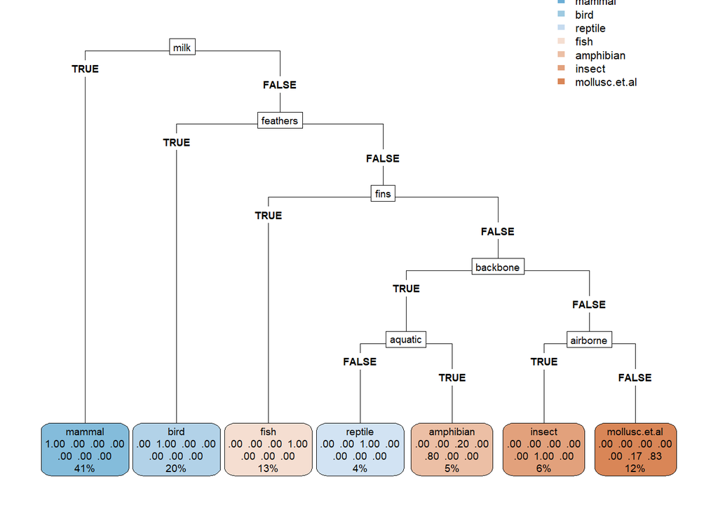

```r
rpart.plot(treeModelData,
           box.palette = "BuBn",
           type = 5)
```

Joonis aitab meil mõtestada, kuidas erinevad loomad on kategooriate vahel jaotatud. Alumisest reast näeme gruppide osakaale. Näiteks Esimesel tasandil näeme, milline tegur kõige rohkem erinevaid loomi eristab.

Vaatame mudelit lähemalt. `printcp` näitab jagunemiste kaupa, kuidas viga on erinevate jaotamistega vähenenud.

```r
printcp(treeModelData, digits = 3)
```

```
##
## Classification tree:
## rpart::rpart(formula = f, data = d, xval = 0, minsplit = 6, minbucket = 3,
##     cp = 0.0167827046941966, maxdepth = 7)
##
## Variables actually used in tree construction:
## [1] airborne aquatic  backbone feathers fins     milk
##
## Root node error: 60/101 = 0.594
##
## n= 101
##
##       CP nsplit rel error
## 1 0.3333      0     1.000
## 2 0.2167      1     0.667
## 3 0.1667      2     0.450
## 4 0.0917      3     0.283
## 5 0.0500      5     0.100
## 6 0.0168      6     0.050
```

Mudeli põhjalik kokkuvõte:

```r
summary(treeModelData)
```

```
## Call:
## rpart::rpart(formula = f, data = d, xval = 0, minsplit = 6, minbucket = 3,
##     cp = 0.0167827046941966, maxdepth = 7)
##   n= 101
##
##           CP nsplit rel error
## 1 0.33333333      0 1.0000000
## 2 0.21666667      1 0.6666667
## 3 0.16666667      2 0.4500000
## 4 0.09166667      3 0.2833333
## 5 0.05000000      5 0.1000000
## 6 0.01678270      6 0.0500000
##
## Variable importance
##     milk     hair     eggs  toothed     legs feathers  catsize airborne
##       14       14       13        9        8        8        7        7
##     fins     tail backbone breathes  aquatic domestic
##        5        5        5        3        1        1
##
## Node number 1: 101 observations,    complexity param=0.3333333
##   predicted class=mammal         expected loss=0.5940594  P(node) =1
##     class counts:    41    20     5    13     4     8    10
##    probabilities: 0.406 0.198 0.050 0.129 0.040 0.079 0.099
##   left son=2 (41 obs) right son=3 (60 obs)
##   Primary splits:
##       milk     splits as  RL, improve=29.59307, (0 missing)
##       eggs     splits as  LR, improve=26.49694, (0 missing)
##       hair     splits as  RL, improve=24.02346, (0 missing)
##       feathers splits as  RL, improve=21.06344, (0 missing)
##       toothed  splits as  RL, improve=19.36766, (0 missing)
##   Surrogate splits:
##       eggs    splits as  LR,      agree=0.970, adj=0.927, (0 split)
##       hair    splits as  RL,      agree=0.941, adj=0.854, (0 split)
##       catsize splits as  RL,      agree=0.792, adj=0.488, (0 split)
##       toothed splits as  RL,      agree=0.782, adj=0.463, (0 split)
##       legs    < 3   to the right, agree=0.703, adj=0.268, (0 split)
##
## Node number 2: 41 observations
##   predicted class=mammal         expected loss=0  P(node) =0.4059406
##     class counts:    41     0     0     0     0     0     0
```

[output cut: 99 more lines]

```
##
## Node number 61: 5 observations
##   predicted class=amphibian      expected loss=0.2  P(node) =0.04950495
##     class counts:     0     0     1     0     4     0     0
##    probabilities: 0.000 0.000 0.200 0.000 0.800 0.000 0.000
##
## Node number 62: 6 observations
##   predicted class=insect         expected loss=0  P(node) =0.05940594
##     class counts:     0     0     0     0     0     6     0
##    probabilities: 0.000 0.000 0.000 0.000 0.000 1.000 0.000
##
## Node number 63: 12 observations
##   predicted class=mollusc.et.al  expected loss=0.1666667  P(node) =0.1188119
##     class counts:     0     0     0     0     0     2    10
##    probabilities: 0.000 0.000 0.000 0.000 0.000 0.167 0.833
```

Edaspidi saaksime seda mudelit uute andmete peal kasutada nii:

```r
# predict(tunedTreeModel, newdata = ...)
```

# 4. Valideerimine

Selleks, et vea suurust täpsemalt hinnata ei pruugi piisata eelnevalt tehtud valideerimisest. Saame kasutada pesastatud valideerimist (*nested cross-validation*), kus optimaalsete hüperaparameetrite otsing ja nende valideerimine, kaasatakse omakorda mudeli valideerimisse. Valideeritakse kogu mudeli koostamise protsessi integreeritud tervikuna. Kuigi meil oli eelnevalt kriteeriumid sõnastatud (*treeParamSpace*), siis tegelikult me ei integreerinud mudeli valideerimist ja hüperparameetrite otsingu valideerimist kokku.

Järgnevalt aga proovime seda teha. Tulemusels võiks olla realistlik hinnang uute andmete täpsuse osas.

Kasutatakse kahte valideerimisskeemi. Välimine valideerimisskeem, mis defineeritakse objektis *outer* (viiekordne valideerimine).

```r
outer <- makeResampleDesc('CV', iters = 5)
```

Eraldi pannakse paika hüperparameetrite otsing, kus on omakorda valideerimine sees, mis järgib eelnevalt kirja pandud eeskirja (*cvForTuning*).

```r
treewrapper <- makeTuneWrapper('classif.rpart',
                               resampling = cvForTuning,
                               par.set = treeParamSpace,
                               control = randSearch)
```

   EHK meil on 2 valideerimisskeemi. Üks on mudeli koostamise jaoks ja teine hüperparameetrite otsimiseks. Üks valideerimisskeem on pesastatud teise sees. See peaks tagama selle, et hüperparameetrite otsingut tehakse mitmeid kordi läbi ja selle tulemused edastatakse mudeli koostamisse ja testimisse.

```r
cvWithTuning <- resample(treewrapper, zooTask, resampling = outer)
```

```
## Resampling: cross-validation
```

```
## Measures:             mmce
```

```
## [Tune] Started tuning learner classif.rpart for parameter set:
```

```
##              Type len Def      Constr Req Tunable Trafo
## minsplit  integer   -   -     5 to 20   -    TRUE     -
## minbucket integer   -   -     3 to 10   -    TRUE     -
## cp        numeric   -   - 0.01 to 0.1   -    TRUE     -
## maxdepth  integer   -   -     3 to 10   -    TRUE     -
```

```
## With control class: TuneControlRandom
```

```
## Imputation value: 1
```

```
## [Tune-x] 1: minsplit=17; minbucket=7; cp=0.0516; maxdepth=5
```

```
## [Tune-y] 1: mmce.test.mean=0.1992647; time: 0.0 min
```

```
## [Tune-x] 2: minsplit=14; minbucket=6; cp=0.0811; maxdepth=3
```

```
## [Tune-y] 2: mmce.test.mean=0.2360294; time: 0.0 min
```

```
## [Tune-x] 3: minsplit=11; minbucket=7; cp=0.0229; maxdepth=3
```

```
## [Tune-y] 3: mmce.test.mean=0.2360294; time: 0.0 min
```

```
## [Tune-x] 4: minsplit=7; minbucket=10; cp=0.0242; maxdepth=5
```

```
## [Tune-y] 4: mmce.test.mean=0.2360294; time: 0.0 min
```

```
## [Tune-x] 5: minsplit=13; minbucket=3; cp=0.0676; maxdepth=7
```

```
## [Tune-y] 5: mmce.test.mean=0.1742647; time: 0.0 min
```

```
## [Tune-x] 6: minsplit=10; minbucket=7; cp=0.036; maxdepth=8
```

```
## [Tune-y] 6: mmce.test.mean=0.1992647; time: 0.0 min
```

```
## [Tune-x] 7: minsplit=8; minbucket=4; cp=0.0324; maxdepth=8
```

```
## [Tune-y] 7: mmce.test.mean=0.1617647; time: 0.0 min
```

```
## [Tune-x] 8: minsplit=11; minbucket=3; cp=0.0362; maxdepth=7
```

```
## [Tune-y] 8: mmce.test.mean=0.1742647; time: 0.0 min
```

```
## [Tune-x] 9: minsplit=5; minbucket=5; cp=0.0458; maxdepth=4
```

```
## [Tune-y] 9: mmce.test.mean=0.2110294; time: 0.0 min
```

```
## [Tune-x] 10: minsplit=17; minbucket=5; cp=0.0666; maxdepth=5
```

```
## [Tune-y] 10: mmce.test.mean=0.2235294; time: 0.0 min
```

```
## [Tune-x] 11: minsplit=9; minbucket=8; cp=0.0976; maxdepth=3
```

```
## [Tune-y] 11: mmce.test.mean=0.2360294; time: 0.0 min
```

```
## [Tune-x] 12: minsplit=14; minbucket=7; cp=0.05; maxdepth=10
```

```
## [Tune-y] 12: mmce.test.mean=0.1992647; time: 0.0 min
```

```
## [Tune-x] 13: minsplit=13; minbucket=5; cp=0.0363; maxdepth=8
```

```
## [Tune-y] 13: mmce.test.mean=0.1742647; time: 0.0 min
```

```
## [Tune-x] 14: minsplit=11; minbucket=6; cp=0.0986; maxdepth=3
```

```
## [Tune-y] 14: mmce.test.mean=0.2360294; time: 0.0 min
```

```
## [Tune-x] 15: minsplit=10; minbucket=6; cp=0.0793; maxdepth=6
```

```
## [Tune-y] 15: mmce.test.mean=0.2235294; time: 0.0 min
```

```
## [Tune-x] 16: minsplit=13; minbucket=9; cp=0.0565; maxdepth=9
```

```
## [Tune-y] 16: mmce.test.mean=0.2110294; time: 0.0 min
```

```
## [Tune-x] 17: minsplit=6; minbucket=5; cp=0.0204; maxdepth=8
```

```
## [Tune-y] 17: mmce.test.mean=0.1242647; time: 0.0 min
```

```
## [Tune-x] 18: minsplit=15; minbucket=3; cp=0.0514; maxdepth=7
```

```
## [Tune-y] 18: mmce.test.mean=0.2110294; time: 0.0 min
```

```
## [Tune-x] 19: minsplit=9; minbucket=6; cp=0.0982; maxdepth=8
```

```
## [Tune-y] 19: mmce.test.mean=0.2360294; time: 0.0 min
```

```
## [Tune-x] 20: minsplit=16; minbucket=10; cp=0.0247; maxdepth=3
```

```
## [Tune-y] 20: mmce.test.mean=0.2360294; time: 0.0 min
```

```
## [Tune-x] 21: minsplit=20; minbucket=4; cp=0.0483; maxdepth=6
```

```
## [Tune-y] 21: mmce.test.mean=0.2360294; time: 0.0 min
```

```
## [Tune-x] 22: minsplit=17; minbucket=9; cp=0.0661; maxdepth=5
```

```
## [Tune-y] 22: mmce.test.mean=0.2110294; time: 0.0 min
```

```
## [Tune-x] 23: minsplit=11; minbucket=5; cp=0.0585; maxdepth=3
```

```
## [Tune-y] 23: mmce.test.mean=0.2360294; time: 0.0 min
```

```
## [Tune-x] 24: minsplit=9; minbucket=7; cp=0.0346; maxdepth=7
```

```
## [Tune-y] 24: mmce.test.mean=0.1992647; time: 0.0 min
```

```
## [Tune-x] 25: minsplit=8; minbucket=3; cp=0.0147; maxdepth=8
```

```
## [Tune-y] 25: mmce.test.mean=0.1367647; time: 0.0 min
```

```
## [Tune-x] 26: minsplit=13; minbucket=4; cp=0.0984; maxdepth=9
```

```
## [Tune-y] 26: mmce.test.mean=0.2360294; time: 0.0 min
```

```
## [Tune-x] 27: minsplit=19; minbucket=6; cp=0.0757; maxdepth=10
```

```
## [Tune-y] 27: mmce.test.mean=0.2360294; time: 0.0 min
```

```
## [Tune-x] 28: minsplit=16; minbucket=7; cp=0.0583; maxdepth=5
```

```
## [Tune-y] 28: mmce.test.mean=0.1992647; time: 0.0 min
```

```
## [Tune-x] 29: minsplit=16; minbucket=4; cp=0.0135; maxdepth=5
```

```
## [Tune-y] 29: mmce.test.mean=0.2235294; time: 0.0 min
```

```
## [Tune-x] 30: minsplit=5; minbucket=7; cp=0.018; maxdepth=6
```

```
## [Tune-y] 30: mmce.test.mean=0.1617647; time: 0.0 min
```

```
## [Tune-x] 31: minsplit=6; minbucket=7; cp=0.0813; maxdepth=8
```

```
## [Tune-y] 31: mmce.test.mean=0.2110294; time: 0.0 min
```

```
## [Tune-x] 32: minsplit=18; minbucket=4; cp=0.0337; maxdepth=3
```

```
## [Tune-y] 32: mmce.test.mean=0.2360294; time: 0.0 min
```

```
## [Tune-x] 33: minsplit=16; minbucket=9; cp=0.0736; maxdepth=9
```

```
## [Tune-y] 33: mmce.test.mean=0.2235294; time: 0.0 min
```

```
## [Tune-x] 34: minsplit=17; minbucket=7; cp=0.0112; maxdepth=9
```

```
## [Tune-y] 34: mmce.test.mean=0.1992647; time: 0.0 min
```

```
## [Tune-x] 35: minsplit=15; minbucket=4; cp=0.0406; maxdepth=3
```

```
## [Tune-y] 35: mmce.test.mean=0.2360294; time: 0.0 min
```

```
## [Tune-x] 36: minsplit=20; minbucket=10; cp=0.0282; maxdepth=7
```

```
## [Tune-y] 36: mmce.test.mean=0.2360294; time: 0.0 min
```

```
## [Tune-x] 37: minsplit=6; minbucket=3; cp=0.0329; maxdepth=4
```

```
## [Tune-y] 37: mmce.test.mean=0.2110294; time: 0.0 min
```

```
## [Tune-x] 38: minsplit=19; minbucket=6; cp=0.0343; maxdepth=9
```

```
## [Tune-y] 38: mmce.test.mean=0.2360294; time: 0.0 min
```

```
## [Tune-x] 39: minsplit=12; minbucket=10; cp=0.0543; maxdepth=3
```

```
## [Tune-y] 39: mmce.test.mean=0.2360294; time: 0.0 min
```

```
## [Tune-x] 40: minsplit=16; minbucket=6; cp=0.0661; maxdepth=5
```

```
## [Tune-y] 40: mmce.test.mean=0.2235294; time: 0.0 min
```

```
## [Tune-x] 41: minsplit=14; minbucket=3; cp=0.0784; maxdepth=9
```

```
## [Tune-y] 41: mmce.test.mean=0.2360294; time: 0.0 min
```

```
## [Tune-x] 42: minsplit=9; minbucket=3; cp=0.0194; maxdepth=3
```

```
## [Tune-y] 42: mmce.test.mean=0.2360294; time: 0.0 min
```

```
## [Tune-x] 43: minsplit=6; minbucket=6; cp=0.0979; maxdepth=8
```

```
## [Tune-y] 43: mmce.test.mean=0.2360294; time: 0.0 min
```

```
## [Tune-x] 44: minsplit=15; minbucket=5; cp=0.0748; maxdepth=10
```

```
## [Tune-y] 44: mmce.test.mean=0.2235294; time: 0.0 min
```

```
## [Tune-x] 45: minsplit=14; minbucket=8; cp=0.0343; maxdepth=6
```

```
## [Tune-y] 45: mmce.test.mean=0.1985294; time: 0.0 min
```

```
## [Tune-x] 46: minsplit=18; minbucket=5; cp=0.0159; maxdepth=7
```

```
## [Tune-y] 46: mmce.test.mean=0.2235294; time: 0.0 min
```

```
## [Tune-x] 47: minsplit=13; minbucket=10; cp=0.087; maxdepth=6
```

```
## [Tune-y] 47: mmce.test.mean=0.2360294; time: 0.0 min
```

```
## [Tune-x] 48: minsplit=6; minbucket=3; cp=0.0554; maxdepth=6
```

```
## [Tune-y] 48: mmce.test.mean=0.1125000; time: 0.0 min
```

```
## [Tune-x] 49: minsplit=12; minbucket=10; cp=0.0831; maxdepth=7
```

```
## [Tune-y] 49: mmce.test.mean=0.2360294; time: 0.0 min
```

```
## [Tune-x] 50: minsplit=19; minbucket=4; cp=0.0583; maxdepth=5
```

```
## [Tune-y] 50: mmce.test.mean=0.2360294; time: 0.0 min
```

```
## [Tune-x] 51: minsplit=19; minbucket=8; cp=0.0206; maxdepth=5
```

```
## [Tune-y] 51: mmce.test.mean=0.2360294; time: 0.0 min
```

```
## [Tune-x] 52: minsplit=7; minbucket=8; cp=0.0183; maxdepth=7
```

```
## [Tune-y] 52: mmce.test.mean=0.1985294; time: 0.0 min
```

```
## [Tune-x] 53: minsplit=9; minbucket=4; cp=0.0812; maxdepth=5
```

```
## [Tune-y] 53: mmce.test.mean=0.1742647; time: 0.0 min
```

```
## [Tune-x] 54: minsplit=11; minbucket=5; cp=0.0475; maxdepth=4
```

```
## [Tune-y] 54: mmce.test.mean=0.2110294; time: 0.0 min
```

```
## [Tune-x] 55: minsplit=16; minbucket=6; cp=0.0475; maxdepth=4
```

```
## [Tune-y] 55: mmce.test.mean=0.2235294; time: 0.0 min
```

```
## [Tune-x] 56: minsplit=13; minbucket=10; cp=0.0119; maxdepth=6
```

```
## [Tune-y] 56: mmce.test.mean=0.2360294; time: 0.0 min
```

```
## [Tune-x] 57: minsplit=16; minbucket=4; cp=0.0192; maxdepth=10
```

```
## [Tune-y] 57: mmce.test.mean=0.2235294; time: 0.0 min
```

```
## [Tune-x] 58: minsplit=19; minbucket=5; cp=0.0495; maxdepth=5
```

```
## [Tune-y] 58: mmce.test.mean=0.2360294; time: 0.0 min
```

```
## [Tune-x] 59: minsplit=18; minbucket=9; cp=0.0244; maxdepth=3
```

```
## [Tune-y] 59: mmce.test.mean=0.2360294; time: 0.0 min
```

```
## [Tune-x] 60: minsplit=16; minbucket=6; cp=0.0625; maxdepth=4
```

```
## [Tune-y] 60: mmce.test.mean=0.2235294; time: 0.0 min
```

```
## [Tune-x] 61: minsplit=17; minbucket=10; cp=0.0101; maxdepth=4
```

```
## [Tune-y] 61: mmce.test.mean=0.2360294; time: 0.0 min
```

```
## [Tune-x] 62: minsplit=15; minbucket=9; cp=0.085; maxdepth=4
```

```
## [Tune-y] 62: mmce.test.mean=0.2235294; time: 0.0 min
```

```
## [Tune-x] 63: minsplit=13; minbucket=10; cp=0.0669; maxdepth=10
```

```
## [Tune-y] 63: mmce.test.mean=0.2360294; time: 0.0 min
```

```
## [Tune-x] 64: minsplit=9; minbucket=7; cp=0.0163; maxdepth=9
```

```
## [Tune-y] 64: mmce.test.mean=0.1617647; time: 0.0 min
```

```
## [Tune-x] 65: minsplit=12; minbucket=7; cp=0.0246; maxdepth=7
```

```
## [Tune-y] 65: mmce.test.mean=0.1617647; time: 0.0 min
```

```
## [Tune-x] 66: minsplit=16; minbucket=6; cp=0.0926; maxdepth=9
```

```
## [Tune-y] 66: mmce.test.mean=0.2235294; time: 0.0 min
```

```
## [Tune-x] 67: minsplit=11; minbucket=10; cp=0.0925; maxdepth=9
```

```
## [Tune-y] 67: mmce.test.mean=0.2360294; time: 0.0 min
```

```
## [Tune-x] 68: minsplit=9; minbucket=10; cp=0.0115; maxdepth=5
```

```
## [Tune-y] 68: mmce.test.mean=0.2360294; time: 0.0 min
```

```
## [Tune-x] 69: minsplit=6; minbucket=7; cp=0.0878; maxdepth=9
```

```
## [Tune-y] 69: mmce.test.mean=0.2110294; time: 0.0 min
```

```
## [Tune-x] 70: minsplit=16; minbucket=7; cp=0.0594; maxdepth=6
```

```
## [Tune-y] 70: mmce.test.mean=0.1992647; time: 0.0 min
```

```
## [Tune-x] 71: minsplit=16; minbucket=6; cp=0.056; maxdepth=5
```

```
## [Tune-y] 71: mmce.test.mean=0.2235294; time: 0.0 min
```

```
## [Tune-x] 72: minsplit=12; minbucket=5; cp=0.0577; maxdepth=3
```

```
## [Tune-y] 72: mmce.test.mean=0.2360294; time: 0.0 min
```

```
## [Tune-x] 73: minsplit=15; minbucket=4; cp=0.0446; maxdepth=3
```

```
## [Tune-y] 73: mmce.test.mean=0.2360294; time: 0.0 min
```

```
## [Tune-x] 74: minsplit=15; minbucket=5; cp=0.0496; maxdepth=6
```

```
## [Tune-y] 74: mmce.test.mean=0.2110294; time: 0.0 min
```

```
## [Tune-x] 75: minsplit=14; minbucket=9; cp=0.0959; maxdepth=7
```

```
## [Tune-y] 75: mmce.test.mean=0.2360294; time: 0.0 min
```

```
## [Tune-x] 76: minsplit=5; minbucket=9; cp=0.0633; maxdepth=5
```

```
## [Tune-y] 76: mmce.test.mean=0.2110294; time: 0.0 min
```

```
## [Tune-x] 77: minsplit=18; minbucket=8; cp=0.0106; maxdepth=3
```

```
## [Tune-y] 77: mmce.test.mean=0.2360294; time: 0.0 min
```

```
## [Tune-x] 78: minsplit=9; minbucket=5; cp=0.0218; maxdepth=8
```

```
## [Tune-y] 78: mmce.test.mean=0.1242647; time: 0.0 min
```

```
## [Tune-x] 79: minsplit=10; minbucket=10; cp=0.0187; maxdepth=10
```

```
## [Tune-y] 79: mmce.test.mean=0.2360294; time: 0.0 min
```

```
## [Tune-x] 80: minsplit=14; minbucket=5; cp=0.0908; maxdepth=7
```

```
## [Tune-y] 80: mmce.test.mean=0.2360294; time: 0.0 min
```

```
## [Tune-x] 81: minsplit=14; minbucket=9; cp=0.0507; maxdepth=6
```

```
## [Tune-y] 81: mmce.test.mean=0.2110294; time: 0.0 min
```

```
## [Tune-x] 82: minsplit=18; minbucket=5; cp=0.0374; maxdepth=6
```

```
## [Tune-y] 82: mmce.test.mean=0.2235294; time: 0.0 min
```

```
## [Tune-x] 83: minsplit=16; minbucket=6; cp=0.048; maxdepth=8
```

```
## [Tune-y] 83: mmce.test.mean=0.2235294; time: 0.0 min
```

```
## [Tune-x] 84: minsplit=11; minbucket=10; cp=0.092; maxdepth=3
```

```
## [Tune-y] 84: mmce.test.mean=0.2360294; time: 0.0 min
```

```
## [Tune-x] 85: minsplit=12; minbucket=8; cp=0.0844; maxdepth=4
```

```
## [Tune-y] 85: mmce.test.mean=0.2235294; time: 0.0 min
```

```
## [Tune-x] 86: minsplit=17; minbucket=6; cp=0.0597; maxdepth=7
```

```
## [Tune-y] 86: mmce.test.mean=0.2235294; time: 0.0 min
```

```
## [Tune-x] 87: minsplit=12; minbucket=10; cp=0.0885; maxdepth=4
```

```
## [Tune-y] 87: mmce.test.mean=0.2360294; time: 0.0 min
```

```
## [Tune-x] 88: minsplit=19; minbucket=7; cp=0.0754; maxdepth=5
```

```
## [Tune-y] 88: mmce.test.mean=0.2360294; time: 0.0 min
```

```
## [Tune-x] 89: minsplit=6; minbucket=8; cp=0.0794; maxdepth=6
```

```
## [Tune-y] 89: mmce.test.mean=0.2235294; time: 0.0 min
```

```
## [Tune-x] 90: minsplit=18; minbucket=4; cp=0.0411; maxdepth=8
```

```
## [Tune-y] 90: mmce.test.mean=0.2235294; time: 0.0 min
```

```
## [Tune-x] 91: minsplit=7; minbucket=3; cp=0.0735; maxdepth=9
```

```
## [Tune-y] 91: mmce.test.mean=0.1367647; time: 0.0 min
```

```
## [Tune-x] 92: minsplit=8; minbucket=4; cp=0.0305; maxdepth=4
```

```
## [Tune-y] 92: mmce.test.mean=0.2110294; time: 0.0 min
```

```
## [Tune-x] 93: minsplit=17; minbucket=5; cp=0.0819; maxdepth=8
```

```
## [Tune-y] 93: mmce.test.mean=0.2360294; time: 0.0 min
```

```
## [Tune-x] 94: minsplit=7; minbucket=10; cp=0.0115; maxdepth=6
```

```
## [Tune-y] 94: mmce.test.mean=0.2360294; time: 0.0 min
```

```
## [Tune-x] 95: minsplit=10; minbucket=8; cp=0.0854; maxdepth=4
```

```
## [Tune-y] 95: mmce.test.mean=0.2235294; time: 0.0 min
```

```
## [Tune-x] 96: minsplit=9; minbucket=6; cp=0.0913; maxdepth=9
```

```
## [Tune-y] 96: mmce.test.mean=0.2235294; time: 0.0 min
```

```
## [Tune-x] 97: minsplit=14; minbucket=4; cp=0.0983; maxdepth=10
```

```
## [Tune-y] 97: mmce.test.mean=0.2360294; time: 0.0 min
```

```
## [Tune-x] 98: minsplit=20; minbucket=4; cp=0.0427; maxdepth=9
```

```
## [Tune-y] 98: mmce.test.mean=0.2360294; time: 0.0 min
```

```
## [Tune-x] 99: minsplit=19; minbucket=4; cp=0.0839; maxdepth=8
```

```
## [Tune-y] 99: mmce.test.mean=0.2360294; time: 0.0 min
```

```
## [Tune-x] 100: minsplit=5; minbucket=8; cp=0.0131; maxdepth=4
```

```
## [Tune-y] 100: mmce.test.mean=0.1985294; time: 0.0 min
```

```
## [Tune-x] 101: minsplit=15; minbucket=9; cp=0.0972; maxdepth=4
```

```
## [Tune-y] 101: mmce.test.mean=0.2360294; time: 0.0 min
```

```
## [Tune-x] 102: minsplit=8; minbucket=10; cp=0.0906; maxdepth=9
```

```
## [Tune-y] 102: mmce.test.mean=0.2360294; time: 0.0 min
```

```
## [Tune-x] 103: minsplit=5; minbucket=10; cp=0.0852; maxdepth=9
```

```
## [Tune-y] 103: mmce.test.mean=0.2360294; time: 0.0 min
```

```
## [Tune-x] 104: minsplit=13; minbucket=3; cp=0.0891; maxdepth=10
```

```
## [Tune-y] 104: mmce.test.mean=0.2360294; time: 0.0 min
```

```
## [Tune-x] 105: minsplit=16; minbucket=4; cp=0.0552; maxdepth=7
```

```
## [Tune-y] 105: mmce.test.mean=0.2235294; time: 0.0 min
```

```
## [Tune-x] 106: minsplit=10; minbucket=6; cp=0.0471; maxdepth=7
```

```
## [Tune-y] 106: mmce.test.mean=0.2117647; time: 0.0 min
```

```
## [Tune-x] 107: minsplit=14; minbucket=5; cp=0.0795; maxdepth=10
```

```
## [Tune-y] 107: mmce.test.mean=0.2360294; time: 0.0 min
```

```
## [Tune-x] 108: minsplit=7; minbucket=3; cp=0.0922; maxdepth=6
```

```
## [Tune-y] 108: mmce.test.mean=0.2235294; time: 0.0 min
```

```
## [Tune-x] 109: minsplit=6; minbucket=9; cp=0.0293; maxdepth=6
```

```
## [Tune-y] 109: mmce.test.mean=0.2110294; time: 0.0 min
```

```
## [Tune-x] 110: minsplit=11; minbucket=3; cp=0.0844; maxdepth=10
```

```
## [Tune-y] 110: mmce.test.mean=0.2242647; time: 0.0 min
```

```
## [Tune-x] 111: minsplit=6; minbucket=5; cp=0.0467; maxdepth=8
```

```
## [Tune-y] 111: mmce.test.mean=0.1617647; time: 0.0 min
```

```
## [Tune-x] 112: minsplit=20; minbucket=3; cp=0.0891; maxdepth=10
```

```
## [Tune-y] 112: mmce.test.mean=0.2360294; time: 0.0 min
```

```
## [Tune-x] 113: minsplit=17; minbucket=10; cp=0.0893; maxdepth=8
```

```
## [Tune-y] 113: mmce.test.mean=0.2360294; time: 0.0 min
```

```
## [Tune-x] 114: minsplit=20; minbucket=5; cp=0.0341; maxdepth=10
```

```
## [Tune-y] 114: mmce.test.mean=0.2360294; time: 0.0 min
```

```
## [Tune-x] 115: minsplit=20; minbucket=8; cp=0.0739; maxdepth=7
```

```
## [Tune-y] 115: mmce.test.mean=0.2360294; time: 0.0 min
```

```
## [Tune-x] 116: minsplit=14; minbucket=9; cp=0.012; maxdepth=3
```

```
## [Tune-y] 116: mmce.test.mean=0.2360294; time: 0.0 min
```

```
## [Tune-x] 117: minsplit=15; minbucket=3; cp=0.0682; maxdepth=8
```

```
## [Tune-y] 117: mmce.test.mean=0.2110294; time: 0.0 min
```

```
## [Tune-x] 118: minsplit=8; minbucket=6; cp=0.0241; maxdepth=8
```

```
## [Tune-y] 118: mmce.test.mean=0.1742647; time: 0.0 min
```

```
## [Tune-x] 119: minsplit=7; minbucket=10; cp=0.0741; maxdepth=6
```

```
## [Tune-y] 119: mmce.test.mean=0.2360294; time: 0.0 min
```

```
## [Tune-x] 120: minsplit=16; minbucket=9; cp=0.0733; maxdepth=3
```

```
## [Tune-y] 120: mmce.test.mean=0.2360294; time: 0.0 min
```

```
## [Tune-x] 121: minsplit=14; minbucket=6; cp=0.0124; maxdepth=10
```

```
## [Tune-y] 121: mmce.test.mean=0.1860294; time: 0.0 min
```

```
## [Tune-x] 122: minsplit=5; minbucket=9; cp=0.0575; maxdepth=3
```

```
## [Tune-y] 122: mmce.test.mean=0.2360294; time: 0.0 min
```

```
## [Tune-x] 123: minsplit=18; minbucket=9; cp=0.0654; maxdepth=3
```

```
## [Tune-y] 123: mmce.test.mean=0.2360294; time: 0.0 min
```

```
## [Tune-x] 124: minsplit=6; minbucket=4; cp=0.0293; maxdepth=7
```

```
## [Tune-y] 124: mmce.test.mean=0.1617647; time: 0.0 min
```

```
## [Tune-x] 125: minsplit=9; minbucket=10; cp=0.0293; maxdepth=6
```

```
## [Tune-y] 125: mmce.test.mean=0.2360294; time: 0.0 min
```

```
## [Tune-x] 126: minsplit=8; minbucket=4; cp=0.0686; maxdepth=4
```

```
## [Tune-y] 126: mmce.test.mean=0.2110294; time: 0.0 min
```

```
## [Tune-x] 127: minsplit=5; minbucket=10; cp=0.0112; maxdepth=6
```

```
## [Tune-y] 127: mmce.test.mean=0.2360294; time: 0.0 min
```

```
## [Tune-x] 128: minsplit=20; minbucket=4; cp=0.0378; maxdepth=8
```

```
## [Tune-y] 128: mmce.test.mean=0.2360294; time: 0.0 min
```

```
## [Tune-x] 129: minsplit=5; minbucket=3; cp=0.0471; maxdepth=3
```

```
## [Tune-y] 129: mmce.test.mean=0.2360294; time: 0.0 min
```

```
## [Tune-x] 130: minsplit=7; minbucket=8; cp=0.0333; maxdepth=7
```

```
## [Tune-y] 130: mmce.test.mean=0.1985294; time: 0.0 min
```

```
## [Tune-x] 131: minsplit=6; minbucket=6; cp=0.0426; maxdepth=5
```

```
## [Tune-y] 131: mmce.test.mean=0.2117647; time: 0.0 min
```

```
## [Tune-x] 132: minsplit=17; minbucket=4; cp=0.0146; maxdepth=6
```

```
## [Tune-y] 132: mmce.test.mean=0.2235294; time: 0.0 min
```

```
## [Tune-x] 133: minsplit=11; minbucket=10; cp=0.0479; maxdepth=4
```

```
## [Tune-y] 133: mmce.test.mean=0.2360294; time: 0.0 min
```

```
## [Tune-x] 134: minsplit=18; minbucket=9; cp=0.0265; maxdepth=7
```

```
## [Tune-y] 134: mmce.test.mean=0.2110294; time: 0.0 min
```

```
## [Tune-x] 135: minsplit=6; minbucket=7; cp=0.0307; maxdepth=9
```

```
## [Tune-y] 135: mmce.test.mean=0.1992647; time: 0.0 min
```

```
## [Tune-x] 136: minsplit=5; minbucket=3; cp=0.0411; maxdepth=6
```

```
## [Tune-y] 136: mmce.test.mean=0.1125000; time: 0.0 min
```

```
## [Tune-x] 137: minsplit=16; minbucket=9; cp=0.042; maxdepth=7
```

```
## [Tune-y] 137: mmce.test.mean=0.2110294; time: 0.0 min
```

```
## [Tune-x] 138: minsplit=18; minbucket=3; cp=0.057; maxdepth=4
```

```
## [Tune-y] 138: mmce.test.mean=0.2235294; time: 0.0 min
```

```
## [Tune-x] 139: minsplit=14; minbucket=4; cp=0.0926; maxdepth=3
```

```
## [Tune-y] 139: mmce.test.mean=0.2360294; time: 0.0 min
```

```
## [Tune-x] 140: minsplit=18; minbucket=3; cp=0.0271; maxdepth=9
```

```
## [Tune-y] 140: mmce.test.mean=0.2235294; time: 0.0 min
```

```
## [Tune-x] 141: minsplit=12; minbucket=10; cp=0.0191; maxdepth=10
```

```
## [Tune-y] 141: mmce.test.mean=0.2360294; time: 0.0 min
```

```
## [Tune-x] 142: minsplit=17; minbucket=4; cp=0.0402; maxdepth=4
```

```
## [Tune-y] 142: mmce.test.mean=0.2235294; time: 0.0 min
```

```
## [Tune-x] 143: minsplit=5; minbucket=10; cp=0.0431; maxdepth=10
```

```
## [Tune-y] 143: mmce.test.mean=0.2360294; time: 0.0 min
```

```
## [Tune-x] 144: minsplit=11; minbucket=8; cp=0.0514; maxdepth=9
```

```
## [Tune-y] 144: mmce.test.mean=0.2235294; time: 0.0 min
```

```
## [Tune-x] 145: minsplit=10; minbucket=5; cp=0.0409; maxdepth=5
```

```
## [Tune-y] 145: mmce.test.mean=0.1617647; time: 0.0 min
```

```
## [Tune-x] 146: minsplit=17; minbucket=10; cp=0.0684; maxdepth=6
```

```
## [Tune-y] 146: mmce.test.mean=0.2360294; time: 0.0 min
```

```
## [Tune-x] 147: minsplit=5; minbucket=9; cp=0.053; maxdepth=8
```

```
## [Tune-y] 147: mmce.test.mean=0.2110294; time: 0.0 min
```

```
## [Tune-x] 148: minsplit=16; minbucket=6; cp=0.0139; maxdepth=10
```

```
## [Tune-y] 148: mmce.test.mean=0.2235294; time: 0.0 min
```

```
## [Tune-x] 149: minsplit=18; minbucket=3; cp=0.0424; maxdepth=8
```

```
## [Tune-y] 149: mmce.test.mean=0.2235294; time: 0.0 min
```

```
## [Tune-x] 150: minsplit=9; minbucket=10; cp=0.031; maxdepth=8
```

```
## [Tune-y] 150: mmce.test.mean=0.2360294; time: 0.0 min
```

```
## [Tune-x] 151: minsplit=10; minbucket=9; cp=0.0808; maxdepth=6
```

```
## [Tune-y] 151: mmce.test.mean=0.2235294; time: 0.0 min
```

```
## [Tune-x] 152: minsplit=17; minbucket=6; cp=0.0695; maxdepth=4
```

```
## [Tune-y] 152: mmce.test.mean=0.2235294; time: 0.0 min
```

```
## [Tune-x] 153: minsplit=17; minbucket=9; cp=0.0127; maxdepth=3
```

```
## [Tune-y] 153: mmce.test.mean=0.2360294; time: 0.0 min
```

```
## [Tune-x] 154: minsplit=19; minbucket=9; cp=0.0512; maxdepth=5
```

```
## [Tune-y] 154: mmce.test.mean=0.2360294; time: 0.0 min
```

```
## [Tune-x] 155: minsplit=20; minbucket=3; cp=0.087; maxdepth=10
```

```
## [Tune-y] 155: mmce.test.mean=0.2360294; time: 0.0 min
```

```
## [Tune-x] 156: minsplit=17; minbucket=8; cp=0.0561; maxdepth=9
```

```
## [Tune-y] 156: mmce.test.mean=0.2235294; time: 0.0 min
```

```
## [Tune-x] 157: minsplit=18; minbucket=8; cp=0.067; maxdepth=8
```

```
## [Tune-y] 157: mmce.test.mean=0.2235294; time: 0.0 min
```

```
## [Tune-x] 158: minsplit=19; minbucket=6; cp=0.0377; maxdepth=8
```

```
## [Tune-y] 158: mmce.test.mean=0.2360294; time: 0.0 min
```

```
## [Tune-x] 159: minsplit=19; minbucket=10; cp=0.0574; maxdepth=3
```

```
## [Tune-y] 159: mmce.test.mean=0.2360294; time: 0.0 min
```

```
## [Tune-x] 160: minsplit=12; minbucket=10; cp=0.0866; maxdepth=7
```

```
## [Tune-y] 160: mmce.test.mean=0.2360294; time: 0.0 min
```

```
## [Tune-x] 161: minsplit=16; minbucket=6; cp=0.0554; maxdepth=9
```

```
## [Tune-y] 161: mmce.test.mean=0.2235294; time: 0.0 min
```

```
## [Tune-x] 162: minsplit=5; minbucket=10; cp=0.0478; maxdepth=6
```

```
## [Tune-y] 162: mmce.test.mean=0.2360294; time: 0.0 min
```

```
## [Tune-x] 163: minsplit=20; minbucket=3; cp=0.0901; maxdepth=8
```

```
## [Tune-y] 163: mmce.test.mean=0.2360294; time: 0.0 min
```

```
## [Tune-x] 164: minsplit=5; minbucket=3; cp=0.0283; maxdepth=3
```

```
## [Tune-y] 164: mmce.test.mean=0.2360294; time: 0.0 min
```

```
## [Tune-x] 165: minsplit=9; minbucket=6; cp=0.0336; maxdepth=4
```

```
## [Tune-y] 165: mmce.test.mean=0.2235294; time: 0.0 min
```

```
## [Tune-x] 166: minsplit=5; minbucket=6; cp=0.0708; maxdepth=3
```

```
## [Tune-y] 166: mmce.test.mean=0.2360294; time: 0.0 min
```

```
## [Tune-x] 167: minsplit=19; minbucket=8; cp=0.0539; maxdepth=8
```

```
## [Tune-y] 167: mmce.test.mean=0.2360294; time: 0.0 min
```

```
## [Tune-x] 168: minsplit=7; minbucket=4; cp=0.0215; maxdepth=7
```

```
## [Tune-y] 168: mmce.test.mean=0.1242647; time: 0.0 min
```

```
## [Tune-x] 169: minsplit=5; minbucket=7; cp=0.0339; maxdepth=4
```

```
## [Tune-y] 169: mmce.test.mean=0.1992647; time: 0.0 min
```

```
## [Tune-x] 170: minsplit=16; minbucket=8; cp=0.0796; maxdepth=9
```

```
## [Tune-y] 170: mmce.test.mean=0.2235294; time: 0.0 min
```

```
## [Tune-x] 171: minsplit=18; minbucket=6; cp=0.0766; maxdepth=8
```

```
## [Tune-y] 171: mmce.test.mean=0.2235294; time: 0.0 min
```

```
## [Tune-x] 172: minsplit=17; minbucket=5; cp=0.0474; maxdepth=3
```

```
## [Tune-y] 172: mmce.test.mean=0.2360294; time: 0.0 min
```

```
## [Tune-x] 173: minsplit=9; minbucket=6; cp=0.0449; maxdepth=4
```

```
## [Tune-y] 173: mmce.test.mean=0.2235294; time: 0.0 min
```

```
## [Tune-x] 174: minsplit=9; minbucket=3; cp=0.0679; maxdepth=5
```

```
## [Tune-y] 174: mmce.test.mean=0.1367647; time: 0.0 min
```

```
## [Tune-x] 175: minsplit=19; minbucket=8; cp=0.0105; maxdepth=6
```

```
## [Tune-y] 175: mmce.test.mean=0.2360294; time: 0.0 min
```

```
## [Tune-x] 176: minsplit=19; minbucket=3; cp=0.0795; maxdepth=3
```

```
## [Tune-y] 176: mmce.test.mean=0.2360294; time: 0.0 min
```

```
## [Tune-x] 177: minsplit=19; minbucket=5; cp=0.0599; maxdepth=9
```

```
## [Tune-y] 177: mmce.test.mean=0.2360294; time: 0.0 min
```

```
## [Tune-x] 178: minsplit=16; minbucket=3; cp=0.0914; maxdepth=3
```

```
## [Tune-y] 178: mmce.test.mean=0.2360294; time: 0.0 min
```

```
## [Tune-x] 179: minsplit=20; minbucket=10; cp=0.0378; maxdepth=4
```

```
## [Tune-y] 179: mmce.test.mean=0.2360294; time: 0.0 min
```

```
## [Tune-x] 180: minsplit=14; minbucket=4; cp=0.0913; maxdepth=10
```

```
## [Tune-y] 180: mmce.test.mean=0.2360294; time: 0.0 min
```

```
## [Tune-x] 181: minsplit=19; minbucket=9; cp=0.0515; maxdepth=10
```

```
## [Tune-y] 181: mmce.test.mean=0.2360294; time: 0.0 min
```

```
## [Tune-x] 182: minsplit=18; minbucket=10; cp=0.0601; maxdepth=8
```

```
## [Tune-y] 182: mmce.test.mean=0.2360294; time: 0.0 min
```

```
## [Tune-x] 183: minsplit=13; minbucket=10; cp=0.0148; maxdepth=10
```

```
## [Tune-y] 183: mmce.test.mean=0.2360294; time: 0.0 min
```

```
## [Tune-x] 184: minsplit=10; minbucket=9; cp=0.0427; maxdepth=3
```

```
## [Tune-y] 184: mmce.test.mean=0.2360294; time: 0.0 min
```

```
## [Tune-x] 185: minsplit=7; minbucket=9; cp=0.0921; maxdepth=6
```

```
## [Tune-y] 185: mmce.test.mean=0.2235294; time: 0.0 min
```

```
## [Tune-x] 186: minsplit=16; minbucket=7; cp=0.0894; maxdepth=3
```

```
## [Tune-y] 186: mmce.test.mean=0.2360294; time: 0.0 min
```

```
## [Tune-x] 187: minsplit=8; minbucket=8; cp=0.0702; maxdepth=10
```

```
## [Tune-y] 187: mmce.test.mean=0.2235294; time: 0.0 min
```

```
## [Tune-x] 188: minsplit=14; minbucket=3; cp=0.0178; maxdepth=8
```

```
## [Tune-y] 188: mmce.test.mean=0.2110294; time: 0.0 min
```

```
## [Tune-x] 189: minsplit=14; minbucket=9; cp=0.021; maxdepth=4
```

```
## [Tune-y] 189: mmce.test.mean=0.2110294; time: 0.0 min
```

```
## [Tune-x] 190: minsplit=10; minbucket=8; cp=0.0733; maxdepth=7
```

```
## [Tune-y] 190: mmce.test.mean=0.2235294; time: 0.0 min
```

```
## [Tune-x] 191: minsplit=6; minbucket=8; cp=0.087; maxdepth=10
```

```
## [Tune-y] 191: mmce.test.mean=0.2235294; time: 0.0 min
```

```
## [Tune-x] 192: minsplit=5; minbucket=8; cp=0.0679; maxdepth=5
```

```
## [Tune-y] 192: mmce.test.mean=0.2235294; time: 0.0 min
```

```
## [Tune-x] 193: minsplit=14; minbucket=9; cp=0.0249; maxdepth=3
```

```
## [Tune-y] 193: mmce.test.mean=0.2360294; time: 0.0 min
```

```
## [Tune-x] 194: minsplit=8; minbucket=10; cp=0.0617; maxdepth=3
```

```
## [Tune-y] 194: mmce.test.mean=0.2360294; time: 0.0 min
```

```
## [Tune-x] 195: minsplit=5; minbucket=8; cp=0.0346; maxdepth=4
```

```
## [Tune-y] 195: mmce.test.mean=0.1985294; time: 0.0 min
```

```
## [Tune-x] 196: minsplit=15; minbucket=9; cp=0.0721; maxdepth=9
```

```
## [Tune-y] 196: mmce.test.mean=0.2235294; time: 0.0 min
```

```
## [Tune-x] 197: minsplit=5; minbucket=5; cp=0.0266; maxdepth=3
```

```
## [Tune-y] 197: mmce.test.mean=0.2360294; time: 0.0 min
```

```
## [Tune-x] 198: minsplit=16; minbucket=3; cp=0.0687; maxdepth=3
```

```
## [Tune-y] 198: mmce.test.mean=0.2360294; time: 0.0 min
```

```
## [Tune-x] 199: minsplit=9; minbucket=3; cp=0.039; maxdepth=7
```

```
## [Tune-y] 199: mmce.test.mean=0.1367647; time: 0.0 min
```

```
## [Tune-x] 200: minsplit=6; minbucket=10; cp=0.0293; maxdepth=10
```

```
## [Tune-y] 200: mmce.test.mean=0.2360294; time: 0.0 min
```

```
## [Tune] Result: minsplit=6; minbucket=3; cp=0.0554; maxdepth=6 : mmce.test.mean=0.1125000
```

```
## [Resample] iter 1:    0.1500000
```

```
## [Tune] Started tuning learner classif.rpart for parameter set:
```

```
##              Type len Def      Constr Req Tunable Trafo
## minsplit  integer   -   -     5 to 20   -    TRUE     -
## minbucket integer   -   -     3 to 10   -    TRUE     -
## cp        numeric   -   - 0.01 to 0.1   -    TRUE     -
## maxdepth  integer   -   -     3 to 10   -    TRUE     -
```

```
## With control class: TuneControlRandom
```

```
## Imputation value: 1
```

```
## [Tune-x] 1: minsplit=12; minbucket=3; cp=0.0423; maxdepth=8
```

```
## [Tune-y] 1: mmce.test.mean=0.1367647; time: 0.0 min
```

```
## [Tune-x] 2: minsplit=5; minbucket=10; cp=0.0942; maxdepth=3
```

```
## [Tune-y] 2: mmce.test.mean=0.1860294; time: 0.0 min
```

```
## [Tune-x] 3: minsplit=5; minbucket=9; cp=0.0853; maxdepth=7
```

```
## [Tune-y] 3: mmce.test.mean=0.1860294; time: 0.0 min
```

```
## [Tune-x] 4: minsplit=19; minbucket=7; cp=0.0805; maxdepth=9
```

```
## [Tune-y] 4: mmce.test.mean=0.1860294; time: 0.0 min
```

```
## [Tune-x] 5: minsplit=13; minbucket=5; cp=0.0187; maxdepth=7
```

```
## [Tune-y] 5: mmce.test.mean=0.1617647; time: 0.0 min
```

```
## [Tune-x] 6: minsplit=14; minbucket=8; cp=0.0541; maxdepth=10
```

```
## [Tune-y] 6: mmce.test.mean=0.1610294; time: 0.0 min
```

```
## [Tune-x] 7: minsplit=5; minbucket=10; cp=0.0147; maxdepth=7
```

```
## [Tune-y] 7: mmce.test.mean=0.1860294; time: 0.0 min
```

```
## [Tune-x] 8: minsplit=11; minbucket=6; cp=0.022; maxdepth=4
```

```
## [Tune-y] 8: mmce.test.mean=0.1735294; time: 0.0 min
```

```
## [Tune-x] 9: minsplit=9; minbucket=5; cp=0.0112; maxdepth=3
```

```
## [Tune-y] 9: mmce.test.mean=0.1860294; time: 0.0 min
```

```
## [Tune-x] 10: minsplit=16; minbucket=7; cp=0.0229; maxdepth=3
```

```
## [Tune-y] 10: mmce.test.mean=0.1860294; time: 0.0 min
```

```
## [Tune-x] 11: minsplit=6; minbucket=7; cp=0.075; maxdepth=4
```

```
## [Tune-y] 11: mmce.test.mean=0.1860294; time: 0.0 min
```

```
## [Tune-x] 12: minsplit=15; minbucket=6; cp=0.0524; maxdepth=7
```

```
## [Tune-y] 12: mmce.test.mean=0.1735294; time: 0.0 min
```

```
## [Tune-x] 13: minsplit=11; minbucket=7; cp=0.04; maxdepth=5
```

```
## [Tune-y] 13: mmce.test.mean=0.1860294; time: 0.0 min
```

```
## [Tune-x] 14: minsplit=17; minbucket=10; cp=0.0239; maxdepth=3
```

```
## [Tune-y] 14: mmce.test.mean=0.1860294; time: 0.0 min
```

```
## [Tune-x] 15: minsplit=19; minbucket=7; cp=0.0582; maxdepth=5
```

```
## [Tune-y] 15: mmce.test.mean=0.1860294; time: 0.0 min
```

```
## [Tune-x] 16: minsplit=19; minbucket=7; cp=0.0922; maxdepth=3
```

```
## [Tune-y] 16: mmce.test.mean=0.1860294; time: 0.0 min
```

```
## [Tune-x] 17: minsplit=9; minbucket=9; cp=0.012; maxdepth=6
```

```
## [Tune-y] 17: mmce.test.mean=0.1860294; time: 0.0 min
```

```
## [Tune-x] 18: minsplit=7; minbucket=7; cp=0.0252; maxdepth=4
```

```
## [Tune-y] 18: mmce.test.mean=0.1860294; time: 0.0 min
```

```
## [Tune-x] 19: minsplit=13; minbucket=8; cp=0.0654; maxdepth=7
```

```
## [Tune-y] 19: mmce.test.mean=0.1610294; time: 0.0 min
```

```
## [Tune-x] 20: minsplit=19; minbucket=9; cp=0.0124; maxdepth=6
```

```
## [Tune-y] 20: mmce.test.mean=0.1860294; time: 0.0 min
```

```
## [Tune-x] 21: minsplit=19; minbucket=9; cp=0.0252; maxdepth=8
```

```
## [Tune-y] 21: mmce.test.mean=0.1860294; time: 0.0 min
```

```
## [Tune-x] 22: minsplit=9; minbucket=8; cp=0.0538; maxdepth=4
```

```
## [Tune-y] 22: mmce.test.mean=0.1610294; time: 0.0 min
```

```
## [Tune-x] 23: minsplit=18; minbucket=6; cp=0.0314; maxdepth=9
```

```
## [Tune-y] 23: mmce.test.mean=0.1860294; time: 0.0 min
```

```
## [Tune-x] 24: minsplit=8; minbucket=6; cp=0.0964; maxdepth=5
```

```
## [Tune-y] 24: mmce.test.mean=0.1492647; time: 0.0 min
```

```
## [Tune-x] 25: minsplit=7; minbucket=4; cp=0.055; maxdepth=9
```

```
## [Tune-y] 25: mmce.test.mean=0.1492647; time: 0.0 min
```

```
## [Tune-x] 26: minsplit=9; minbucket=9; cp=0.0321; maxdepth=3
```

```
## [Tune-y] 26: mmce.test.mean=0.1860294; time: 0.0 min
```

```
## [Tune-x] 27: minsplit=6; minbucket=8; cp=0.0489; maxdepth=3
```

```
## [Tune-y] 27: mmce.test.mean=0.1860294; time: 0.0 min
```

```
## [Tune-x] 28: minsplit=7; minbucket=5; cp=0.0638; maxdepth=5
```

```
## [Tune-y] 28: mmce.test.mean=0.1492647; time: 0.0 min
```

```
## [Tune-x] 29: minsplit=5; minbucket=3; cp=0.0948; maxdepth=6
```

```
## [Tune-y] 29: mmce.test.mean=0.1492647; time: 0.0 min
```

```
## [Tune-x] 30: minsplit=14; minbucket=3; cp=0.0349; maxdepth=4
```

```
## [Tune-y] 30: mmce.test.mean=0.1735294; time: 0.0 min
```

```
## [Tune-x] 31: minsplit=20; minbucket=10; cp=0.0868; maxdepth=8
```

```
## [Tune-y] 31: mmce.test.mean=0.1860294; time: 0.0 min
```

```
## [Tune-x] 32: minsplit=18; minbucket=4; cp=0.0504; maxdepth=9
```

```
## [Tune-y] 32: mmce.test.mean=0.1860294; time: 0.0 min
```

```
## [Tune-x] 33: minsplit=10; minbucket=6; cp=0.0988; maxdepth=4
```

```
## [Tune-y] 33: mmce.test.mean=0.1735294; time: 0.0 min
```

```
## [Tune-x] 34: minsplit=20; minbucket=9; cp=0.0841; maxdepth=9
```

```
## [Tune-y] 34: mmce.test.mean=0.1860294; time: 0.0 min
```

```
## [Tune-x] 35: minsplit=14; minbucket=10; cp=0.0384; maxdepth=3
```

```
## [Tune-y] 35: mmce.test.mean=0.1860294; time: 0.0 min
```

```
## [Tune-x] 36: minsplit=8; minbucket=4; cp=0.0183; maxdepth=8
```

```
## [Tune-y] 36: mmce.test.mean=0.1242647; time: 0.0 min
```

```
## [Tune-x] 37: minsplit=20; minbucket=5; cp=0.0859; maxdepth=5
```

```
## [Tune-y] 37: mmce.test.mean=0.1860294; time: 0.0 min
```

```
## [Tune-x] 38: minsplit=17; minbucket=3; cp=0.0813; maxdepth=7
```

```
## [Tune-y] 38: mmce.test.mean=0.1860294; time: 0.0 min
```

```
## [Tune-x] 39: minsplit=10; minbucket=7; cp=0.0458; maxdepth=7
```

```
## [Tune-y] 39: mmce.test.mean=0.1860294; time: 0.0 min
```

```
## [Tune-x] 40: minsplit=5; minbucket=7; cp=0.0654; maxdepth=10
```

```
## [Tune-y] 40: mmce.test.mean=0.1860294; time: 0.0 min
```

```
## [Tune-x] 41: minsplit=9; minbucket=5; cp=0.0268; maxdepth=6
```

```
## [Tune-y] 41: mmce.test.mean=0.1492647; time: 0.0 min
```

```
## [Tune-x] 42: minsplit=6; minbucket=6; cp=0.0787; maxdepth=9
```

```
## [Tune-y] 42: mmce.test.mean=0.1492647; time: 0.0 min
```

```
## [Tune-x] 43: minsplit=19; minbucket=6; cp=0.0976; maxdepth=5
```

```
## [Tune-y] 43: mmce.test.mean=0.1860294; time: 0.0 min
```

```
## [Tune-x] 44: minsplit=6; minbucket=8; cp=0.0262; maxdepth=5
```

```
## [Tune-y] 44: mmce.test.mean=0.1610294; time: 0.0 min
```

```
## [Tune-x] 45: minsplit=6; minbucket=9; cp=0.0172; maxdepth=7
```

```
## [Tune-y] 45: mmce.test.mean=0.1860294; time: 0.0 min
```

```
## [Tune-x] 46: minsplit=15; minbucket=7; cp=0.0126; maxdepth=10
```

```
## [Tune-y] 46: mmce.test.mean=0.1860294; time: 0.0 min
```

```
## [Tune-x] 47: minsplit=18; minbucket=5; cp=0.0462; maxdepth=10
```

```
## [Tune-y] 47: mmce.test.mean=0.1860294; time: 0.0 min
```

```
## [Tune-x] 48: minsplit=7; minbucket=4; cp=0.0257; maxdepth=7
```

```
## [Tune-y] 48: mmce.test.mean=0.1242647; time: 0.0 min
```

```
## [Tune-x] 49: minsplit=14; minbucket=7; cp=0.0187; maxdepth=8
```

```
## [Tune-y] 49: mmce.test.mean=0.1860294; time: 0.0 min
```

```
## [Tune-x] 50: minsplit=16; minbucket=7; cp=0.0362; maxdepth=3
```

```
## [Tune-y] 50: mmce.test.mean=0.1860294; time: 0.0 min
```

```
## [Tune-x] 51: minsplit=14; minbucket=4; cp=0.0208; maxdepth=6
```

```
## [Tune-y] 51: mmce.test.mean=0.1735294; time: 0.0 min
```

```
## [Tune-x] 52: minsplit=12; minbucket=8; cp=0.055; maxdepth=10
```

```
## [Tune-y] 52: mmce.test.mean=0.1610294; time: 0.0 min
```

```
## [Tune-x] 53: minsplit=14; minbucket=6; cp=0.0247; maxdepth=8
```

```
## [Tune-y] 53: mmce.test.mean=0.1735294; time: 0.0 min
```

```
## [Tune-x] 54: minsplit=19; minbucket=4; cp=0.0736; maxdepth=5
```

```
## [Tune-y] 54: mmce.test.mean=0.1860294; time: 0.0 min
```

```
## [Tune-x] 55: minsplit=14; minbucket=8; cp=0.0346; maxdepth=10
```

```
## [Tune-y] 55: mmce.test.mean=0.1610294; time: 0.0 min
```

```
## [Tune-x] 56: minsplit=14; minbucket=8; cp=0.0722; maxdepth=9
```

```
## [Tune-y] 56: mmce.test.mean=0.1610294; time: 0.0 min
```

```
## [Tune-x] 57: minsplit=20; minbucket=3; cp=0.0612; maxdepth=9
```

```
## [Tune-y] 57: mmce.test.mean=0.1860294; time: 0.0 min
```

```
## [Tune-x] 58: minsplit=16; minbucket=9; cp=0.0551; maxdepth=6
```

```
## [Tune-y] 58: mmce.test.mean=0.1860294; time: 0.0 min
```

```
## [Tune-x] 59: minsplit=13; minbucket=8; cp=0.0375; maxdepth=9
```

```
## [Tune-y] 59: mmce.test.mean=0.1610294; time: 0.0 min
```

```
## [Tune-x] 60: minsplit=14; minbucket=6; cp=0.0531; maxdepth=3
```

```
## [Tune-y] 60: mmce.test.mean=0.1860294; time: 0.0 min
```

```
## [Tune-x] 61: minsplit=11; minbucket=7; cp=0.0962; maxdepth=8
```

```
## [Tune-y] 61: mmce.test.mean=0.1860294; time: 0.0 min
```

```
## [Tune-x] 62: minsplit=19; minbucket=7; cp=0.0553; maxdepth=10
```

```
## [Tune-y] 62: mmce.test.mean=0.1860294; time: 0.0 min
```

```
## [Tune-x] 63: minsplit=6; minbucket=8; cp=0.0453; maxdepth=5
```

```
## [Tune-y] 63: mmce.test.mean=0.1610294; time: 0.0 min
```

```
## [Tune-x] 64: minsplit=14; minbucket=7; cp=0.0962; maxdepth=5
```

```
## [Tune-y] 64: mmce.test.mean=0.1860294; time: 0.0 min
```

```
## [Tune-x] 65: minsplit=14; minbucket=3; cp=0.0484; maxdepth=4
```

```
## [Tune-y] 65: mmce.test.mean=0.1735294; time: 0.0 min
```

```
## [Tune-x] 66: minsplit=10; minbucket=9; cp=0.0333; maxdepth=6
```

```
## [Tune-y] 66: mmce.test.mean=0.1860294; time: 0.0 min
```

```
## [Tune-x] 67: minsplit=10; minbucket=7; cp=0.0764; maxdepth=9
```

```
## [Tune-y] 67: mmce.test.mean=0.1860294; time: 0.0 min
```

```
## [Tune-x] 68: minsplit=9; minbucket=10; cp=0.0875; maxdepth=6
```

```
## [Tune-y] 68: mmce.test.mean=0.1860294; time: 0.0 min
```

```
## [Tune-x] 69: minsplit=7; minbucket=8; cp=0.0403; maxdepth=8
```

```
## [Tune-y] 69: mmce.test.mean=0.1610294; time: 0.0 min
```

```
## [Tune-x] 70: minsplit=7; minbucket=8; cp=0.0981; maxdepth=5
```

```
## [Tune-y] 70: mmce.test.mean=0.1860294; time: 0.0 min
```

```
## [Tune-x] 71: minsplit=13; minbucket=6; cp=0.0142; maxdepth=6
```

```
## [Tune-y] 71: mmce.test.mean=0.1617647; time: 0.0 min
```

```
## [Tune-x] 72: minsplit=9; minbucket=10; cp=0.0694; maxdepth=8
```

```
## [Tune-y] 72: mmce.test.mean=0.1860294; time: 0.0 min
```

```
## [Tune-x] 73: minsplit=14; minbucket=5; cp=0.0986; maxdepth=3
```

```
## [Tune-y] 73: mmce.test.mean=0.1860294; time: 0.0 min
```

```
## [Tune-x] 74: minsplit=12; minbucket=5; cp=0.0871; maxdepth=4
```

```
## [Tune-y] 74: mmce.test.mean=0.1735294; time: 0.0 min
```

```
## [Tune-x] 75: minsplit=9; minbucket=4; cp=0.0666; maxdepth=8
```

```
## [Tune-y] 75: mmce.test.mean=0.1492647; time: 0.0 min
```

```
## [Tune-x] 76: minsplit=15; minbucket=3; cp=0.018; maxdepth=10
```

```
## [Tune-y] 76: mmce.test.mean=0.1735294; time: 0.0 min
```

```
## [Tune-x] 77: minsplit=20; minbucket=8; cp=0.0825; maxdepth=9
```

```
## [Tune-y] 77: mmce.test.mean=0.1860294; time: 0.0 min
```

```
## [Tune-x] 78: minsplit=10; minbucket=9; cp=0.0542; maxdepth=4
```

```
## [Tune-y] 78: mmce.test.mean=0.1860294; time: 0.0 min
```

```
## [Tune-x] 79: minsplit=12; minbucket=3; cp=0.0943; maxdepth=5
```

```
## [Tune-y] 79: mmce.test.mean=0.1617647; time: 0.0 min
```

```
## [Tune-x] 80: minsplit=10; minbucket=8; cp=0.0864; maxdepth=9
```

```
## [Tune-y] 80: mmce.test.mean=0.1860294; time: 0.0 min
```

```
## [Tune-x] 81: minsplit=14; minbucket=3; cp=0.0532; maxdepth=8
```

```
## [Tune-y] 81: mmce.test.mean=0.1735294; time: 0.0 min
```

```
## [Tune-x] 82: minsplit=13; minbucket=9; cp=0.0867; maxdepth=5
```

```
## [Tune-y] 82: mmce.test.mean=0.1860294; time: 0.0 min
```

```
## [Tune-x] 83: minsplit=10; minbucket=10; cp=0.0765; maxdepth=5
```

```
## [Tune-y] 83: mmce.test.mean=0.1860294; time: 0.0 min
```

```
## [Tune-x] 84: minsplit=14; minbucket=4; cp=0.0143; maxdepth=4
```

```
## [Tune-y] 84: mmce.test.mean=0.1735294; time: 0.0 min
```

```
## [Tune-x] 85: minsplit=16; minbucket=7; cp=0.0644; maxdepth=6
```

```
## [Tune-y] 85: mmce.test.mean=0.1860294; time: 0.0 min
```

```
## [Tune-x] 86: minsplit=5; minbucket=10; cp=0.0626; maxdepth=10
```

```
## [Tune-y] 86: mmce.test.mean=0.1860294; time: 0.0 min
```

```
## [Tune-x] 87: minsplit=14; minbucket=9; cp=0.0991; maxdepth=3
```

```
## [Tune-y] 87: mmce.test.mean=0.1860294; time: 0.0 min
```

```
## [Tune-x] 88: minsplit=7; minbucket=3; cp=0.0636; maxdepth=7
```

```
## [Tune-y] 88: mmce.test.mean=0.1375000; time: 0.0 min
```

```
## [Tune-x] 89: minsplit=19; minbucket=8; cp=0.0669; maxdepth=8
```

```
## [Tune-y] 89: mmce.test.mean=0.1860294; time: 0.0 min
```

```
## [Tune-x] 90: minsplit=8; minbucket=3; cp=0.0567; maxdepth=10
```

```
## [Tune-y] 90: mmce.test.mean=0.1492647; time: 0.0 min
```

```
## [Tune-x] 91: minsplit=19; minbucket=7; cp=0.0398; maxdepth=4
```

```
## [Tune-y] 91: mmce.test.mean=0.1860294; time: 0.0 min
```

```
## [Tune-x] 92: minsplit=20; minbucket=4; cp=0.0573; maxdepth=6
```

```
## [Tune-y] 92: mmce.test.mean=0.1860294; time: 0.0 min
```

```
## [Tune-x] 93: minsplit=16; minbucket=10; cp=0.0275; maxdepth=3
```

```
## [Tune-y] 93: mmce.test.mean=0.1860294; time: 0.0 min
```

```
## [Tune-x] 94: minsplit=5; minbucket=9; cp=0.0102; maxdepth=7
```

```
## [Tune-y] 94: mmce.test.mean=0.1860294; time: 0.0 min
```

```
## [Tune-x] 95: minsplit=5; minbucket=9; cp=0.038; maxdepth=7
```

```
## [Tune-y] 95: mmce.test.mean=0.1860294; time: 0.0 min
```

```
## [Tune-x] 96: minsplit=11; minbucket=3; cp=0.0976; maxdepth=7
```

```
## [Tune-y] 96: mmce.test.mean=0.1492647; time: 0.0 min
```

```
## [Tune-x] 97: minsplit=9; minbucket=9; cp=0.0283; maxdepth=5
```

```
## [Tune-y] 97: mmce.test.mean=0.1860294; time: 0.0 min
```

```
## [Tune-x] 98: minsplit=20; minbucket=3; cp=0.0287; maxdepth=4
```

```
## [Tune-y] 98: mmce.test.mean=0.1860294; time: 0.0 min
```

```
## [Tune-x] 99: minsplit=7; minbucket=6; cp=0.0244; maxdepth=7
```

```
## [Tune-y] 99: mmce.test.mean=0.1492647; time: 0.0 min
```

```
## [Tune-x] 100: minsplit=5; minbucket=9; cp=0.0702; maxdepth=9
```

```
## [Tune-y] 100: mmce.test.mean=0.1860294; time: 0.0 min
```

```
## [Tune-x] 101: minsplit=15; minbucket=9; cp=0.0689; maxdepth=7
```

```
## [Tune-y] 101: mmce.test.mean=0.1860294; time: 0.0 min
```

```
## [Tune-x] 102: minsplit=6; minbucket=4; cp=0.0371; maxdepth=5
```

```
## [Tune-y] 102: mmce.test.mean=0.1242647; time: 0.0 min
```

```
## [Tune-x] 103: minsplit=11; minbucket=3; cp=0.0754; maxdepth=5
```

```
## [Tune-y] 103: mmce.test.mean=0.1492647; time: 0.0 min
```

```
## [Tune-x] 104: minsplit=15; minbucket=10; cp=0.0149; maxdepth=3
```

```
## [Tune-y] 104: mmce.test.mean=0.1860294; time: 0.0 min
```

```
## [Tune-x] 105: minsplit=16; minbucket=6; cp=0.0394; maxdepth=8
```

```
## [Tune-y] 105: mmce.test.mean=0.1735294; time: 0.0 min
```

```
## [Tune-x] 106: minsplit=10; minbucket=3; cp=0.0742; maxdepth=10
```

```
## [Tune-y] 106: mmce.test.mean=0.1492647; time: 0.0 min
```

```
## [Tune-x] 107: minsplit=10; minbucket=5; cp=0.038; maxdepth=9
```

```
## [Tune-y] 107: mmce.test.mean=0.1492647; time: 0.0 min
```

```
## [Tune-x] 108: minsplit=14; minbucket=10; cp=0.01; maxdepth=6
```

```
## [Tune-y] 108: mmce.test.mean=0.1860294; time: 0.0 min
```

```
## [Tune-x] 109: minsplit=10; minbucket=10; cp=0.0927; maxdepth=4
```

```
## [Tune-y] 109: mmce.test.mean=0.1860294; time: 0.0 min
```

```
## [Tune-x] 110: minsplit=17; minbucket=5; cp=0.0828; maxdepth=5
```

```
## [Tune-y] 110: mmce.test.mean=0.1860294; time: 0.0 min
```

```
## [Tune-x] 111: minsplit=20; minbucket=8; cp=0.0123; maxdepth=3
```

```
## [Tune-y] 111: mmce.test.mean=0.1860294; time: 0.0 min
```

```
## [Tune-x] 112: minsplit=17; minbucket=3; cp=0.0977; maxdepth=4
```

```
## [Tune-y] 112: mmce.test.mean=0.1860294; time: 0.0 min
```

```
## [Tune-x] 113: minsplit=8; minbucket=6; cp=0.0357; maxdepth=7
```

```
## [Tune-y] 113: mmce.test.mean=0.1492647; time: 0.0 min
```

```
## [Tune-x] 114: minsplit=8; minbucket=6; cp=0.0375; maxdepth=8
```

```
## [Tune-y] 114: mmce.test.mean=0.1492647; time: 0.0 min
```

```
## [Tune-x] 115: minsplit=16; minbucket=5; cp=0.0105; maxdepth=6
```

```
## [Tune-y] 115: mmce.test.mean=0.1735294; time: 0.0 min
```

```
## [Tune-x] 116: minsplit=5; minbucket=10; cp=0.0877; maxdepth=5
```

```
## [Tune-y] 116: mmce.test.mean=0.1860294; time: 0.0 min
```

```
## [Tune-x] 117: minsplit=12; minbucket=5; cp=0.0402; maxdepth=10
```

```
## [Tune-y] 117: mmce.test.mean=0.1617647; time: 0.0 min
```

```
## [Tune-x] 118: minsplit=19; minbucket=7; cp=0.0193; maxdepth=3
```

```
## [Tune-y] 118: mmce.test.mean=0.1860294; time: 0.0 min
```

```
## [Tune-x] 119: minsplit=10; minbucket=9; cp=0.068; maxdepth=3
```

```
## [Tune-y] 119: mmce.test.mean=0.1860294; time: 0.0 min
```

```
## [Tune-x] 120: minsplit=16; minbucket=9; cp=0.0846; maxdepth=9
```

```
## [Tune-y] 120: mmce.test.mean=0.1860294; time: 0.0 min
```

```
## [Tune-x] 121: minsplit=15; minbucket=6; cp=0.0814; maxdepth=3
```

```
## [Tune-y] 121: mmce.test.mean=0.1860294; time: 0.0 min
```

```
## [Tune-x] 122: minsplit=20; minbucket=10; cp=0.0878; maxdepth=10
```

```
## [Tune-y] 122: mmce.test.mean=0.1860294; time: 0.0 min
```

```
## [Tune-x] 123: minsplit=18; minbucket=3; cp=0.089; maxdepth=9
```

```
## [Tune-y] 123: mmce.test.mean=0.1860294; time: 0.0 min
```

```
## [Tune-x] 124: minsplit=8; minbucket=6; cp=0.0738; maxdepth=9
```

```
## [Tune-y] 124: mmce.test.mean=0.1492647; time: 0.0 min
```

```
## [Tune-x] 125: minsplit=12; minbucket=10; cp=0.0712; maxdepth=4
```

```
## [Tune-y] 125: mmce.test.mean=0.1860294; time: 0.0 min
```

```
## [Tune-x] 126: minsplit=16; minbucket=6; cp=0.0963; maxdepth=6
```

```
## [Tune-y] 126: mmce.test.mean=0.1735294; time: 0.0 min
```

```
## [Tune-x] 127: minsplit=6; minbucket=6; cp=0.0607; maxdepth=7
```

```
## [Tune-y] 127: mmce.test.mean=0.1492647; time: 0.0 min
```

```
## [Tune-x] 128: minsplit=16; minbucket=4; cp=0.0984; maxdepth=4
```

```
## [Tune-y] 128: mmce.test.mean=0.1735294; time: 0.0 min
```

```
## [Tune-x] 129: minsplit=5; minbucket=8; cp=0.0134; maxdepth=4
```

```
## [Tune-y] 129: mmce.test.mean=0.1610294; time: 0.0 min
```

```
## [Tune-x] 130: minsplit=10; minbucket=5; cp=0.0996; maxdepth=9
```

```
## [Tune-y] 130: mmce.test.mean=0.1492647; time: 0.0 min
```

```
## [Tune-x] 131: minsplit=8; minbucket=6; cp=0.0165; maxdepth=6
```

```
## [Tune-y] 131: mmce.test.mean=0.1492647; time: 0.0 min
```

```
## [Tune-x] 132: minsplit=9; minbucket=5; cp=0.0702; maxdepth=7
```

```
## [Tune-y] 132: mmce.test.mean=0.1492647; time: 0.0 min
```

```
## [Tune-x] 133: minsplit=20; minbucket=10; cp=0.0153; maxdepth=7
```

```
## [Tune-y] 133: mmce.test.mean=0.1860294; time: 0.0 min
```

```
## [Tune-x] 134: minsplit=7; minbucket=3; cp=0.0411; maxdepth=8
```

```
## [Tune-y] 134: mmce.test.mean=0.1125000; time: 0.0 min
```

```
## [Tune-x] 135: minsplit=7; minbucket=6; cp=0.0154; maxdepth=7
```

```
## [Tune-y] 135: mmce.test.mean=0.1492647; time: 0.0 min
```

```
## [Tune-x] 136: minsplit=19; minbucket=6; cp=0.0539; maxdepth=8
```

```
## [Tune-y] 136: mmce.test.mean=0.1860294; time: 0.0 min
```

```
## [Tune-x] 137: minsplit=5; minbucket=9; cp=0.0572; maxdepth=3
```

```
## [Tune-y] 137: mmce.test.mean=0.1860294; time: 0.0 min
```

```
## [Tune-x] 138: minsplit=16; minbucket=7; cp=0.076; maxdepth=7
```

```
## [Tune-y] 138: mmce.test.mean=0.1860294; time: 0.0 min
```

```
## [Tune-x] 139: minsplit=16; minbucket=9; cp=0.0662; maxdepth=5
```

```
## [Tune-y] 139: mmce.test.mean=0.1860294; time: 0.0 min
```

```
## [Tune-x] 140: minsplit=11; minbucket=3; cp=0.0505; maxdepth=9
```

```
## [Tune-y] 140: mmce.test.mean=0.1242647; time: 0.0 min
```

```
## [Tune-x] 141: minsplit=14; minbucket=5; cp=0.0799; maxdepth=3
```

```
## [Tune-y] 141: mmce.test.mean=0.1860294; time: 0.0 min
```

```
## [Tune-x] 142: minsplit=7; minbucket=10; cp=0.0657; maxdepth=10
```

```
## [Tune-y] 142: mmce.test.mean=0.1860294; time: 0.0 min
```

```
## [Tune-x] 143: minsplit=18; minbucket=9; cp=0.0158; maxdepth=10
```

```
## [Tune-y] 143: mmce.test.mean=0.1860294; time: 0.0 min
```

```
## [Tune-x] 144: minsplit=6; minbucket=6; cp=0.0931; maxdepth=9
```

```
## [Tune-y] 144: mmce.test.mean=0.1492647; time: 0.0 min
```

```
## [Tune-x] 145: minsplit=18; minbucket=5; cp=0.0994; maxdepth=8
```

```
## [Tune-y] 145: mmce.test.mean=0.1860294; time: 0.0 min
```

```
## [Tune-x] 146: minsplit=13; minbucket=8; cp=0.0114; maxdepth=5
```

```
## [Tune-y] 146: mmce.test.mean=0.1610294; time: 0.0 min
```

```
## [Tune-x] 147: minsplit=20; minbucket=6; cp=0.0476; maxdepth=3
```

```
## [Tune-y] 147: mmce.test.mean=0.1860294; time: 0.0 min
```

```
## [Tune-x] 148: minsplit=12; minbucket=9; cp=0.0156; maxdepth=6
```

```
## [Tune-y] 148: mmce.test.mean=0.1860294; time: 0.0 min
```

```
## [Tune-x] 149: minsplit=9; minbucket=10; cp=0.069; maxdepth=5
```

```
## [Tune-y] 149: mmce.test.mean=0.1860294; time: 0.0 min
```

```
## [Tune-x] 150: minsplit=9; minbucket=5; cp=0.0439; maxdepth=7
```

```
## [Tune-y] 150: mmce.test.mean=0.1492647; time: 0.0 min
```

```
## [Tune-x] 151: minsplit=16; minbucket=5; cp=0.0163; maxdepth=5
```

```
## [Tune-y] 151: mmce.test.mean=0.1735294; time: 0.0 min
```

```
## [Tune-x] 152: minsplit=18; minbucket=6; cp=0.0827; maxdepth=9
```

```
## [Tune-y] 152: mmce.test.mean=0.1860294; time: 0.0 min
```

```
## [Tune-x] 153: minsplit=11; minbucket=3; cp=0.0441; maxdepth=6
```

```
## [Tune-y] 153: mmce.test.mean=0.1242647; time: 0.0 min
```

```
## [Tune-x] 154: minsplit=13; minbucket=9; cp=0.086; maxdepth=9
```

```
## [Tune-y] 154: mmce.test.mean=0.1860294; time: 0.0 min
```

```
## [Tune-x] 155: minsplit=15; minbucket=10; cp=0.0609; maxdepth=10
```

```
## [Tune-y] 155: mmce.test.mean=0.1860294; time: 0.0 min
```

```
## [Tune-x] 156: minsplit=15; minbucket=10; cp=0.0965; maxdepth=8
```

```
## [Tune-y] 156: mmce.test.mean=0.1860294; time: 0.0 min
```

```
## [Tune-x] 157: minsplit=16; minbucket=4; cp=0.0131; maxdepth=5
```

```
## [Tune-y] 157: mmce.test.mean=0.1735294; time: 0.0 min
```

```
## [Tune-x] 158: minsplit=7; minbucket=4; cp=0.0104; maxdepth=3
```

```
## [Tune-y] 158: mmce.test.mean=0.1860294; time: 0.0 min
```

```
## [Tune-x] 159: minsplit=13; minbucket=8; cp=0.0769; maxdepth=8
```

```
## [Tune-y] 159: mmce.test.mean=0.1610294; time: 0.0 min
```

```
## [Tune-x] 160: minsplit=19; minbucket=6; cp=0.0564; maxdepth=4
```

```
## [Tune-y] 160: mmce.test.mean=0.1860294; time: 0.0 min
```

```
## [Tune-x] 161: minsplit=18; minbucket=4; cp=0.0737; maxdepth=5
```

```
## [Tune-y] 161: mmce.test.mean=0.1860294; time: 0.0 min
```

```
## [Tune-x] 162: minsplit=20; minbucket=9; cp=0.0784; maxdepth=10
```

```
## [Tune-y] 162: mmce.test.mean=0.1860294; time: 0.0 min
```

```
## [Tune-x] 163: minsplit=9; minbucket=9; cp=0.0843; maxdepth=9
```

```
## [Tune-y] 163: mmce.test.mean=0.1860294; time: 0.0 min
```

```
## [Tune-x] 164: minsplit=15; minbucket=6; cp=0.0685; maxdepth=9
```

```
## [Tune-y] 164: mmce.test.mean=0.1735294; time: 0.0 min
```

```
## [Tune-x] 165: minsplit=5; minbucket=4; cp=0.0548; maxdepth=7
```

```
## [Tune-y] 165: mmce.test.mean=0.1492647; time: 0.0 min
```

```
## [Tune-x] 166: minsplit=10; minbucket=4; cp=0.022; maxdepth=6
```

```
## [Tune-y] 166: mmce.test.mean=0.1242647; time: 0.0 min
```

```
## [Tune-x] 167: minsplit=13; minbucket=4; cp=0.0788; maxdepth=8
```

```
## [Tune-y] 167: mmce.test.mean=0.1617647; time: 0.0 min
```

```
## [Tune-x] 168: minsplit=9; minbucket=10; cp=0.0954; maxdepth=7
```

```
## [Tune-y] 168: mmce.test.mean=0.1860294; time: 0.0 min
```

```
## [Tune-x] 169: minsplit=13; minbucket=4; cp=0.0338; maxdepth=4
```

```
## [Tune-y] 169: mmce.test.mean=0.1735294; time: 0.0 min
```

```
## [Tune-x] 170: minsplit=18; minbucket=5; cp=0.0955; maxdepth=10
```

```
## [Tune-y] 170: mmce.test.mean=0.1860294; time: 0.0 min
```

```
## [Tune-x] 171: minsplit=5; minbucket=6; cp=0.0275; maxdepth=7
```

```
## [Tune-y] 171: mmce.test.mean=0.1492647; time: 0.0 min
```

```
## [Tune-x] 172: minsplit=16; minbucket=7; cp=0.0362; maxdepth=7
```

```
## [Tune-y] 172: mmce.test.mean=0.1860294; time: 0.0 min
```

```
## [Tune-x] 173: minsplit=14; minbucket=6; cp=0.069; maxdepth=7
```

```
## [Tune-y] 173: mmce.test.mean=0.1735294; time: 0.0 min
```

```
## [Tune-x] 174: minsplit=17; minbucket=7; cp=0.0907; maxdepth=7
```

```
## [Tune-y] 174: mmce.test.mean=0.1860294; time: 0.0 min
```

```
## [Tune-x] 175: minsplit=5; minbucket=6; cp=0.0531; maxdepth=8
```

```
## [Tune-y] 175: mmce.test.mean=0.1492647; time: 0.0 min
```

```
## [Tune-x] 176: minsplit=15; minbucket=10; cp=0.0725; maxdepth=8
```

```
## [Tune-y] 176: mmce.test.mean=0.1860294; time: 0.0 min
```

```
## [Tune-x] 177: minsplit=14; minbucket=4; cp=0.0933; maxdepth=3
```

```
## [Tune-y] 177: mmce.test.mean=0.1860294; time: 0.0 min
```

```
## [Tune-x] 178: minsplit=12; minbucket=7; cp=0.0899; maxdepth=3
```

```
## [Tune-y] 178: mmce.test.mean=0.1860294; time: 0.0 min
```

```
## [Tune-x] 179: minsplit=8; minbucket=3; cp=0.0885; maxdepth=8
```

```
## [Tune-y] 179: mmce.test.mean=0.1492647; time: 0.0 min
```

```
## [Tune-x] 180: minsplit=11; minbucket=7; cp=0.0579; maxdepth=10
```

```
## [Tune-y] 180: mmce.test.mean=0.1860294; time: 0.0 min
```

```
## [Tune-x] 181: minsplit=12; minbucket=7; cp=0.0743; maxdepth=3
```

```
## [Tune-y] 181: mmce.test.mean=0.1860294; time: 0.0 min
```

```
## [Tune-x] 182: minsplit=12; minbucket=3; cp=0.0766; maxdepth=3
```

```
## [Tune-y] 182: mmce.test.mean=0.1860294; time: 0.0 min
```

```
## [Tune-x] 183: minsplit=18; minbucket=4; cp=0.0132; maxdepth=10
```

```
## [Tune-y] 183: mmce.test.mean=0.1860294; time: 0.0 min
```

```
## [Tune-x] 184: minsplit=16; minbucket=4; cp=0.0255; maxdepth=6
```

```
## [Tune-y] 184: mmce.test.mean=0.1735294; time: 0.0 min
```

```
## [Tune-x] 185: minsplit=7; minbucket=3; cp=0.0776; maxdepth=10
```

```
## [Tune-y] 185: mmce.test.mean=0.1492647; time: 0.0 min
```

```
## [Tune-x] 186: minsplit=11; minbucket=4; cp=0.0142; maxdepth=5
```

```
## [Tune-y] 186: mmce.test.mean=0.1242647; time: 0.0 min
```

```
## [Tune-x] 187: minsplit=13; minbucket=7; cp=0.0557; maxdepth=4
```

```
## [Tune-y] 187: mmce.test.mean=0.1860294; time: 0.0 min
```

```
## [Tune-x] 188: minsplit=11; minbucket=4; cp=0.0339; maxdepth=3
```

```
## [Tune-y] 188: mmce.test.mean=0.1860294; time: 0.0 min
```

```
## [Tune-x] 189: minsplit=12; minbucket=5; cp=0.0668; maxdepth=4
```

```
## [Tune-y] 189: mmce.test.mean=0.1735294; time: 0.0 min
```

```
## [Tune-x] 190: minsplit=9; minbucket=7; cp=0.0691; maxdepth=7
```

```
## [Tune-y] 190: mmce.test.mean=0.1860294; time: 0.0 min
```

```
## [Tune-x] 191: minsplit=6; minbucket=9; cp=0.0573; maxdepth=10
```

```
## [Tune-y] 191: mmce.test.mean=0.1860294; time: 0.0 min
```

```
## [Tune-x] 192: minsplit=15; minbucket=9; cp=0.0647; maxdepth=4
```

```
## [Tune-y] 192: mmce.test.mean=0.1860294; time: 0.0 min
```

```
## [Tune-x] 193: minsplit=9; minbucket=4; cp=0.0216; maxdepth=4
```

```
## [Tune-y] 193: mmce.test.mean=0.1735294; time: 0.0 min
```

```
## [Tune-x] 194: minsplit=20; minbucket=4; cp=0.0624; maxdepth=7
```

```
## [Tune-y] 194: mmce.test.mean=0.1860294; time: 0.0 min
```

```
## [Tune-x] 195: minsplit=15; minbucket=6; cp=0.0857; maxdepth=4
```

```
## [Tune-y] 195: mmce.test.mean=0.1735294; time: 0.0 min
```

```
## [Tune-x] 196: minsplit=5; minbucket=8; cp=0.0768; maxdepth=4
```

```
## [Tune-y] 196: mmce.test.mean=0.1610294; time: 0.0 min
```

```
## [Tune-x] 197: minsplit=18; minbucket=6; cp=0.0234; maxdepth=9
```

```
## [Tune-y] 197: mmce.test.mean=0.1860294; time: 0.0 min
```

```
## [Tune-x] 198: minsplit=6; minbucket=6; cp=0.0764; maxdepth=3
```

```
## [Tune-y] 198: mmce.test.mean=0.1860294; time: 0.0 min
```

```
## [Tune-x] 199: minsplit=13; minbucket=3; cp=0.0384; maxdepth=5
```

```
## [Tune-y] 199: mmce.test.mean=0.1617647; time: 0.0 min
```

```
## [Tune-x] 200: minsplit=11; minbucket=4; cp=0.0795; maxdepth=7
```

```
## [Tune-y] 200: mmce.test.mean=0.1492647; time: 0.0 min
```

```
## [Tune] Result: minsplit=7; minbucket=3; cp=0.0411; maxdepth=8 : mmce.test.mean=0.1125000
```

```
## [Resample] iter 2:    0.0500000
```

[output not shown]

[output not shown]

[output not shown]

[output not shown]

```
## [Tune-x] 1: minsplit=6; minbucket=5; cp=0.0765; maxdepth=5
```

```
## [Tune-y] 1: mmce.test.mean=0.0838235; time: 0.0 min
```

```
## [Tune-x] 2: minsplit=13; minbucket=10; cp=0.0814; maxdepth=10
```

```
## [Tune-y] 2: mmce.test.mean=0.1970588; time: 0.0 min
```

```
## [Tune-x] 3: minsplit=16; minbucket=7; cp=0.0791; maxdepth=5
```

```
## [Tune-y] 3: mmce.test.mean=0.1845588; time: 0.0 min
```

```
## [Tune-x] 4: minsplit=10; minbucket=6; cp=0.0732; maxdepth=9
```

```
## [Tune-y] 4: mmce.test.mean=0.1595588; time: 0.0 min
```

```
## [Tune-x] 5: minsplit=7; minbucket=3; cp=0.025; maxdepth=4
```

```
## [Tune-y] 5: mmce.test.mean=0.1338235; time: 0.0 min
```

```
## [Tune-x] 6: minsplit=15; minbucket=8; cp=0.0947; maxdepth=6
```

```
## [Tune-y] 6: mmce.test.mean=0.1970588; time: 0.0 min
```

```
## [Tune-x] 7: minsplit=9; minbucket=3; cp=0.0692; maxdepth=9
```

```
## [Tune-y] 7: mmce.test.mean=0.0720588; time: 0.0 min
```

```
## [Tune-x] 8: minsplit=18; minbucket=3; cp=0.0317; maxdepth=8
```

```
## [Tune-y] 8: mmce.test.mean=0.1720588; time: 0.0 min
```

```
## [Tune-x] 9: minsplit=6; minbucket=9; cp=0.0636; maxdepth=5
```

```
## [Tune-y] 9: mmce.test.mean=0.1970588; time: 0.0 min
```

```
## [Tune-x] 10: minsplit=12; minbucket=6; cp=0.0896; maxdepth=3
```

```
## [Tune-y] 10: mmce.test.mean=0.1970588; time: 0.0 min
```

```
## [Tune-x] 11: minsplit=16; minbucket=6; cp=0.0332; maxdepth=6
```

```
## [Tune-y] 11: mmce.test.mean=0.1470588; time: 0.0 min
```

```
## [Tune-x] 12: minsplit=16; minbucket=9; cp=0.0365; maxdepth=7
```

```
## [Tune-y] 12: mmce.test.mean=0.1970588; time: 0.0 min
```

```
## [Tune-x] 13: minsplit=19; minbucket=4; cp=0.0489; maxdepth=8
```

```
## [Tune-y] 13: mmce.test.mean=0.1720588; time: 0.0 min
```

```
## [Tune-x] 14: minsplit=15; minbucket=9; cp=0.0472; maxdepth=4
```

```
## [Tune-y] 14: mmce.test.mean=0.1970588; time: 0.0 min
```

```
## [Tune-x] 15: minsplit=15; minbucket=10; cp=0.0709; maxdepth=10
```

```
## [Tune-y] 15: mmce.test.mean=0.1970588; time: 0.0 min
```

```
## [Tune-x] 16: minsplit=13; minbucket=4; cp=0.0959; maxdepth=6
```

```
## [Tune-y] 16: mmce.test.mean=0.1338235; time: 0.0 min
```

```
## [Tune-x] 17: minsplit=13; minbucket=6; cp=0.0199; maxdepth=8
```

```
## [Tune-y] 17: mmce.test.mean=0.1220588; time: 0.0 min
```

```
## [Tune-x] 18: minsplit=11; minbucket=7; cp=0.0804; maxdepth=9
```

```
## [Tune-y] 18: mmce.test.mean=0.1845588; time: 0.0 min
```

```
## [Tune-x] 19: minsplit=8; minbucket=3; cp=0.0933; maxdepth=4
```

```
## [Tune-y] 19: mmce.test.mean=0.1338235; time: 0.0 min
```

```
## [Tune-x] 20: minsplit=12; minbucket=5; cp=0.0259; maxdepth=6
```

```
## [Tune-y] 20: mmce.test.mean=0.0963235; time: 0.0 min
```

```
## [Tune-x] 21: minsplit=10; minbucket=4; cp=0.0293; maxdepth=7
```

```
## [Tune-y] 21: mmce.test.mean=0.0838235; time: 0.0 min
```

```
## [Tune-x] 22: minsplit=13; minbucket=3; cp=0.0278; maxdepth=8
```

```
## [Tune-y] 22: mmce.test.mean=0.1088235; time: 0.0 min
```

```
## [Tune-x] 23: minsplit=13; minbucket=3; cp=0.0156; maxdepth=7
```

```
## [Tune-y] 23: mmce.test.mean=0.1088235; time: 0.0 min
```

```
## [Tune-x] 24: minsplit=12; minbucket=8; cp=0.0229; maxdepth=5
```

```
## [Tune-y] 24: mmce.test.mean=0.1845588; time: 0.0 min
```

```
## [Tune-x] 25: minsplit=17; minbucket=10; cp=0.0666; maxdepth=9
```

```
## [Tune-y] 25: mmce.test.mean=0.1970588; time: 0.0 min
```

```
## [Tune-x] 26: minsplit=19; minbucket=6; cp=0.0812; maxdepth=4
```

```
## [Tune-y] 26: mmce.test.mean=0.1970588; time: 0.0 min
```

```
## [Tune-x] 27: minsplit=20; minbucket=8; cp=0.0722; maxdepth=3
```

```
## [Tune-y] 27: mmce.test.mean=0.1970588; time: 0.0 min
```

```
## [Tune-x] 28: minsplit=11; minbucket=10; cp=0.0936; maxdepth=4
```

```
## [Tune-y] 28: mmce.test.mean=0.1970588; time: 0.0 min
```

```
## [Tune-x] 29: minsplit=6; minbucket=3; cp=0.0987; maxdepth=6
```

```
## [Tune-y] 29: mmce.test.mean=0.1213235; time: 0.0 min
```

```
## [Tune-x] 30: minsplit=11; minbucket=6; cp=0.0731; maxdepth=4
```

```
## [Tune-y] 30: mmce.test.mean=0.1595588; time: 0.0 min
```

```
## [Tune-x] 31: minsplit=5; minbucket=5; cp=0.0239; maxdepth=10
```

```
## [Tune-y] 31: mmce.test.mean=0.0602941; time: 0.0 min
```

```
## [Tune-x] 32: minsplit=18; minbucket=6; cp=0.0318; maxdepth=9
```

```
## [Tune-y] 32: mmce.test.mean=0.1845588; time: 0.0 min
```

```
## [Tune-x] 33: minsplit=8; minbucket=7; cp=0.0996; maxdepth=9
```

```
## [Tune-y] 33: mmce.test.mean=0.1845588; time: 0.0 min
```

```
## [Tune-x] 34: minsplit=16; minbucket=5; cp=0.0898; maxdepth=4
```

```
## [Tune-y] 34: mmce.test.mean=0.1220588; time: 0.0 min
```

```
## [Tune-x] 35: minsplit=20; minbucket=5; cp=0.0226; maxdepth=7
```

```
## [Tune-y] 35: mmce.test.mean=0.1845588; time: 0.0 min
```

```
## [Tune-x] 36: minsplit=13; minbucket=10; cp=0.0876; maxdepth=9
```

```
## [Tune-y] 36: mmce.test.mean=0.1970588; time: 0.0 min
```

```
## [Tune-x] 37: minsplit=11; minbucket=8; cp=0.0877; maxdepth=7
```

```
## [Tune-y] 37: mmce.test.mean=0.1970588; time: 0.0 min
```

```
## [Tune-x] 38: minsplit=14; minbucket=9; cp=0.0383; maxdepth=8
```

```
## [Tune-y] 38: mmce.test.mean=0.1970588; time: 0.0 min
```

```
## [Tune-x] 39: minsplit=12; minbucket=9; cp=0.0609; maxdepth=6
```

```
## [Tune-y] 39: mmce.test.mean=0.1970588; time: 0.0 min
```

```
## [Tune-x] 40: minsplit=12; minbucket=3; cp=0.0807; maxdepth=8
```

```
## [Tune-y] 40: mmce.test.mean=0.1213235; time: 0.0 min
```

```
## [Tune-x] 41: minsplit=12; minbucket=5; cp=0.0739; maxdepth=5
```

```
## [Tune-y] 41: mmce.test.mean=0.0963235; time: 0.0 min
```

```
## [Tune-x] 42: minsplit=15; minbucket=6; cp=0.0655; maxdepth=3
```

```
## [Tune-y] 42: mmce.test.mean=0.1970588; time: 0.0 min
```

```
## [Tune-x] 43: minsplit=8; minbucket=7; cp=0.0311; maxdepth=8
```

```
## [Tune-y] 43: mmce.test.mean=0.1845588; time: 0.0 min
```

```
## [Tune-x] 44: minsplit=15; minbucket=7; cp=0.0126; maxdepth=6
```

```
## [Tune-y] 44: mmce.test.mean=0.1838235; time: 0.0 min
```

```
## [Tune-x] 45: minsplit=17; minbucket=9; cp=0.078; maxdepth=10
```

```
## [Tune-y] 45: mmce.test.mean=0.1970588; time: 0.0 min
```

```
## [Tune-x] 46: minsplit=7; minbucket=10; cp=0.0912; maxdepth=5
```

```
## [Tune-y] 46: mmce.test.mean=0.1970588; time: 0.0 min
```

```
## [Tune-x] 47: minsplit=13; minbucket=6; cp=0.0788; maxdepth=6
```

```
## [Tune-y] 47: mmce.test.mean=0.1595588; time: 0.0 min
```

```
## [Tune-x] 48: minsplit=5; minbucket=7; cp=0.0288; maxdepth=3
```

```
## [Tune-y] 48: mmce.test.mean=0.1970588; time: 0.0 min
```

```
## [Tune-x] 49: minsplit=5; minbucket=10; cp=0.0757; maxdepth=6
```

```
## [Tune-y] 49: mmce.test.mean=0.1970588; time: 0.0 min
```

```
## [Tune-x] 50: minsplit=14; minbucket=8; cp=0.0492; maxdepth=10
```

```
## [Tune-y] 50: mmce.test.mean=0.1970588; time: 0.0 min
```

```
## [Tune-x] 51: minsplit=14; minbucket=3; cp=0.0292; maxdepth=10
```

```
## [Tune-y] 51: mmce.test.mean=0.1088235; time: 0.0 min
```

```
## [Tune-x] 52: minsplit=12; minbucket=4; cp=0.0435; maxdepth=10
```

```
## [Tune-y] 52: mmce.test.mean=0.0963235; time: 0.0 min
```

```
## [Tune-x] 53: minsplit=15; minbucket=10; cp=0.0217; maxdepth=10
```

```
## [Tune-y] 53: mmce.test.mean=0.1970588; time: 0.0 min
```

```
## [Tune-x] 54: minsplit=12; minbucket=7; cp=0.0999; maxdepth=9
```

```
## [Tune-y] 54: mmce.test.mean=0.1845588; time: 0.0 min
```

```
## [Tune-x] 55: minsplit=18; minbucket=3; cp=0.0743; maxdepth=9
```

```
## [Tune-y] 55: mmce.test.mean=0.1720588; time: 0.0 min
```

```
## [Tune-x] 56: minsplit=7; minbucket=7; cp=0.047; maxdepth=5
```

```
## [Tune-y] 56: mmce.test.mean=0.1845588; time: 0.0 min
```

```
## [Tune-x] 57: minsplit=10; minbucket=3; cp=0.0714; maxdepth=10
```

```
## [Tune-y] 57: mmce.test.mean=0.0720588; time: 0.0 min
```

```
## [Tune-x] 58: minsplit=6; minbucket=4; cp=0.0766; maxdepth=5
```

```
## [Tune-y] 58: mmce.test.mean=0.0838235; time: 0.0 min
```

```
## [Tune-x] 59: minsplit=6; minbucket=5; cp=0.0243; maxdepth=10
```

```
## [Tune-y] 59: mmce.test.mean=0.0602941; time: 0.0 min
```

```
## [Tune-x] 60: minsplit=7; minbucket=8; cp=0.0364; maxdepth=5
```

```
## [Tune-y] 60: mmce.test.mean=0.1970588; time: 0.0 min
```

```
## [Tune-x] 61: minsplit=7; minbucket=5; cp=0.0279; maxdepth=8
```

```
## [Tune-y] 61: mmce.test.mean=0.0602941; time: 0.0 min
```

```
## [Tune-x] 62: minsplit=5; minbucket=10; cp=0.098; maxdepth=4
```

```
## [Tune-y] 62: mmce.test.mean=0.1970588; time: 0.0 min
```

```
## [Tune-x] 63: minsplit=10; minbucket=5; cp=0.02; maxdepth=9
```

```
## [Tune-y] 63: mmce.test.mean=0.0602941; time: 0.0 min
```

```
## [Tune-x] 64: minsplit=9; minbucket=8; cp=0.0652; maxdepth=9
```

```
## [Tune-y] 64: mmce.test.mean=0.1970588; time: 0.0 min
```

```
## [Tune-x] 65: minsplit=11; minbucket=9; cp=0.0927; maxdepth=8
```

```
## [Tune-y] 65: mmce.test.mean=0.1970588; time: 0.0 min
```

```
## [Tune-x] 66: minsplit=11; minbucket=6; cp=0.0448; maxdepth=7
```

```
## [Tune-y] 66: mmce.test.mean=0.1220588; time: 0.0 min
```

```
## [Tune-x] 67: minsplit=8; minbucket=7; cp=0.0611; maxdepth=3
```

```
## [Tune-y] 67: mmce.test.mean=0.1970588; time: 0.0 min
```

```
## [Tune-x] 68: minsplit=12; minbucket=7; cp=0.0555; maxdepth=10
```

```
## [Tune-y] 68: mmce.test.mean=0.1845588; time: 0.0 min
```

```
## [Tune-x] 69: minsplit=16; minbucket=8; cp=0.0643; maxdepth=9
```

```
## [Tune-y] 69: mmce.test.mean=0.1970588; time: 0.0 min
```

```
## [Tune-x] 70: minsplit=12; minbucket=6; cp=0.0882; maxdepth=9
```

```
## [Tune-y] 70: mmce.test.mean=0.1595588; time: 0.0 min
```

```
## [Tune-x] 71: minsplit=13; minbucket=4; cp=0.025; maxdepth=10
```

```
## [Tune-y] 71: mmce.test.mean=0.1088235; time: 0.0 min
```

```
## [Tune-x] 72: minsplit=9; minbucket=5; cp=0.0283; maxdepth=10
```

```
## [Tune-y] 72: mmce.test.mean=0.0602941; time: 0.0 min
```

```
## [Tune-x] 73: minsplit=6; minbucket=4; cp=0.0677; maxdepth=6
```

```
## [Tune-y] 73: mmce.test.mean=0.0838235; time: 0.0 min
```

```
## [Tune-x] 74: minsplit=17; minbucket=6; cp=0.0926; maxdepth=9
```

```
## [Tune-y] 74: mmce.test.mean=0.1595588; time: 0.0 min
```

```
## [Tune-x] 75: minsplit=6; minbucket=4; cp=0.08; maxdepth=6
```

```
## [Tune-y] 75: mmce.test.mean=0.1088235; time: 0.0 min
```

```
## [Tune-x] 76: minsplit=16; minbucket=5; cp=0.0668; maxdepth=7
```

```
## [Tune-y] 76: mmce.test.mean=0.1220588; time: 0.0 min
```

```
## [Tune-x] 77: minsplit=5; minbucket=9; cp=0.0236; maxdepth=5
```

```
## [Tune-y] 77: mmce.test.mean=0.1845588; time: 0.0 min
```

```
## [Tune-x] 78: minsplit=15; minbucket=10; cp=0.0802; maxdepth=4
```

```
## [Tune-y] 78: mmce.test.mean=0.1970588; time: 0.0 min
```

```
## [Tune-x] 79: minsplit=18; minbucket=9; cp=0.0982; maxdepth=8
```

```
## [Tune-y] 79: mmce.test.mean=0.1970588; time: 0.0 min
```

```
## [Tune-x] 80: minsplit=10; minbucket=6; cp=0.0629; maxdepth=3
```

```
## [Tune-y] 80: mmce.test.mean=0.1970588; time: 0.0 min
```

```
## [Tune-x] 81: minsplit=7; minbucket=9; cp=0.0454; maxdepth=8
```

```
## [Tune-y] 81: mmce.test.mean=0.1970588; time: 0.0 min
```

```
## [Tune-x] 82: minsplit=18; minbucket=5; cp=0.0154; maxdepth=9
```

```
## [Tune-y] 82: mmce.test.mean=0.1720588; time: 0.0 min
```

```
## [Tune-x] 83: minsplit=16; minbucket=10; cp=0.053; maxdepth=5
```

```
## [Tune-y] 83: mmce.test.mean=0.1970588; time: 0.0 min
```

```
## [Tune-x] 84: minsplit=14; minbucket=7; cp=0.0417; maxdepth=6
```

```
## [Tune-y] 84: mmce.test.mean=0.1845588; time: 0.0 min
```

```
## [Tune-x] 85: minsplit=16; minbucket=3; cp=0.0266; maxdepth=3
```

```
## [Tune-y] 85: mmce.test.mean=0.1970588; time: 0.0 min
```

```
## [Tune-x] 86: minsplit=17; minbucket=5; cp=0.0247; maxdepth=5
```

```
## [Tune-y] 86: mmce.test.mean=0.1220588; time: 0.0 min
```

```
## [Tune-x] 87: minsplit=6; minbucket=3; cp=0.0799; maxdepth=7
```

```
## [Tune-y] 87: mmce.test.mean=0.0970588; time: 0.0 min
```

```
## [Tune-x] 88: minsplit=11; minbucket=3; cp=0.0456; maxdepth=4
```

```
## [Tune-y] 88: mmce.test.mean=0.1338235; time: 0.0 min
```

```
## [Tune-x] 89: minsplit=20; minbucket=9; cp=0.0909; maxdepth=9
```

```
## [Tune-y] 89: mmce.test.mean=0.1970588; time: 0.0 min
```

```
## [Tune-x] 90: minsplit=14; minbucket=9; cp=0.0799; maxdepth=7
```

```
## [Tune-y] 90: mmce.test.mean=0.1970588; time: 0.0 min
```

```
## [Tune-x] 91: minsplit=9; minbucket=3; cp=0.0351; maxdepth=3
```

```
## [Tune-y] 91: mmce.test.mean=0.1970588; time: 0.0 min
```

```
## [Tune-x] 92: minsplit=17; minbucket=9; cp=0.025; maxdepth=4
```

```
## [Tune-y] 92: mmce.test.mean=0.1845588; time: 0.0 min
```

```
## [Tune-x] 93: minsplit=14; minbucket=10; cp=0.0948; maxdepth=10
```

```
## [Tune-y] 93: mmce.test.mean=0.1970588; time: 0.0 min
```

```
## [Tune-x] 94: minsplit=5; minbucket=9; cp=0.0732; maxdepth=3
```

```
## [Tune-y] 94: mmce.test.mean=0.1970588; time: 0.0 min
```

```
## [Tune-x] 95: minsplit=7; minbucket=6; cp=0.0712; maxdepth=10
```

```
## [Tune-y] 95: mmce.test.mean=0.1595588; time: 0.0 min
```

```
## [Tune-x] 96: minsplit=6; minbucket=5; cp=0.0764; maxdepth=7
```

```
## [Tune-y] 96: mmce.test.mean=0.0838235; time: 0.0 min
```

```
## [Tune-x] 97: minsplit=7; minbucket=3; cp=0.0805; maxdepth=4
```

```
## [Tune-y] 97: mmce.test.mean=0.1338235; time: 0.0 min
```

```
## [Tune-x] 98: minsplit=12; minbucket=4; cp=0.0262; maxdepth=3
```

```
## [Tune-y] 98: mmce.test.mean=0.1970588; time: 0.0 min
```

```
## [Tune-x] 99: minsplit=17; minbucket=8; cp=0.0731; maxdepth=10
```

```
## [Tune-y] 99: mmce.test.mean=0.1970588; time: 0.0 min
```

```
## [Tune-x] 100: minsplit=12; minbucket=7; cp=0.0634; maxdepth=7
```

```
## [Tune-y] 100: mmce.test.mean=0.1845588; time: 0.0 min
```

```
## [Tune-x] 101: minsplit=18; minbucket=7; cp=0.0976; maxdepth=5
```

```
## [Tune-y] 101: mmce.test.mean=0.1970588; time: 0.0 min
```

```
## [Tune-x] 102: minsplit=19; minbucket=3; cp=0.0332; maxdepth=8
```

```
## [Tune-y] 102: mmce.test.mean=0.1720588; time: 0.0 min
```

```
## [Tune-x] 103: minsplit=12; minbucket=3; cp=0.0226; maxdepth=8
```

```
## [Tune-y] 103: mmce.test.mean=0.0963235; time: 0.0 min
```

```
## [Tune-x] 104: minsplit=16; minbucket=4; cp=0.0777; maxdepth=8
```

```
## [Tune-y] 104: mmce.test.mean=0.1220588; time: 0.0 min
```

```
## [Tune-x] 105: minsplit=18; minbucket=10; cp=0.0169; maxdepth=4
```

```
## [Tune-y] 105: mmce.test.mean=0.1970588; time: 0.0 min
```

```
## [Tune-x] 106: minsplit=15; minbucket=4; cp=0.0977; maxdepth=8
```

```
## [Tune-y] 106: mmce.test.mean=0.1338235; time: 0.0 min
```

```
## [Tune-x] 107: minsplit=5; minbucket=8; cp=0.0743; maxdepth=4
```

```
## [Tune-y] 107: mmce.test.mean=0.1970588; time: 0.0 min
```

```
## [Tune-x] 108: minsplit=6; minbucket=7; cp=0.0261; maxdepth=6
```

```
## [Tune-y] 108: mmce.test.mean=0.1963235; time: 0.0 min
```

```
## [Tune-x] 109: minsplit=20; minbucket=9; cp=0.0498; maxdepth=7
```

```
## [Tune-y] 109: mmce.test.mean=0.1970588; time: 0.0 min
```

```
## [Tune-x] 110: minsplit=14; minbucket=5; cp=0.0673; maxdepth=3
```

```
## [Tune-y] 110: mmce.test.mean=0.1970588; time: 0.0 min
```

```
## [Tune-x] 111: minsplit=13; minbucket=10; cp=0.0921; maxdepth=3
```

```
## [Tune-y] 111: mmce.test.mean=0.1970588; time: 0.0 min
```

```
## [Tune-x] 112: minsplit=19; minbucket=10; cp=0.089; maxdepth=7
```

```
## [Tune-y] 112: mmce.test.mean=0.1970588; time: 0.0 min
```

```
## [Tune-x] 113: minsplit=20; minbucket=8; cp=0.0368; maxdepth=10
```

```
## [Tune-y] 113: mmce.test.mean=0.1970588; time: 0.0 min
```

```
## [Tune-x] 114: minsplit=9; minbucket=4; cp=0.0339; maxdepth=10
```

```
## [Tune-y] 114: mmce.test.mean=0.0838235; time: 0.0 min
```

```
## [Tune-x] 115: minsplit=12; minbucket=6; cp=0.0791; maxdepth=4
```

```
## [Tune-y] 115: mmce.test.mean=0.1595588; time: 0.0 min
```

```
## [Tune-x] 116: minsplit=6; minbucket=6; cp=0.0375; maxdepth=6
```

```
## [Tune-y] 116: mmce.test.mean=0.1220588; time: 0.0 min
```

```
## [Tune-x] 117: minsplit=7; minbucket=7; cp=0.0627; maxdepth=9
```

```
## [Tune-y] 117: mmce.test.mean=0.1845588; time: 0.0 min
```

```
## [Tune-x] 118: minsplit=19; minbucket=8; cp=0.076; maxdepth=10
```

```
## [Tune-y] 118: mmce.test.mean=0.1970588; time: 0.0 min
```

```
## [Tune-x] 119: minsplit=16; minbucket=4; cp=0.0145; maxdepth=4
```

```
## [Tune-y] 119: mmce.test.mean=0.1220588; time: 0.0 min
```

```
## [Tune-x] 120: minsplit=10; minbucket=8; cp=0.0932; maxdepth=7
```

```
## [Tune-y] 120: mmce.test.mean=0.1970588; time: 0.0 min
```

```
## [Tune-x] 121: minsplit=12; minbucket=5; cp=0.0619; maxdepth=7
```

```
## [Tune-y] 121: mmce.test.mean=0.0963235; time: 0.0 min
```

```
## [Tune-x] 122: minsplit=17; minbucket=7; cp=0.0932; maxdepth=6
```

```
## [Tune-y] 122: mmce.test.mean=0.1845588; time: 0.0 min
```

```
## [Tune-x] 123: minsplit=7; minbucket=9; cp=0.0256; maxdepth=4
```

```
## [Tune-y] 123: mmce.test.mean=0.1845588; time: 0.0 min
```

```
## [Tune-x] 124: minsplit=11; minbucket=7; cp=0.067; maxdepth=10
```

```
## [Tune-y] 124: mmce.test.mean=0.1845588; time: 0.0 min
```

```
## [Tune-x] 125: minsplit=15; minbucket=7; cp=0.0174; maxdepth=7
```

```
## [Tune-y] 125: mmce.test.mean=0.1838235; time: 0.0 min
```

```
## [Tune-x] 126: minsplit=10; minbucket=5; cp=0.0212; maxdepth=7
```

```
## [Tune-y] 126: mmce.test.mean=0.0602941; time: 0.0 min
```

```
## [Tune-x] 127: minsplit=7; minbucket=5; cp=0.0127; maxdepth=10
```

```
## [Tune-y] 127: mmce.test.mean=0.0602941; time: 0.0 min
```

```
## [Tune-x] 128: minsplit=9; minbucket=9; cp=0.0727; maxdepth=8
```

```
## [Tune-y] 128: mmce.test.mean=0.1970588; time: 0.0 min
```

```
## [Tune-x] 129: minsplit=6; minbucket=10; cp=0.0923; maxdepth=10
```

```
## [Tune-y] 129: mmce.test.mean=0.1970588; time: 0.0 min
```

```
## [Tune-x] 130: minsplit=8; minbucket=6; cp=0.0221; maxdepth=3
```

```
## [Tune-y] 130: mmce.test.mean=0.1970588; time: 0.0 min
```

```
## [Tune-x] 131: minsplit=5; minbucket=9; cp=0.0442; maxdepth=7
```

```
## [Tune-y] 131: mmce.test.mean=0.1970588; time: 0.0 min
```

```
## [Tune-x] 132: minsplit=6; minbucket=3; cp=0.0653; maxdepth=4
```

```
## [Tune-y] 132: mmce.test.mean=0.1338235; time: 0.0 min
```

```
## [Tune-x] 133: minsplit=10; minbucket=6; cp=0.0424; maxdepth=6
```

```
## [Tune-y] 133: mmce.test.mean=0.1220588; time: 0.0 min
```

```
## [Tune-x] 134: minsplit=7; minbucket=8; cp=0.0183; maxdepth=4
```

```
## [Tune-y] 134: mmce.test.mean=0.1845588; time: 0.0 min
```

```
## [Tune-x] 135: minsplit=11; minbucket=9; cp=0.064; maxdepth=3
```

```
## [Tune-y] 135: mmce.test.mean=0.1970588; time: 0.0 min
```

```
## [Tune-x] 136: minsplit=6; minbucket=9; cp=0.0428; maxdepth=4
```

```
## [Tune-y] 136: mmce.test.mean=0.1970588; time: 0.0 min
```

```
## [Tune-x] 137: minsplit=14; minbucket=7; cp=0.0306; maxdepth=4
```

```
## [Tune-y] 137: mmce.test.mean=0.1845588; time: 0.0 min
```

```
## [Tune-x] 138: minsplit=5; minbucket=6; cp=0.0461; maxdepth=9
```

```
## [Tune-y] 138: mmce.test.mean=0.1220588; time: 0.0 min
```

```
## [Tune-x] 139: minsplit=9; minbucket=9; cp=0.0195; maxdepth=9
```

```
## [Tune-y] 139: mmce.test.mean=0.1845588; time: 0.0 min
```

```
## [Tune-x] 140: minsplit=10; minbucket=5; cp=0.0101; maxdepth=5
```

```
## [Tune-y] 140: mmce.test.mean=0.0602941; time: 0.0 min
```

```
## [Tune-x] 141: minsplit=7; minbucket=3; cp=0.0301; maxdepth=7
```

```
## [Tune-y] 141: mmce.test.mean=0.0720588; time: 0.0 min
```

```
## [Tune-x] 142: minsplit=13; minbucket=8; cp=0.0639; maxdepth=8
```

```
## [Tune-y] 142: mmce.test.mean=0.1970588; time: 0.0 min
```

```
## [Tune-x] 143: minsplit=7; minbucket=5; cp=0.0132; maxdepth=6
```

```
## [Tune-y] 143: mmce.test.mean=0.0602941; time: 0.0 min
```

```
## [Tune-x] 144: minsplit=8; minbucket=7; cp=0.099; maxdepth=5
```

```
## [Tune-y] 144: mmce.test.mean=0.1845588; time: 0.0 min
```

```
## [Tune-x] 145: minsplit=8; minbucket=9; cp=0.0395; maxdepth=6
```

```
## [Tune-y] 145: mmce.test.mean=0.1970588; time: 0.0 min
```

```
## [Tune-x] 146: minsplit=13; minbucket=9; cp=0.0449; maxdepth=9
```

```
## [Tune-y] 146: mmce.test.mean=0.1970588; time: 0.0 min
```

```
## [Tune-x] 147: minsplit=18; minbucket=10; cp=0.0105; maxdepth=3
```

```
## [Tune-y] 147: mmce.test.mean=0.1970588; time: 0.0 min
```

```
## [Tune-x] 148: minsplit=13; minbucket=7; cp=0.0729; maxdepth=9
```

```
## [Tune-y] 148: mmce.test.mean=0.1845588; time: 0.0 min
```

```
## [Tune-x] 149: minsplit=5; minbucket=6; cp=0.0467; maxdepth=6
```

```
## [Tune-y] 149: mmce.test.mean=0.1220588; time: 0.0 min
```

```
## [Tune-x] 150: minsplit=13; minbucket=9; cp=0.0708; maxdepth=6
```

```
## [Tune-y] 150: mmce.test.mean=0.1970588; time: 0.0 min
```

```
## [Tune-x] 151: minsplit=20; minbucket=9; cp=0.0287; maxdepth=7
```

```
## [Tune-y] 151: mmce.test.mean=0.1970588; time: 0.0 min
```

```
## [Tune-x] 152: minsplit=12; minbucket=9; cp=0.0297; maxdepth=7
```

```
## [Tune-y] 152: mmce.test.mean=0.1970588; time: 0.0 min
```

```
## [Tune-x] 153: minsplit=19; minbucket=7; cp=0.0861; maxdepth=8
```

```
## [Tune-y] 153: mmce.test.mean=0.1970588; time: 0.0 min
```

```
## [Tune-x] 154: minsplit=9; minbucket=5; cp=0.0497; maxdepth=9
```

```
## [Tune-y] 154: mmce.test.mean=0.0838235; time: 0.0 min
```

```
## [Tune-x] 155: minsplit=17; minbucket=4; cp=0.0505; maxdepth=7
```

```
## [Tune-y] 155: mmce.test.mean=0.1220588; time: 0.0 min
```

```
## [Tune-x] 156: minsplit=6; minbucket=7; cp=0.0904; maxdepth=7
```

```
## [Tune-y] 156: mmce.test.mean=0.1845588; time: 0.0 min
```

```
## [Tune-x] 157: minsplit=11; minbucket=6; cp=0.0125; maxdepth=10
```

```
## [Tune-y] 157: mmce.test.mean=0.1220588; time: 0.0 min
```

```
## [Tune-x] 158: minsplit=8; minbucket=7; cp=0.0653; maxdepth=4
```

```
## [Tune-y] 158: mmce.test.mean=0.1845588; time: 0.0 min
```

```
## [Tune-x] 159: minsplit=9; minbucket=6; cp=0.061; maxdepth=7
```

```
## [Tune-y] 159: mmce.test.mean=0.1345588; time: 0.0 min
```

```
## [Tune-x] 160: minsplit=10; minbucket=7; cp=0.053; maxdepth=6
```

```
## [Tune-y] 160: mmce.test.mean=0.1845588; time: 0.0 min
```

```
## [Tune-x] 161: minsplit=13; minbucket=6; cp=0.0173; maxdepth=8
```

```
## [Tune-y] 161: mmce.test.mean=0.1220588; time: 0.0 min
```

```
## [Tune-x] 162: minsplit=18; minbucket=7; cp=0.0297; maxdepth=5
```

```
## [Tune-y] 162: mmce.test.mean=0.1970588; time: 0.0 min
```

```
## [Tune-x] 163: minsplit=11; minbucket=6; cp=0.0211; maxdepth=3
```

```
## [Tune-y] 163: mmce.test.mean=0.1970588; time: 0.0 min
```

```
## [Tune-x] 164: minsplit=8; minbucket=8; cp=0.022; maxdepth=6
```

```
## [Tune-y] 164: mmce.test.mean=0.1845588; time: 0.0 min
```

```
## [Tune-x] 165: minsplit=16; minbucket=6; cp=0.0192; maxdepth=6
```

```
## [Tune-y] 165: mmce.test.mean=0.1470588; time: 0.0 min
```

```
## [Tune-x] 166: minsplit=9; minbucket=5; cp=0.0864; maxdepth=8
```

```
## [Tune-y] 166: mmce.test.mean=0.1088235; time: 0.0 min
```

```
## [Tune-x] 167: minsplit=18; minbucket=7; cp=0.037; maxdepth=9
```

```
## [Tune-y] 167: mmce.test.mean=0.1970588; time: 0.0 min
```

```
## [Tune-x] 168: minsplit=9; minbucket=5; cp=0.0463; maxdepth=7
```

```
## [Tune-y] 168: mmce.test.mean=0.0838235; time: 0.0 min
```

```
## [Tune-x] 169: minsplit=14; minbucket=8; cp=0.0537; maxdepth=9
```

```
## [Tune-y] 169: mmce.test.mean=0.1970588; time: 0.0 min
```

```
## [Tune-x] 170: minsplit=14; minbucket=8; cp=0.0966; maxdepth=9
```

```
## [Tune-y] 170: mmce.test.mean=0.1970588; time: 0.0 min
```

```
## [Tune-x] 171: minsplit=11; minbucket=8; cp=0.016; maxdepth=5
```

```
## [Tune-y] 171: mmce.test.mean=0.1845588; time: 0.0 min
```

```
## [Tune-x] 172: minsplit=9; minbucket=5; cp=0.0707; maxdepth=10
```

```
## [Tune-y] 172: mmce.test.mean=0.0838235; time: 0.0 min
```

```
## [Tune-x] 173: minsplit=7; minbucket=3; cp=0.0785; maxdepth=4
```

```
## [Tune-y] 173: mmce.test.mean=0.1338235; time: 0.0 min
```

```
## [Tune-x] 174: minsplit=9; minbucket=5; cp=0.0398; maxdepth=7
```

```
## [Tune-y] 174: mmce.test.mean=0.0838235; time: 0.0 min
```

```
## [Tune-x] 175: minsplit=16; minbucket=9; cp=0.066; maxdepth=8
```

```
## [Tune-y] 175: mmce.test.mean=0.1970588; time: 0.0 min
```

```
## [Tune-x] 176: minsplit=12; minbucket=4; cp=0.0397; maxdepth=3
```

```
## [Tune-y] 176: mmce.test.mean=0.1970588; time: 0.0 min
```

```
## [Tune-x] 177: minsplit=20; minbucket=7; cp=0.0837; maxdepth=9
```

```
## [Tune-y] 177: mmce.test.mean=0.1970588; time: 0.0 min
```

```
## [Tune-x] 178: minsplit=5; minbucket=5; cp=0.059; maxdepth=10
```

```
## [Tune-y] 178: mmce.test.mean=0.0838235; time: 0.0 min
```

```
## [Tune-x] 179: minsplit=5; minbucket=9; cp=0.0436; maxdepth=6
```

```
## [Tune-y] 179: mmce.test.mean=0.1970588; time: 0.0 min
```

```
## [Tune-x] 180: minsplit=13; minbucket=5; cp=0.0576; maxdepth=6
```

```
## [Tune-y] 180: mmce.test.mean=0.1088235; time: 0.0 min
```

```
## [Tune-x] 181: minsplit=7; minbucket=5; cp=0.077; maxdepth=5
```

```
## [Tune-y] 181: mmce.test.mean=0.1088235; time: 0.0 min
```

```
## [Tune-x] 182: minsplit=14; minbucket=6; cp=0.0406; maxdepth=8
```

```
## [Tune-y] 182: mmce.test.mean=0.1470588; time: 0.0 min
```

```
## [Tune-x] 183: minsplit=19; minbucket=10; cp=0.0756; maxdepth=10
```

```
## [Tune-y] 183: mmce.test.mean=0.1970588; time: 0.0 min
```

```
## [Tune-x] 184: minsplit=8; minbucket=6; cp=0.0278; maxdepth=6
```

```
## [Tune-y] 184: mmce.test.mean=0.1220588; time: 0.0 min
```

```
## [Tune-x] 185: minsplit=8; minbucket=5; cp=0.0421; maxdepth=6
```

```
## [Tune-y] 185: mmce.test.mean=0.0838235; time: 0.0 min
```

```
## [Tune-x] 186: minsplit=9; minbucket=6; cp=0.0753; maxdepth=10
```

```
## [Tune-y] 186: mmce.test.mean=0.1595588; time: 0.0 min
```

```
## [Tune-x] 187: minsplit=20; minbucket=3; cp=0.081; maxdepth=3
```

```
## [Tune-y] 187: mmce.test.mean=0.1970588; time: 0.0 min
```

```
## [Tune-x] 188: minsplit=17; minbucket=9; cp=0.0827; maxdepth=3
```

```
## [Tune-y] 188: mmce.test.mean=0.1970588; time: 0.0 min
```

```
## [Tune-x] 189: minsplit=15; minbucket=9; cp=0.0571; maxdepth=4
```

```
## [Tune-y] 189: mmce.test.mean=0.1970588; time: 0.0 min
```

```
## [Tune-x] 190: minsplit=20; minbucket=8; cp=0.0705; maxdepth=7
```

```
## [Tune-y] 190: mmce.test.mean=0.1970588; time: 0.0 min
```

```
## [Tune-x] 191: minsplit=16; minbucket=5; cp=0.0463; maxdepth=7
```

```
## [Tune-y] 191: mmce.test.mean=0.1220588; time: 0.0 min
```

```
## [Tune-x] 192: minsplit=18; minbucket=9; cp=0.0912; maxdepth=6
```

```
## [Tune-y] 192: mmce.test.mean=0.1970588; time: 0.0 min
```

```
## [Tune-x] 193: minsplit=5; minbucket=7; cp=0.0501; maxdepth=9
```

```
## [Tune-y] 193: mmce.test.mean=0.1845588; time: 0.0 min
```

```
## [Tune-x] 194: minsplit=10; minbucket=3; cp=0.0936; maxdepth=5
```

```
## [Tune-y] 194: mmce.test.mean=0.1213235; time: 0.0 min
```

```
## [Tune-x] 195: minsplit=14; minbucket=5; cp=0.0209; maxdepth=3
```

```
## [Tune-y] 195: mmce.test.mean=0.1970588; time: 0.0 min
```

```
## [Tune-x] 196: minsplit=20; minbucket=7; cp=0.0228; maxdepth=6
```

```
## [Tune-y] 196: mmce.test.mean=0.1970588; time: 0.0 min
```

```
## [Tune-x] 197: minsplit=7; minbucket=6; cp=0.0806; maxdepth=3
```

```
## [Tune-y] 197: mmce.test.mean=0.1970588; time: 0.0 min
```

```
## [Tune-x] 198: minsplit=14; minbucket=9; cp=0.0791; maxdepth=8
```

```
## [Tune-y] 198: mmce.test.mean=0.1970588; time: 0.0 min
```

```
## [Tune-x] 199: minsplit=11; minbucket=3; cp=0.0376; maxdepth=10
```

```
## [Tune-y] 199: mmce.test.mean=0.0838235; time: 0.0 min
```

```
## [Tune-x] 200: minsplit=6; minbucket=4; cp=0.0845; maxdepth=9
```

```
## [Tune-y] 200: mmce.test.mean=0.1088235; time: 0.0 min
```

```
## [Tune] Result: minsplit=9; minbucket=5; cp=0.0283; maxdepth=10 : mmce.test.mean=0.0602941
```

```
## [Resample] iter 3:    0.2000000
```

[output not shown]

[output not shown]

[output not shown]

[output not shown]

```
## [Tune-x] 1: minsplit=12; minbucket=6; cp=0.0784; maxdepth=10
```

```
## [Tune-y] 1: mmce.test.mean=0.1727941; time: 0.0 min
```

```
## [Tune-x] 2: minsplit=6; minbucket=6; cp=0.042; maxdepth=8
```

```
## [Tune-y] 2: mmce.test.mean=0.1610294; time: 0.0 min
```

```
## [Tune-x] 3: minsplit=16; minbucket=8; cp=0.0295; maxdepth=8
```

```
## [Tune-y] 3: mmce.test.mean=0.1977941; time: 0.0 min
```

```
## [Tune-x] 4: minsplit=14; minbucket=5; cp=0.0483; maxdepth=9
```

```
## [Tune-y] 4: mmce.test.mean=0.1735294; time: 0.0 min
```

```
## [Tune-x] 5: minsplit=5; minbucket=3; cp=0.0313; maxdepth=6
```

```
## [Tune-y] 5: mmce.test.mean=0.1235294; time: 0.0 min
```

```
## [Tune-x] 6: minsplit=20; minbucket=9; cp=0.0821; maxdepth=7
```

```
## [Tune-y] 6: mmce.test.mean=0.1977941; time: 0.0 min
```

```
## [Tune-x] 7: minsplit=15; minbucket=8; cp=0.0139; maxdepth=8
```

```
## [Tune-y] 7: mmce.test.mean=0.1852941; time: 0.0 min
```

```
## [Tune-x] 8: minsplit=7; minbucket=8; cp=0.0448; maxdepth=7
```

```
## [Tune-y] 8: mmce.test.mean=0.1977941; time: 0.0 min
```

```
## [Tune-x] 9: minsplit=20; minbucket=7; cp=0.0151; maxdepth=3
```

```
## [Tune-y] 9: mmce.test.mean=0.1977941; time: 0.0 min
```

```
## [Tune-x] 10: minsplit=11; minbucket=5; cp=0.0594; maxdepth=3
```

```
## [Tune-y] 10: mmce.test.mean=0.1977941; time: 0.0 min
```

```
## [Tune-x] 11: minsplit=9; minbucket=7; cp=0.0482; maxdepth=5
```

```
## [Tune-y] 11: mmce.test.mean=0.1977941; time: 0.0 min
```

```
## [Tune-x] 12: minsplit=20; minbucket=6; cp=0.0167; maxdepth=4
```

```
## [Tune-y] 12: mmce.test.mean=0.1977941; time: 0.0 min
```

```
## [Tune-x] 13: minsplit=17; minbucket=6; cp=0.0575; maxdepth=3
```

```
## [Tune-y] 13: mmce.test.mean=0.1977941; time: 0.0 min
```

```
## [Tune-x] 14: minsplit=12; minbucket=5; cp=0.033; maxdepth=10
```

```
## [Tune-y] 14: mmce.test.mean=0.1485294; time: 0.0 min
```

```
## [Tune-x] 15: minsplit=15; minbucket=6; cp=0.0605; maxdepth=9
```

```
## [Tune-y] 15: mmce.test.mean=0.1852941; time: 0.0 min
```

```
## [Tune-x] 16: minsplit=15; minbucket=7; cp=0.0239; maxdepth=5
```

```
## [Tune-y] 16: mmce.test.mean=0.1977941; time: 0.0 min
```

```
## [Tune-x] 17: minsplit=8; minbucket=8; cp=0.0573; maxdepth=4
```

```
## [Tune-y] 17: mmce.test.mean=0.1977941; time: 0.0 min
```

```
## [Tune-x] 18: minsplit=13; minbucket=8; cp=0.0289; maxdepth=3
```

```
## [Tune-y] 18: mmce.test.mean=0.1977941; time: 0.0 min
```

```
## [Tune-x] 19: minsplit=7; minbucket=5; cp=0.0763; maxdepth=7
```

```
## [Tune-y] 19: mmce.test.mean=0.1602941; time: 0.0 min
```

```
## [Tune-x] 20: minsplit=16; minbucket=3; cp=0.0272; maxdepth=7
```

```
## [Tune-y] 20: mmce.test.mean=0.1852941; time: 0.0 min
```

```
## [Tune-x] 21: minsplit=17; minbucket=6; cp=0.0753; maxdepth=5
```

```
## [Tune-y] 21: mmce.test.mean=0.1852941; time: 0.0 min
```

```
## [Tune-x] 22: minsplit=14; minbucket=3; cp=0.0966; maxdepth=9
```

```
## [Tune-y] 22: mmce.test.mean=0.1852941; time: 0.0 min
```

```
## [Tune-x] 23: minsplit=17; minbucket=10; cp=0.0637; maxdepth=5
```

```
## [Tune-y] 23: mmce.test.mean=0.1977941; time: 0.0 min
```

```
## [Tune-x] 24: minsplit=12; minbucket=7; cp=0.0183; maxdepth=9
```

```
## [Tune-y] 24: mmce.test.mean=0.1977941; time: 0.0 min
```

```
## [Tune-x] 25: minsplit=17; minbucket=3; cp=0.084; maxdepth=4
```

```
## [Tune-y] 25: mmce.test.mean=0.1852941; time: 0.0 min
```

```
## [Tune-x] 26: minsplit=7; minbucket=9; cp=0.0504; maxdepth=10
```

```
## [Tune-y] 26: mmce.test.mean=0.1977941; time: 0.0 min
```

```
## [Tune-x] 27: minsplit=15; minbucket=8; cp=0.0109; maxdepth=9
```

```
## [Tune-y] 27: mmce.test.mean=0.1852941; time: 0.0 min
```

```
## [Tune-x] 28: minsplit=17; minbucket=7; cp=0.0572; maxdepth=6
```

```
## [Tune-y] 28: mmce.test.mean=0.1977941; time: 0.0 min
```

```
## [Tune-x] 29: minsplit=13; minbucket=10; cp=0.0595; maxdepth=4
```

```
## [Tune-y] 29: mmce.test.mean=0.1977941; time: 0.0 min
```

```
## [Tune-x] 30: minsplit=16; minbucket=8; cp=0.0798; maxdepth=3
```

```
## [Tune-y] 30: mmce.test.mean=0.1977941; time: 0.0 min
```

```
## [Tune-x] 31: minsplit=16; minbucket=8; cp=0.0201; maxdepth=10
```

```
## [Tune-y] 31: mmce.test.mean=0.1852941; time: 0.0 min
```

```
## [Tune-x] 32: minsplit=11; minbucket=8; cp=0.0402; maxdepth=4
```

```
## [Tune-y] 32: mmce.test.mean=0.1977941; time: 0.0 min
```

```
## [Tune-x] 33: minsplit=16; minbucket=5; cp=0.0919; maxdepth=9
```

```
## [Tune-y] 33: mmce.test.mean=0.1852941; time: 0.0 min
```

```
## [Tune-x] 34: minsplit=20; minbucket=3; cp=0.0562; maxdepth=9
```

```
## [Tune-y] 34: mmce.test.mean=0.1977941; time: 0.0 min
```

```
## [Tune-x] 35: minsplit=5; minbucket=7; cp=0.0689; maxdepth=5
```

```
## [Tune-y] 35: mmce.test.mean=0.1977941; time: 0.0 min
```

```
## [Tune-x] 36: minsplit=9; minbucket=4; cp=0.0282; maxdepth=8
```

```
## [Tune-y] 36: mmce.test.mean=0.1110294; time: 0.0 min
```

```
## [Tune-x] 37: minsplit=19; minbucket=5; cp=0.0637; maxdepth=3
```

```
## [Tune-y] 37: mmce.test.mean=0.1977941; time: 0.0 min
```

```
## [Tune-x] 38: minsplit=20; minbucket=9; cp=0.0667; maxdepth=8
```

```
## [Tune-y] 38: mmce.test.mean=0.1977941; time: 0.0 min
```

```
## [Tune-x] 39: minsplit=9; minbucket=8; cp=0.0582; maxdepth=8
```

```
## [Tune-y] 39: mmce.test.mean=0.1977941; time: 0.0 min
```

```
## [Tune-x] 40: minsplit=10; minbucket=5; cp=0.061; maxdepth=4
```

```
## [Tune-y] 40: mmce.test.mean=0.1485294; time: 0.0 min
```

```
## [Tune-x] 41: minsplit=13; minbucket=6; cp=0.0146; maxdepth=7
```

```
## [Tune-y] 41: mmce.test.mean=0.1485294; time: 0.0 min
```

```
## [Tune-x] 42: minsplit=7; minbucket=10; cp=0.0509; maxdepth=10
```

```
## [Tune-y] 42: mmce.test.mean=0.1977941; time: 0.0 min
```

```
## [Tune-x] 43: minsplit=12; minbucket=3; cp=0.042; maxdepth=4
```

```
## [Tune-y] 43: mmce.test.mean=0.1485294; time: 0.0 min
```

```
## [Tune-x] 44: minsplit=9; minbucket=10; cp=0.0791; maxdepth=10
```

```
## [Tune-y] 44: mmce.test.mean=0.1977941; time: 0.0 min
```

```
## [Tune-x] 45: minsplit=20; minbucket=6; cp=0.0565; maxdepth=4
```

```
## [Tune-y] 45: mmce.test.mean=0.1977941; time: 0.0 min
```

```
## [Tune-x] 46: minsplit=13; minbucket=3; cp=0.0132; maxdepth=5
```

```
## [Tune-y] 46: mmce.test.mean=0.1485294; time: 0.0 min
```

```
## [Tune-x] 47: minsplit=19; minbucket=7; cp=0.0136; maxdepth=7
```

```
## [Tune-y] 47: mmce.test.mean=0.1977941; time: 0.0 min
```

```
## [Tune-x] 48: minsplit=8; minbucket=10; cp=0.0533; maxdepth=6
```

```
## [Tune-y] 48: mmce.test.mean=0.1977941; time: 0.0 min
```

```
## [Tune-x] 49: minsplit=13; minbucket=10; cp=0.0255; maxdepth=8
```

```
## [Tune-y] 49: mmce.test.mean=0.1977941; time: 0.0 min
```

```
## [Tune-x] 50: minsplit=13; minbucket=3; cp=0.0108; maxdepth=6
```

```
## [Tune-y] 50: mmce.test.mean=0.1485294; time: 0.0 min
```

```
## [Tune-x] 51: minsplit=17; minbucket=5; cp=0.0361; maxdepth=7
```

```
## [Tune-y] 51: mmce.test.mean=0.1852941; time: 0.0 min
```

```
## [Tune-x] 52: minsplit=13; minbucket=9; cp=0.0479; maxdepth=9
```

```
## [Tune-y] 52: mmce.test.mean=0.1977941; time: 0.0 min
```

```
## [Tune-x] 53: minsplit=6; minbucket=6; cp=0.0397; maxdepth=6
```

```
## [Tune-y] 53: mmce.test.mean=0.1610294; time: 0.0 min
```

```
## [Tune-x] 54: minsplit=5; minbucket=4; cp=0.0941; maxdepth=6
```

```
## [Tune-y] 54: mmce.test.mean=0.1852941; time: 0.0 min
```

```
## [Tune-x] 55: minsplit=11; minbucket=10; cp=0.0306; maxdepth=4
```

```
## [Tune-y] 55: mmce.test.mean=0.1977941; time: 0.0 min
```

```
## [Tune-x] 56: minsplit=15; minbucket=7; cp=0.0805; maxdepth=3
```

```
## [Tune-y] 56: mmce.test.mean=0.1977941; time: 0.0 min
```

```
## [Tune-x] 57: minsplit=9; minbucket=8; cp=0.0869; maxdepth=10
```

```
## [Tune-y] 57: mmce.test.mean=0.1977941; time: 0.0 min
```

```
## [Tune-x] 58: minsplit=6; minbucket=7; cp=0.0846; maxdepth=3
```

```
## [Tune-y] 58: mmce.test.mean=0.1977941; time: 0.0 min
```

```
## [Tune-x] 59: minsplit=9; minbucket=8; cp=0.0578; maxdepth=6
```

```
## [Tune-y] 59: mmce.test.mean=0.1977941; time: 0.0 min
```

```
## [Tune-x] 60: minsplit=6; minbucket=5; cp=0.0707; maxdepth=3
```

```
## [Tune-y] 60: mmce.test.mean=0.1977941; time: 0.0 min
```

```
## [Tune-x] 61: minsplit=5; minbucket=10; cp=0.0326; maxdepth=7
```

```
## [Tune-y] 61: mmce.test.mean=0.1977941; time: 0.0 min
```

```
## [Tune-x] 62: minsplit=15; minbucket=5; cp=0.0425; maxdepth=10
```

```
## [Tune-y] 62: mmce.test.mean=0.1852941; time: 0.0 min
```

```
## [Tune-x] 63: minsplit=6; minbucket=8; cp=0.0843; maxdepth=9
```

```
## [Tune-y] 63: mmce.test.mean=0.1977941; time: 0.0 min
```

```
## [Tune-x] 64: minsplit=10; minbucket=9; cp=0.0842; maxdepth=10
```

```
## [Tune-y] 64: mmce.test.mean=0.1977941; time: 0.0 min
```

```
## [Tune-x] 65: minsplit=10; minbucket=5; cp=0.08; maxdepth=4
```

```
## [Tune-y] 65: mmce.test.mean=0.1602941; time: 0.0 min
```

```
## [Tune-x] 66: minsplit=5; minbucket=5; cp=0.0315; maxdepth=5
```

```
## [Tune-y] 66: mmce.test.mean=0.1485294; time: 0.0 min
```

```
## [Tune-x] 67: minsplit=11; minbucket=10; cp=0.0889; maxdepth=3
```

```
## [Tune-y] 67: mmce.test.mean=0.1977941; time: 0.0 min
```

```
## [Tune-x] 68: minsplit=16; minbucket=7; cp=0.0922; maxdepth=6
```

```
## [Tune-y] 68: mmce.test.mean=0.1977941; time: 0.0 min
```

```
## [Tune-x] 69: minsplit=20; minbucket=4; cp=0.0355; maxdepth=8
```

```
## [Tune-y] 69: mmce.test.mean=0.1977941; time: 0.0 min
```

```
## [Tune-x] 70: minsplit=18; minbucket=9; cp=0.0378; maxdepth=3
```

```
## [Tune-y] 70: mmce.test.mean=0.1977941; time: 0.0 min
```

```
## [Tune-x] 71: minsplit=9; minbucket=7; cp=0.0703; maxdepth=10
```

```
## [Tune-y] 71: mmce.test.mean=0.1977941; time: 0.0 min
```

```
## [Tune-x] 72: minsplit=19; minbucket=10; cp=0.0725; maxdepth=8
```

```
## [Tune-y] 72: mmce.test.mean=0.1977941; time: 0.0 min
```

```
## [Tune-x] 73: minsplit=12; minbucket=5; cp=0.0723; maxdepth=9
```

```
## [Tune-y] 73: mmce.test.mean=0.1602941; time: 0.0 min
```

```
## [Tune-x] 74: minsplit=14; minbucket=5; cp=0.0646; maxdepth=9
```

```
## [Tune-y] 74: mmce.test.mean=0.1735294; time: 0.0 min
```

```
## [Tune-x] 75: minsplit=5; minbucket=8; cp=0.0831; maxdepth=5
```

```
## [Tune-y] 75: mmce.test.mean=0.1977941; time: 0.0 min
```

```
## [Tune-x] 76: minsplit=15; minbucket=9; cp=0.0303; maxdepth=8
```

```
## [Tune-y] 76: mmce.test.mean=0.1977941; time: 0.0 min
```

```
## [Tune-x] 77: minsplit=18; minbucket=5; cp=0.0195; maxdepth=10
```

```
## [Tune-y] 77: mmce.test.mean=0.1977941; time: 0.0 min
```

```
## [Tune-x] 78: minsplit=20; minbucket=7; cp=0.0223; maxdepth=8
```

```
## [Tune-y] 78: mmce.test.mean=0.1977941; time: 0.0 min
```

```
## [Tune-x] 79: minsplit=6; minbucket=10; cp=0.0735; maxdepth=4
```

```
## [Tune-y] 79: mmce.test.mean=0.1977941; time: 0.0 min
```

```
## [Tune-x] 80: minsplit=16; minbucket=8; cp=0.0252; maxdepth=6
```

```
## [Tune-y] 80: mmce.test.mean=0.1852941; time: 0.0 min
```

```
## [Tune-x] 81: minsplit=8; minbucket=10; cp=0.0477; maxdepth=6
```

```
## [Tune-y] 81: mmce.test.mean=0.1977941; time: 0.0 min
```

```
## [Tune-x] 82: minsplit=18; minbucket=4; cp=0.058; maxdepth=9
```

```
## [Tune-y] 82: mmce.test.mean=0.1977941; time: 0.0 min
```

```
## [Tune-x] 83: minsplit=19; minbucket=8; cp=0.0198; maxdepth=10
```

```
## [Tune-y] 83: mmce.test.mean=0.1977941; time: 0.0 min
```

```
## [Tune-x] 84: minsplit=17; minbucket=7; cp=0.0595; maxdepth=8
```

```
## [Tune-y] 84: mmce.test.mean=0.1977941; time: 0.0 min
```

```
## [Tune-x] 85: minsplit=10; minbucket=9; cp=0.0359; maxdepth=10
```

```
## [Tune-y] 85: mmce.test.mean=0.1977941; time: 0.0 min
```

```
## [Tune-x] 86: minsplit=18; minbucket=9; cp=0.0574; maxdepth=9
```

```
## [Tune-y] 86: mmce.test.mean=0.1977941; time: 0.0 min
```

```
## [Tune-x] 87: minsplit=14; minbucket=5; cp=0.0774; maxdepth=3
```

```
## [Tune-y] 87: mmce.test.mean=0.1977941; time: 0.0 min
```

```
## [Tune-x] 88: minsplit=19; minbucket=6; cp=0.0595; maxdepth=4
```

```
## [Tune-y] 88: mmce.test.mean=0.1977941; time: 0.0 min
```

```
## [Tune-x] 89: minsplit=19; minbucket=6; cp=0.0646; maxdepth=9
```

```
## [Tune-y] 89: mmce.test.mean=0.1977941; time: 0.0 min
```

```
## [Tune-x] 90: minsplit=5; minbucket=7; cp=0.0993; maxdepth=10
```

```
## [Tune-y] 90: mmce.test.mean=0.1977941; time: 0.0 min
```

```
## [Tune-x] 91: minsplit=17; minbucket=5; cp=0.0216; maxdepth=5
```

```
## [Tune-y] 91: mmce.test.mean=0.1852941; time: 0.0 min
```

```
## [Tune-x] 92: minsplit=12; minbucket=10; cp=0.0749; maxdepth=8
```

```
## [Tune-y] 92: mmce.test.mean=0.1977941; time: 0.0 min
```

```
## [Tune-x] 93: minsplit=7; minbucket=7; cp=0.0448; maxdepth=3
```

```
## [Tune-y] 93: mmce.test.mean=0.1977941; time: 0.0 min
```

```
## [Tune-x] 94: minsplit=7; minbucket=4; cp=0.0776; maxdepth=7
```

```
## [Tune-y] 94: mmce.test.mean=0.1227941; time: 0.0 min
```

```
## [Tune-x] 95: minsplit=10; minbucket=9; cp=0.0792; maxdepth=8
```

```
## [Tune-y] 95: mmce.test.mean=0.1977941; time: 0.0 min
```

```
## [Tune-x] 96: minsplit=18; minbucket=9; cp=0.0623; maxdepth=8
```

```
## [Tune-y] 96: mmce.test.mean=0.1977941; time: 0.0 min
```

```
## [Tune-x] 97: minsplit=9; minbucket=4; cp=0.0723; maxdepth=10
```

```
## [Tune-y] 97: mmce.test.mean=0.1227941; time: 0.0 min
```

```
## [Tune-x] 98: minsplit=6; minbucket=8; cp=0.0366; maxdepth=4
```

```
## [Tune-y] 98: mmce.test.mean=0.1977941; time: 0.0 min
```

```
## [Tune-x] 99: minsplit=9; minbucket=6; cp=0.0612; maxdepth=6
```

```
## [Tune-y] 99: mmce.test.mean=0.1610294; time: 0.0 min
```

```
## [Tune-x] 100: minsplit=5; minbucket=3; cp=0.0246; maxdepth=6
```

```
## [Tune-y] 100: mmce.test.mean=0.0735294; time: 0.0 min
```

```
## [Tune-x] 101: minsplit=9; minbucket=3; cp=0.0298; maxdepth=8
```

```
## [Tune-y] 101: mmce.test.mean=0.1360294; time: 0.0 min
```

```
## [Tune-x] 102: minsplit=11; minbucket=9; cp=0.0516; maxdepth=5
```

```
## [Tune-y] 102: mmce.test.mean=0.1977941; time: 0.0 min
```

```
## [Tune-x] 103: minsplit=14; minbucket=8; cp=0.0254; maxdepth=4
```

```
## [Tune-y] 103: mmce.test.mean=0.1852941; time: 0.0 min
```

```
## [Tune-x] 104: minsplit=12; minbucket=5; cp=0.0971; maxdepth=4
```

```
## [Tune-y] 104: mmce.test.mean=0.1852941; time: 0.0 min
```

```
## [Tune-x] 105: minsplit=15; minbucket=4; cp=0.0379; maxdepth=6
```

```
## [Tune-y] 105: mmce.test.mean=0.1852941; time: 0.0 min
```

```
## [Tune-x] 106: minsplit=18; minbucket=4; cp=0.0754; maxdepth=7
```

```
## [Tune-y] 106: mmce.test.mean=0.1977941; time: 0.0 min
```

```
## [Tune-x] 107: minsplit=20; minbucket=6; cp=0.062; maxdepth=7
```

```
## [Tune-y] 107: mmce.test.mean=0.1977941; time: 0.0 min
```

```
## [Tune-x] 108: minsplit=11; minbucket=6; cp=0.0423; maxdepth=4
```

```
## [Tune-y] 108: mmce.test.mean=0.1610294; time: 0.0 min
```

```
## [Tune-x] 109: minsplit=6; minbucket=8; cp=0.0529; maxdepth=6
```

```
## [Tune-y] 109: mmce.test.mean=0.1977941; time: 0.0 min
```

```
## [Tune-x] 110: minsplit=20; minbucket=8; cp=0.0784; maxdepth=7
```

```
## [Tune-y] 110: mmce.test.mean=0.1977941; time: 0.0 min
```

```
## [Tune-x] 111: minsplit=5; minbucket=6; cp=0.0911; maxdepth=3
```

```
## [Tune-y] 111: mmce.test.mean=0.1977941; time: 0.0 min
```

```
## [Tune-x] 112: minsplit=11; minbucket=6; cp=0.0573; maxdepth=7
```

```
## [Tune-y] 112: mmce.test.mean=0.1610294; time: 0.0 min
```

```
## [Tune-x] 113: minsplit=11; minbucket=9; cp=0.0774; maxdepth=8
```

```
## [Tune-y] 113: mmce.test.mean=0.1977941; time: 0.0 min
```

```
## [Tune-x] 114: minsplit=8; minbucket=10; cp=0.0493; maxdepth=7
```

```
## [Tune-y] 114: mmce.test.mean=0.1977941; time: 0.0 min
```

```
## [Tune-x] 115: minsplit=18; minbucket=6; cp=0.0922; maxdepth=10
```

```
## [Tune-y] 115: mmce.test.mean=0.1977941; time: 0.0 min
```

```
## [Tune-x] 116: minsplit=17; minbucket=3; cp=0.0719; maxdepth=5
```

```
## [Tune-y] 116: mmce.test.mean=0.1852941; time: 0.0 min
```

```
## [Tune-x] 117: minsplit=16; minbucket=10; cp=0.0666; maxdepth=10
```

```
## [Tune-y] 117: mmce.test.mean=0.1977941; time: 0.0 min
```

```
## [Tune-x] 118: minsplit=20; minbucket=8; cp=0.0472; maxdepth=4
```

```
## [Tune-y] 118: mmce.test.mean=0.1977941; time: 0.0 min
```

```
## [Tune-x] 119: minsplit=16; minbucket=3; cp=0.0127; maxdepth=9
```

```
## [Tune-y] 119: mmce.test.mean=0.1852941; time: 0.0 min
```

```
## [Tune-x] 120: minsplit=13; minbucket=6; cp=0.0876; maxdepth=9
```

```
## [Tune-y] 120: mmce.test.mean=0.1852941; time: 0.0 min
```

```
## [Tune-x] 121: minsplit=12; minbucket=4; cp=0.0817; maxdepth=3
```

```
## [Tune-y] 121: mmce.test.mean=0.1977941; time: 0.0 min
```

```
## [Tune-x] 122: minsplit=19; minbucket=10; cp=0.0985; maxdepth=10
```

```
## [Tune-y] 122: mmce.test.mean=0.1977941; time: 0.0 min
```

```
## [Tune-x] 123: minsplit=14; minbucket=7; cp=0.0626; maxdepth=4
```

```
## [Tune-y] 123: mmce.test.mean=0.1977941; time: 0.0 min
```

```
## [Tune-x] 124: minsplit=16; minbucket=4; cp=0.0936; maxdepth=10
```

```
## [Tune-y] 124: mmce.test.mean=0.1852941; time: 0.0 min
```

```
## [Tune-x] 125: minsplit=11; minbucket=9; cp=0.0605; maxdepth=9
```

```
## [Tune-y] 125: mmce.test.mean=0.1977941; time: 0.0 min
```

```
## [Tune-x] 126: minsplit=14; minbucket=7; cp=0.035; maxdepth=4
```

```
## [Tune-y] 126: mmce.test.mean=0.1977941; time: 0.0 min
```

```
## [Tune-x] 127: minsplit=16; minbucket=3; cp=0.0881; maxdepth=3
```

```
## [Tune-y] 127: mmce.test.mean=0.1977941; time: 0.0 min
```

```
## [Tune-x] 128: minsplit=12; minbucket=10; cp=0.0434; maxdepth=5
```

```
## [Tune-y] 128: mmce.test.mean=0.1977941; time: 0.0 min
```

```
## [Tune-x] 129: minsplit=15; minbucket=3; cp=0.0499; maxdepth=8
```

```
## [Tune-y] 129: mmce.test.mean=0.1852941; time: 0.0 min
```

```
## [Tune-x] 130: minsplit=19; minbucket=3; cp=0.0509; maxdepth=8
```

```
## [Tune-y] 130: mmce.test.mean=0.1977941; time: 0.0 min
```

```
## [Tune-x] 131: minsplit=16; minbucket=8; cp=0.0368; maxdepth=10
```

```
## [Tune-y] 131: mmce.test.mean=0.1977941; time: 0.0 min
```

```
## [Tune-x] 132: minsplit=20; minbucket=7; cp=0.0118; maxdepth=3
```

```
## [Tune-y] 132: mmce.test.mean=0.1977941; time: 0.0 min
```

```
## [Tune-x] 133: minsplit=10; minbucket=5; cp=0.0792; maxdepth=9
```

```
## [Tune-y] 133: mmce.test.mean=0.1602941; time: 0.0 min
```

```
## [Tune-x] 134: minsplit=8; minbucket=3; cp=0.0544; maxdepth=3
```

```
## [Tune-y] 134: mmce.test.mean=0.1977941; time: 0.0 min
```

```
## [Tune-x] 135: minsplit=5; minbucket=7; cp=0.0345; maxdepth=5
```

```
## [Tune-y] 135: mmce.test.mean=0.1977941; time: 0.0 min
```

```
## [Tune-x] 136: minsplit=10; minbucket=7; cp=0.0546; maxdepth=10
```

```
## [Tune-y] 136: mmce.test.mean=0.1977941; time: 0.0 min
```

```
## [Tune-x] 137: minsplit=5; minbucket=3; cp=0.0413; maxdepth=5
```

```
## [Tune-y] 137: mmce.test.mean=0.1360294; time: 0.0 min
```

```
## [Tune-x] 138: minsplit=9; minbucket=10; cp=0.0861; maxdepth=8
```

```
## [Tune-y] 138: mmce.test.mean=0.1977941; time: 0.0 min
```

```
## [Tune-x] 139: minsplit=16; minbucket=9; cp=0.0932; maxdepth=3
```

```
## [Tune-y] 139: mmce.test.mean=0.1977941; time: 0.0 min
```

```
## [Tune-x] 140: minsplit=12; minbucket=9; cp=0.0151; maxdepth=4
```

```
## [Tune-y] 140: mmce.test.mean=0.1977941; time: 0.0 min
```

```
## [Tune-x] 141: minsplit=6; minbucket=9; cp=0.093; maxdepth=6
```

```
## [Tune-y] 141: mmce.test.mean=0.1977941; time: 0.0 min
```

```
## [Tune-x] 142: minsplit=8; minbucket=7; cp=0.0996; maxdepth=6
```

```
## [Tune-y] 142: mmce.test.mean=0.1977941; time: 0.0 min
```

```
## [Tune-x] 143: minsplit=14; minbucket=6; cp=0.0818; maxdepth=9
```

```
## [Tune-y] 143: mmce.test.mean=0.1727941; time: 0.0 min
```

```
## [Tune-x] 144: minsplit=5; minbucket=7; cp=0.0324; maxdepth=7
```

```
## [Tune-y] 144: mmce.test.mean=0.1977941; time: 0.0 min
```

```
## [Tune-x] 145: minsplit=8; minbucket=6; cp=0.0839; maxdepth=6
```

```
## [Tune-y] 145: mmce.test.mean=0.1852941; time: 0.0 min
```

```
## [Tune-x] 146: minsplit=18; minbucket=10; cp=0.0372; maxdepth=8
```

```
## [Tune-y] 146: mmce.test.mean=0.1977941; time: 0.0 min
```

```
## [Tune-x] 147: minsplit=17; minbucket=10; cp=0.0942; maxdepth=10
```

```
## [Tune-y] 147: mmce.test.mean=0.1977941; time: 0.0 min
```

```
## [Tune-x] 148: minsplit=7; minbucket=4; cp=0.0243; maxdepth=10
```

```
## [Tune-y] 148: mmce.test.mean=0.0992647; time: 0.0 min
```

```
## [Tune-x] 149: minsplit=16; minbucket=5; cp=0.0926; maxdepth=10
```

```
## [Tune-y] 149: mmce.test.mean=0.1852941; time: 0.0 min
```

```
## [Tune-x] 150: minsplit=11; minbucket=5; cp=0.0353; maxdepth=9
```

```
## [Tune-y] 150: mmce.test.mean=0.1485294; time: 0.0 min
```

```
## [Tune-x] 151: minsplit=13; minbucket=7; cp=0.071; maxdepth=10
```

```
## [Tune-y] 151: mmce.test.mean=0.1977941; time: 0.0 min
```

```
## [Tune-x] 152: minsplit=17; minbucket=8; cp=0.0952; maxdepth=5
```

```
## [Tune-y] 152: mmce.test.mean=0.1977941; time: 0.0 min
```

```
## [Tune-x] 153: minsplit=5; minbucket=10; cp=0.0164; maxdepth=6
```

```
## [Tune-y] 153: mmce.test.mean=0.1977941; time: 0.0 min
```

```
## [Tune-x] 154: minsplit=8; minbucket=9; cp=0.082; maxdepth=4
```

```
## [Tune-y] 154: mmce.test.mean=0.1977941; time: 0.0 min
```

```
## [Tune-x] 155: minsplit=13; minbucket=6; cp=0.0391; maxdepth=5
```

```
## [Tune-y] 155: mmce.test.mean=0.1610294; time: 0.0 min
```

```
## [Tune-x] 156: minsplit=17; minbucket=4; cp=0.0834; maxdepth=8
```

```
## [Tune-y] 156: mmce.test.mean=0.1852941; time: 0.0 min
```

```
## [Tune-x] 157: minsplit=10; minbucket=6; cp=0.014; maxdepth=4
```

```
## [Tune-y] 157: mmce.test.mean=0.1485294; time: 0.0 min
```

```
## [Tune-x] 158: minsplit=12; minbucket=4; cp=0.0341; maxdepth=7
```

```
## [Tune-y] 158: mmce.test.mean=0.1485294; time: 0.0 min
```

```
## [Tune-x] 159: minsplit=15; minbucket=7; cp=0.0905; maxdepth=3
```

```
## [Tune-y] 159: mmce.test.mean=0.1977941; time: 0.0 min
```

```
## [Tune-x] 160: minsplit=17; minbucket=6; cp=0.0823; maxdepth=9
```

```
## [Tune-y] 160: mmce.test.mean=0.1852941; time: 0.0 min
```

```
## [Tune-x] 161: minsplit=11; minbucket=7; cp=0.0569; maxdepth=4
```

```
## [Tune-y] 161: mmce.test.mean=0.1977941; time: 0.0 min
```

```
## [Tune-x] 162: minsplit=18; minbucket=7; cp=0.0891; maxdepth=6
```

```
## [Tune-y] 162: mmce.test.mean=0.1977941; time: 0.0 min
```

```
## [Tune-x] 163: minsplit=13; minbucket=5; cp=0.0832; maxdepth=7
```

```
## [Tune-y] 163: mmce.test.mean=0.1852941; time: 0.0 min
```

```
## [Tune-x] 164: minsplit=19; minbucket=3; cp=0.0995; maxdepth=8
```

```
## [Tune-y] 164: mmce.test.mean=0.1977941; time: 0.0 min
```

```
## [Tune-x] 165: minsplit=18; minbucket=3; cp=0.0236; maxdepth=3
```

```
## [Tune-y] 165: mmce.test.mean=0.1977941; time: 0.0 min
```

```
## [Tune-x] 166: minsplit=5; minbucket=7; cp=0.0949; maxdepth=4
```

```
## [Tune-y] 166: mmce.test.mean=0.1977941; time: 0.0 min
```

```
## [Tune-x] 167: minsplit=13; minbucket=7; cp=0.0756; maxdepth=4
```

```
## [Tune-y] 167: mmce.test.mean=0.1977941; time: 0.0 min
```

```
## [Tune-x] 168: minsplit=6; minbucket=3; cp=0.0272; maxdepth=5
```

```
## [Tune-y] 168: mmce.test.mean=0.1360294; time: 0.0 min
```

```
## [Tune-x] 169: minsplit=19; minbucket=7; cp=0.0293; maxdepth=7
```

```
## [Tune-y] 169: mmce.test.mean=0.1977941; time: 0.0 min
```

```
## [Tune-x] 170: minsplit=20; minbucket=7; cp=0.0335; maxdepth=4
```

```
## [Tune-y] 170: mmce.test.mean=0.1977941; time: 0.0 min
```

```
## [Tune-x] 171: minsplit=13; minbucket=9; cp=0.0162; maxdepth=3
```

```
## [Tune-y] 171: mmce.test.mean=0.1977941; time: 0.0 min
```

```
## [Tune-x] 172: minsplit=7; minbucket=9; cp=0.0103; maxdepth=5
```

```
## [Tune-y] 172: mmce.test.mean=0.1977941; time: 0.0 min
```

```
## [Tune-x] 173: minsplit=14; minbucket=4; cp=0.0811; maxdepth=7
```

```
## [Tune-y] 173: mmce.test.mean=0.1852941; time: 0.0 min
```

```
## [Tune-x] 174: minsplit=5; minbucket=5; cp=0.0143; maxdepth=7
```

```
## [Tune-y] 174: mmce.test.mean=0.1485294; time: 0.0 min
```

```
## [Tune-x] 175: minsplit=8; minbucket=9; cp=0.0991; maxdepth=6
```

```
## [Tune-y] 175: mmce.test.mean=0.1977941; time: 0.0 min
```

```
## [Tune-x] 176: minsplit=6; minbucket=9; cp=0.0378; maxdepth=9
```

```
## [Tune-y] 176: mmce.test.mean=0.1977941; time: 0.0 min
```

```
## [Tune-x] 177: minsplit=19; minbucket=9; cp=0.0766; maxdepth=8
```

```
## [Tune-y] 177: mmce.test.mean=0.1977941; time: 0.0 min
```

```
## [Tune-x] 178: minsplit=15; minbucket=3; cp=0.0457; maxdepth=3
```

```
## [Tune-y] 178: mmce.test.mean=0.1977941; time: 0.0 min
```

```
## [Tune-x] 179: minsplit=17; minbucket=8; cp=0.0772; maxdepth=5
```

```
## [Tune-y] 179: mmce.test.mean=0.1977941; time: 0.0 min
```

```
## [Tune-x] 180: minsplit=7; minbucket=10; cp=0.0301; maxdepth=6
```

```
## [Tune-y] 180: mmce.test.mean=0.1977941; time: 0.0 min
```

```
## [Tune-x] 181: minsplit=7; minbucket=4; cp=0.0145; maxdepth=7
```

```
## [Tune-y] 181: mmce.test.mean=0.0992647; time: 0.0 min
```

```
## [Tune-x] 182: minsplit=7; minbucket=3; cp=0.0969; maxdepth=6
```

```
## [Tune-y] 182: mmce.test.mean=0.1852941; time: 0.0 min
```

```
## [Tune-x] 183: minsplit=13; minbucket=5; cp=0.0353; maxdepth=9
```

```
## [Tune-y] 183: mmce.test.mean=0.1485294; time: 0.0 min
```

```
## [Tune-x] 184: minsplit=13; minbucket=3; cp=0.0333; maxdepth=9
```

```
## [Tune-y] 184: mmce.test.mean=0.1485294; time: 0.0 min
```

```
## [Tune-x] 185: minsplit=5; minbucket=4; cp=0.0633; maxdepth=5
```

```
## [Tune-y] 185: mmce.test.mean=0.1110294; time: 0.0 min
```

```
## [Tune-x] 186: minsplit=19; minbucket=6; cp=0.0585; maxdepth=5
```

```
## [Tune-y] 186: mmce.test.mean=0.1977941; time: 0.0 min
```

```
## [Tune-x] 187: minsplit=5; minbucket=3; cp=0.0734; maxdepth=9
```

```
## [Tune-y] 187: mmce.test.mean=0.1352941; time: 0.0 min
```

```
## [Tune-x] 188: minsplit=9; minbucket=8; cp=0.013; maxdepth=8
```

```
## [Tune-y] 188: mmce.test.mean=0.1852941; time: 0.0 min
```

```
## [Tune-x] 189: minsplit=11; minbucket=10; cp=0.0653; maxdepth=10
```

```
## [Tune-y] 189: mmce.test.mean=0.1977941; time: 0.0 min
```

```
## [Tune-x] 190: minsplit=20; minbucket=9; cp=0.0593; maxdepth=10
```

```
## [Tune-y] 190: mmce.test.mean=0.1977941; time: 0.0 min
```

```
## [Tune-x] 191: minsplit=16; minbucket=4; cp=0.0259; maxdepth=6
```

```
## [Tune-y] 191: mmce.test.mean=0.1852941; time: 0.0 min
```

```
## [Tune-x] 192: minsplit=6; minbucket=8; cp=0.0718; maxdepth=9
```

```
## [Tune-y] 192: mmce.test.mean=0.1977941; time: 0.0 min
```

```
## [Tune-x] 193: minsplit=7; minbucket=9; cp=0.0766; maxdepth=4
```

```
## [Tune-y] 193: mmce.test.mean=0.1977941; time: 0.0 min
```

```
## [Tune-x] 194: minsplit=16; minbucket=3; cp=0.0564; maxdepth=6
```

```
## [Tune-y] 194: mmce.test.mean=0.1852941; time: 0.0 min
```

```
## [Tune-x] 195: minsplit=7; minbucket=6; cp=0.0307; maxdepth=8
```

```
## [Tune-y] 195: mmce.test.mean=0.1610294; time: 0.0 min
```

```
## [Tune-x] 196: minsplit=6; minbucket=9; cp=0.0126; maxdepth=4
```

```
## [Tune-y] 196: mmce.test.mean=0.1977941; time: 0.0 min
```

```
## [Tune-x] 197: minsplit=20; minbucket=3; cp=0.0382; maxdepth=6
```

```
## [Tune-y] 197: mmce.test.mean=0.1977941; time: 0.0 min
```

```
## [Tune-x] 198: minsplit=7; minbucket=9; cp=0.0495; maxdepth=6
```

```
## [Tune-y] 198: mmce.test.mean=0.1977941; time: 0.0 min
```

```
## [Tune-x] 199: minsplit=10; minbucket=6; cp=0.0769; maxdepth=7
```

```
## [Tune-y] 199: mmce.test.mean=0.1727941; time: 0.0 min
```

```
## [Tune-x] 200: minsplit=11; minbucket=5; cp=0.0511; maxdepth=8
```

```
## [Tune-y] 200: mmce.test.mean=0.1485294; time: 0.0 min
```

```
## [Tune] Result: minsplit=5; minbucket=3; cp=0.0246; maxdepth=6 : mmce.test.mean=0.0735294
```

```
## [Resample] iter 4:    0.1500000
```

[output not shown]

[output not shown]

[output not shown]

[output not shown]

```
## [Tune-x] 1: minsplit=16; minbucket=8; cp=0.0862; maxdepth=3
```

```
## [Tune-y] 1: mmce.test.mean=0.2375000; time: 0.0 min
```

```
## [Tune-x] 2: minsplit=6; minbucket=8; cp=0.0717; maxdepth=10
```

```
## [Tune-y] 2: mmce.test.mean=0.2375000; time: 0.0 min
```

```
## [Tune-x] 3: minsplit=20; minbucket=9; cp=0.0361; maxdepth=6
```

```
## [Tune-y] 3: mmce.test.mean=0.2125000; time: 0.0 min
```

```
## [Tune-x] 4: minsplit=17; minbucket=7; cp=0.0406; maxdepth=5
```

```
## [Tune-y] 4: mmce.test.mean=0.2375000; time: 0.0 min
```

```
## [Tune-x] 5: minsplit=6; minbucket=5; cp=0.077; maxdepth=4
```

```
## [Tune-y] 5: mmce.test.mean=0.2125000; time: 0.0 min
```

```
## [Tune-x] 6: minsplit=14; minbucket=5; cp=0.0629; maxdepth=4
```

```
## [Tune-y] 6: mmce.test.mean=0.2250000; time: 0.0 min
```

```
## [Tune-x] 7: minsplit=14; minbucket=4; cp=0.0292; maxdepth=10
```

```
## [Tune-y] 7: mmce.test.mean=0.2250000; time: 0.0 min
```

```
## [Tune-x] 8: minsplit=12; minbucket=7; cp=0.0573; maxdepth=9
```

```
## [Tune-y] 8: mmce.test.mean=0.2375000; time: 0.0 min
```

```
## [Tune-x] 9: minsplit=11; minbucket=8; cp=0.0866; maxdepth=6
```

```
## [Tune-y] 9: mmce.test.mean=0.2375000; time: 0.0 min
```

```
## [Tune-x] 10: minsplit=7; minbucket=6; cp=0.02; maxdepth=8
```

```
## [Tune-y] 10: mmce.test.mean=0.2250000; time: 0.0 min
```

```
## [Tune-x] 11: minsplit=9; minbucket=8; cp=0.0138; maxdepth=9
```

```
## [Tune-y] 11: mmce.test.mean=0.2375000; time: 0.0 min
```

```
## [Tune-x] 12: minsplit=16; minbucket=3; cp=0.023; maxdepth=3
```

```
## [Tune-y] 12: mmce.test.mean=0.2375000; time: 0.0 min
```

```
## [Tune-x] 13: minsplit=19; minbucket=7; cp=0.0422; maxdepth=9
```

```
## [Tune-y] 13: mmce.test.mean=0.2500000; time: 0.0 min
```

```
## [Tune-x] 14: minsplit=19; minbucket=10; cp=0.0124; maxdepth=3
```

```
## [Tune-y] 14: mmce.test.mean=0.2125000; time: 0.0 min
```

```
## [Tune-x] 15: minsplit=20; minbucket=7; cp=0.0939; maxdepth=3
```

```
## [Tune-y] 15: mmce.test.mean=0.2375000; time: 0.0 min
```

```
## [Tune-x] 16: minsplit=20; minbucket=9; cp=0.0595; maxdepth=3
```

```
## [Tune-y] 16: mmce.test.mean=0.2375000; time: 0.0 min
```

```
## [Tune-x] 17: minsplit=5; minbucket=6; cp=0.0508; maxdepth=4
```

```
## [Tune-y] 17: mmce.test.mean=0.2250000; time: 0.0 min
```

```
## [Tune-x] 18: minsplit=11; minbucket=8; cp=0.0584; maxdepth=3
```

```
## [Tune-y] 18: mmce.test.mean=0.2375000; time: 0.0 min
```

```
## [Tune-x] 19: minsplit=12; minbucket=7; cp=0.0496; maxdepth=4
```

```
## [Tune-y] 19: mmce.test.mean=0.2375000; time: 0.0 min
```

```
## [Tune-x] 20: minsplit=20; minbucket=7; cp=0.0481; maxdepth=7
```

```
## [Tune-y] 20: mmce.test.mean=0.2500000; time: 0.0 min
```

```
## [Tune-x] 21: minsplit=19; minbucket=5; cp=0.0155; maxdepth=3
```

```
## [Tune-y] 21: mmce.test.mean=0.2375000; time: 0.0 min
```

```
## [Tune-x] 22: minsplit=7; minbucket=8; cp=0.0165; maxdepth=8
```

```
## [Tune-y] 22: mmce.test.mean=0.2375000; time: 0.0 min
```

```
## [Tune-x] 23: minsplit=16; minbucket=4; cp=0.0517; maxdepth=4
```

```
## [Tune-y] 23: mmce.test.mean=0.2250000; time: 0.0 min
```

```
## [Tune-x] 24: minsplit=20; minbucket=4; cp=0.0937; maxdepth=9
```

```
## [Tune-y] 24: mmce.test.mean=0.2375000; time: 0.0 min
```

```
## [Tune-x] 25: minsplit=10; minbucket=3; cp=0.0724; maxdepth=9
```

```
## [Tune-y] 25: mmce.test.mean=0.1875000; time: 0.0 min
```

```
## [Tune-x] 26: minsplit=16; minbucket=10; cp=0.0178; maxdepth=5
```

```
## [Tune-y] 26: mmce.test.mean=0.2125000; time: 0.0 min
```

```
## [Tune-x] 27: minsplit=5; minbucket=3; cp=0.0278; maxdepth=3
```

```
## [Tune-y] 27: mmce.test.mean=0.2375000; time: 0.0 min
```

```
## [Tune-x] 28: minsplit=7; minbucket=4; cp=0.057; maxdepth=6
```

```
## [Tune-y] 28: mmce.test.mean=0.2125000; time: 0.0 min
```

```
## [Tune-x] 29: minsplit=16; minbucket=6; cp=0.0331; maxdepth=10
```

```
## [Tune-y] 29: mmce.test.mean=0.2375000; time: 0.0 min
```

```
## [Tune-x] 30: minsplit=19; minbucket=7; cp=0.0153; maxdepth=4
```

```
## [Tune-y] 30: mmce.test.mean=0.2500000; time: 0.0 min
```

```
## [Tune-x] 31: minsplit=10; minbucket=9; cp=0.0513; maxdepth=4
```

```
## [Tune-y] 31: mmce.test.mean=0.2125000; time: 0.0 min
```

```
## [Tune-x] 32: minsplit=11; minbucket=7; cp=0.0876; maxdepth=10
```

```
## [Tune-y] 32: mmce.test.mean=0.2500000; time: 0.0 min
```

```
## [Tune-x] 33: minsplit=12; minbucket=6; cp=0.0992; maxdepth=3
```

```
## [Tune-y] 33: mmce.test.mean=0.2375000; time: 0.0 min
```

```
## [Tune-x] 34: minsplit=5; minbucket=6; cp=0.0536; maxdepth=9
```

```
## [Tune-y] 34: mmce.test.mean=0.2250000; time: 0.0 min
```

```
## [Tune-x] 35: minsplit=6; minbucket=6; cp=0.0457; maxdepth=5
```

```
## [Tune-y] 35: mmce.test.mean=0.2250000; time: 0.0 min
```

```
## [Tune-x] 36: minsplit=10; minbucket=5; cp=0.0586; maxdepth=9
```

```
## [Tune-y] 36: mmce.test.mean=0.2125000; time: 0.0 min
```

```
## [Tune-x] 37: minsplit=17; minbucket=4; cp=0.0545; maxdepth=8
```

```
## [Tune-y] 37: mmce.test.mean=0.2250000; time: 0.0 min
```

```
## [Tune-x] 38: minsplit=6; minbucket=3; cp=0.074; maxdepth=10
```

```
## [Tune-y] 38: mmce.test.mean=0.1375000; time: 0.0 min
```

```
## [Tune-x] 39: minsplit=15; minbucket=4; cp=0.0143; maxdepth=5
```

```
## [Tune-y] 39: mmce.test.mean=0.2250000; time: 0.0 min
```

```
## [Tune-x] 40: minsplit=7; minbucket=10; cp=0.0856; maxdepth=3
```

```
## [Tune-y] 40: mmce.test.mean=0.2375000; time: 0.0 min
```

```
## [Tune-x] 41: minsplit=15; minbucket=7; cp=0.0784; maxdepth=5
```

```
## [Tune-y] 41: mmce.test.mean=0.2375000; time: 0.0 min
```

```
## [Tune-x] 42: minsplit=11; minbucket=8; cp=0.0404; maxdepth=9
```

```
## [Tune-y] 42: mmce.test.mean=0.2375000; time: 0.0 min
```

```
## [Tune-x] 43: minsplit=19; minbucket=7; cp=0.0124; maxdepth=9
```

```
## [Tune-y] 43: mmce.test.mean=0.2500000; time: 0.0 min
```

```
## [Tune-x] 44: minsplit=7; minbucket=3; cp=0.0689; maxdepth=4
```

```
## [Tune-y] 44: mmce.test.mean=0.1625000; time: 0.0 min
```

```
## [Tune-x] 45: minsplit=15; minbucket=8; cp=0.0397; maxdepth=9
```

```
## [Tune-y] 45: mmce.test.mean=0.2375000; time: 0.0 min
```

```
## [Tune-x] 46: minsplit=19; minbucket=4; cp=0.0614; maxdepth=4
```

```
## [Tune-y] 46: mmce.test.mean=0.2375000; time: 0.0 min
```

```
## [Tune-x] 47: minsplit=5; minbucket=10; cp=0.0422; maxdepth=10
```

```
## [Tune-y] 47: mmce.test.mean=0.2375000; time: 0.0 min
```

```
## [Tune-x] 48: minsplit=9; minbucket=7; cp=0.0447; maxdepth=6
```

```
## [Tune-y] 48: mmce.test.mean=0.2375000; time: 0.0 min
```

```
## [Tune-x] 49: minsplit=19; minbucket=3; cp=0.0201; maxdepth=7
```

```
## [Tune-y] 49: mmce.test.mean=0.2375000; time: 0.0 min
```

```
## [Tune-x] 50: minsplit=8; minbucket=3; cp=0.0391; maxdepth=3
```

```
## [Tune-y] 50: mmce.test.mean=0.2375000; time: 0.0 min
```

```
## [Tune-x] 51: minsplit=16; minbucket=8; cp=0.0503; maxdepth=3
```

```
## [Tune-y] 51: mmce.test.mean=0.2375000; time: 0.0 min
```

```
## [Tune-x] 52: minsplit=10; minbucket=7; cp=0.0583; maxdepth=7
```

```
## [Tune-y] 52: mmce.test.mean=0.2375000; time: 0.0 min
```

```
## [Tune-x] 53: minsplit=6; minbucket=6; cp=0.0137; maxdepth=3
```

```
## [Tune-y] 53: mmce.test.mean=0.2375000; time: 0.0 min
```

```
## [Tune-x] 54: minsplit=18; minbucket=3; cp=0.0436; maxdepth=7
```

```
## [Tune-y] 54: mmce.test.mean=0.2375000; time: 0.0 min
```

```
## [Tune-x] 55: minsplit=15; minbucket=3; cp=0.0602; maxdepth=6
```

```
## [Tune-y] 55: mmce.test.mean=0.2250000; time: 0.0 min
```

```
## [Tune-x] 56: minsplit=9; minbucket=9; cp=0.0997; maxdepth=7
```

```
## [Tune-y] 56: mmce.test.mean=0.2375000; time: 0.0 min
```

```
## [Tune-x] 57: minsplit=5; minbucket=6; cp=0.0511; maxdepth=5
```

```
## [Tune-y] 57: mmce.test.mean=0.2250000; time: 0.0 min
```

```
## [Tune-x] 58: minsplit=13; minbucket=5; cp=0.0931; maxdepth=6
```

```
## [Tune-y] 58: mmce.test.mean=0.2250000; time: 0.0 min
```

```
## [Tune-x] 59: minsplit=10; minbucket=4; cp=0.0364; maxdepth=10
```

```
## [Tune-y] 59: mmce.test.mean=0.2125000; time: 0.0 min
```

```
## [Tune-x] 60: minsplit=11; minbucket=5; cp=0.0369; maxdepth=3
```

```
## [Tune-y] 60: mmce.test.mean=0.2375000; time: 0.0 min
```

```
## [Tune-x] 61: minsplit=8; minbucket=9; cp=0.0911; maxdepth=5
```

```
## [Tune-y] 61: mmce.test.mean=0.2375000; time: 0.0 min
```

```
## [Tune-x] 62: minsplit=20; minbucket=6; cp=0.0348; maxdepth=6
```

```
## [Tune-y] 62: mmce.test.mean=0.2500000; time: 0.0 min
```

```
## [Tune-x] 63: minsplit=16; minbucket=9; cp=0.0339; maxdepth=8
```

```
## [Tune-y] 63: mmce.test.mean=0.2125000; time: 0.0 min
```

```
## [Tune-x] 64: minsplit=10; minbucket=8; cp=0.0675; maxdepth=9
```

```
## [Tune-y] 64: mmce.test.mean=0.2375000; time: 0.0 min
```

```
## [Tune-x] 65: minsplit=16; minbucket=6; cp=0.0753; maxdepth=5
```

```
## [Tune-y] 65: mmce.test.mean=0.2375000; time: 0.0 min
```

```
## [Tune-x] 66: minsplit=13; minbucket=3; cp=0.029; maxdepth=9
```

```
## [Tune-y] 66: mmce.test.mean=0.2125000; time: 0.0 min
```

```
## [Tune-x] 67: minsplit=18; minbucket=7; cp=0.0369; maxdepth=8
```

```
## [Tune-y] 67: mmce.test.mean=0.2500000; time: 0.0 min
```

```
## [Tune-x] 68: minsplit=6; minbucket=5; cp=0.0745; maxdepth=6
```

```
## [Tune-y] 68: mmce.test.mean=0.2125000; time: 0.0 min
```

```
## [Tune-x] 69: minsplit=11; minbucket=8; cp=0.0748; maxdepth=6
```

```
## [Tune-y] 69: mmce.test.mean=0.2375000; time: 0.0 min
```

```
## [Tune-x] 70: minsplit=6; minbucket=10; cp=0.0125; maxdepth=6
```

```
## [Tune-y] 70: mmce.test.mean=0.2125000; time: 0.0 min
```

```
## [Tune-x] 71: minsplit=8; minbucket=3; cp=0.0604; maxdepth=9
```

```
## [Tune-y] 71: mmce.test.mean=0.1375000; time: 0.0 min
```

```
## [Tune-x] 72: minsplit=7; minbucket=10; cp=0.0723; maxdepth=4
```

```
## [Tune-y] 72: mmce.test.mean=0.2375000; time: 0.0 min
```

```
## [Tune-x] 73: minsplit=13; minbucket=3; cp=0.0296; maxdepth=4
```

```
## [Tune-y] 73: mmce.test.mean=0.2125000; time: 0.0 min
```

```
## [Tune-x] 74: minsplit=19; minbucket=3; cp=0.0127; maxdepth=7
```

```
## [Tune-y] 74: mmce.test.mean=0.2375000; time: 0.0 min
```

```
## [Tune-x] 75: minsplit=16; minbucket=9; cp=0.0332; maxdepth=6
```

```
## [Tune-y] 75: mmce.test.mean=0.2125000; time: 0.0 min
```

```
## [Tune-x] 76: minsplit=17; minbucket=10; cp=0.0361; maxdepth=3
```

```
## [Tune-y] 76: mmce.test.mean=0.2375000; time: 0.0 min
```

```
## [Tune-x] 77: minsplit=15; minbucket=10; cp=0.0594; maxdepth=8
```

```
## [Tune-y] 77: mmce.test.mean=0.2375000; time: 0.0 min
```

```
## [Tune-x] 78: minsplit=18; minbucket=3; cp=0.0307; maxdepth=8
```

```
## [Tune-y] 78: mmce.test.mean=0.2375000; time: 0.0 min
```

```
## [Tune-x] 79: minsplit=19; minbucket=4; cp=0.0849; maxdepth=9
```

```
## [Tune-y] 79: mmce.test.mean=0.2375000; time: 0.0 min
```

```
## [Tune-x] 80: minsplit=14; minbucket=6; cp=0.0383; maxdepth=3
```

```
## [Tune-y] 80: mmce.test.mean=0.2375000; time: 0.0 min
```

```
## [Tune-x] 81: minsplit=15; minbucket=5; cp=0.056; maxdepth=5
```

```
## [Tune-y] 81: mmce.test.mean=0.2250000; time: 0.0 min
```

```
## [Tune-x] 82: minsplit=20; minbucket=8; cp=0.0446; maxdepth=5
```

```
## [Tune-y] 82: mmce.test.mean=0.2375000; time: 0.0 min
```

```
## [Tune-x] 83: minsplit=13; minbucket=8; cp=0.0988; maxdepth=5
```

```
## [Tune-y] 83: mmce.test.mean=0.2375000; time: 0.0 min
```

```
## [Tune-x] 84: minsplit=7; minbucket=8; cp=0.0526; maxdepth=10
```

```
## [Tune-y] 84: mmce.test.mean=0.2375000; time: 0.0 min
```

```
## [Tune-x] 85: minsplit=5; minbucket=9; cp=0.0159; maxdepth=4
```

```
## [Tune-y] 85: mmce.test.mean=0.2125000; time: 0.0 min
```

```
## [Tune-x] 86: minsplit=7; minbucket=3; cp=0.0926; maxdepth=10
```

```
## [Tune-y] 86: mmce.test.mean=0.2125000; time: 0.0 min
```

```
## [Tune-x] 87: minsplit=5; minbucket=3; cp=0.0349; maxdepth=4
```

```
## [Tune-y] 87: mmce.test.mean=0.1625000; time: 0.0 min
```

```
## [Tune-x] 88: minsplit=17; minbucket=5; cp=0.0564; maxdepth=8
```

```
## [Tune-y] 88: mmce.test.mean=0.2250000; time: 0.0 min
```

```
## [Tune-x] 89: minsplit=8; minbucket=6; cp=0.0627; maxdepth=7
```

```
## [Tune-y] 89: mmce.test.mean=0.2250000; time: 0.0 min
```

```
## [Tune-x] 90: minsplit=6; minbucket=10; cp=0.0938; maxdepth=9
```

```
## [Tune-y] 90: mmce.test.mean=0.2375000; time: 0.0 min
```

```
## [Tune-x] 91: minsplit=5; minbucket=9; cp=0.0424; maxdepth=4
```

```
## [Tune-y] 91: mmce.test.mean=0.2125000; time: 0.0 min
```

```
## [Tune-x] 92: minsplit=12; minbucket=10; cp=0.0428; maxdepth=9
```

```
## [Tune-y] 92: mmce.test.mean=0.2375000; time: 0.0 min
```

```
## [Tune-x] 93: minsplit=11; minbucket=4; cp=0.0458; maxdepth=10
```

```
## [Tune-y] 93: mmce.test.mean=0.2125000; time: 0.0 min
```

```
## [Tune-x] 94: minsplit=17; minbucket=9; cp=0.0787; maxdepth=5
```

```
## [Tune-y] 94: mmce.test.mean=0.2375000; time: 0.0 min
```

```
## [Tune-x] 95: minsplit=20; minbucket=8; cp=0.0892; maxdepth=5
```

```
## [Tune-y] 95: mmce.test.mean=0.2375000; time: 0.0 min
```

```
## [Tune-x] 96: minsplit=20; minbucket=7; cp=0.0841; maxdepth=10
```

```
## [Tune-y] 96: mmce.test.mean=0.2500000; time: 0.0 min
```

```
## [Tune-x] 97: minsplit=6; minbucket=4; cp=0.0376; maxdepth=5
```

```
## [Tune-y] 97: mmce.test.mean=0.1625000; time: 0.0 min
```

```
## [Tune-x] 98: minsplit=18; minbucket=8; cp=0.0465; maxdepth=8
```

```
## [Tune-y] 98: mmce.test.mean=0.2375000; time: 0.0 min
```

```
## [Tune-x] 99: minsplit=19; minbucket=6; cp=0.0119; maxdepth=4
```

```
## [Tune-y] 99: mmce.test.mean=0.2500000; time: 0.0 min
```

```
## [Tune-x] 100: minsplit=18; minbucket=9; cp=0.0223; maxdepth=6
```

```
## [Tune-y] 100: mmce.test.mean=0.2125000; time: 0.0 min
```

```
## [Tune-x] 101: minsplit=16; minbucket=7; cp=0.0762; maxdepth=5
```

```
## [Tune-y] 101: mmce.test.mean=0.2375000; time: 0.0 min
```

```
## [Tune-x] 102: minsplit=11; minbucket=9; cp=0.0758; maxdepth=10
```

```
## [Tune-y] 102: mmce.test.mean=0.2375000; time: 0.0 min
```

```
## [Tune-x] 103: minsplit=17; minbucket=8; cp=0.0756; maxdepth=5
```

```
## [Tune-y] 103: mmce.test.mean=0.2375000; time: 0.0 min
```

```
## [Tune-x] 104: minsplit=14; minbucket=3; cp=0.0916; maxdepth=4
```

```
## [Tune-y] 104: mmce.test.mean=0.2250000; time: 0.0 min
```

```
## [Tune-x] 105: minsplit=11; minbucket=6; cp=0.0556; maxdepth=5
```

```
## [Tune-y] 105: mmce.test.mean=0.2250000; time: 0.0 min
```

```
## [Tune-x] 106: minsplit=13; minbucket=8; cp=0.0187; maxdepth=10
```

```
## [Tune-y] 106: mmce.test.mean=0.2375000; time: 0.0 min
```

```
## [Tune-x] 107: minsplit=15; minbucket=3; cp=0.065; maxdepth=8
```

```
## [Tune-y] 107: mmce.test.mean=0.2250000; time: 0.0 min
```

```
## [Tune-x] 108: minsplit=20; minbucket=4; cp=0.0424; maxdepth=9
```

```
## [Tune-y] 108: mmce.test.mean=0.2375000; time: 0.0 min
```

```
## [Tune-x] 109: minsplit=16; minbucket=6; cp=0.0898; maxdepth=3
```

```
## [Tune-y] 109: mmce.test.mean=0.2375000; time: 0.0 min
```

```
## [Tune-x] 110: minsplit=11; minbucket=6; cp=0.0721; maxdepth=6
```

```
## [Tune-y] 110: mmce.test.mean=0.2250000; time: 0.0 min
```

```
## [Tune-x] 111: minsplit=8; minbucket=7; cp=0.0371; maxdepth=3
```

```
## [Tune-y] 111: mmce.test.mean=0.2375000; time: 0.0 min
```

```
## [Tune-x] 112: minsplit=7; minbucket=4; cp=0.06; maxdepth=3
```

```
## [Tune-y] 112: mmce.test.mean=0.2375000; time: 0.0 min
```

```
## [Tune-x] 113: minsplit=11; minbucket=8; cp=0.0521; maxdepth=9
```

```
## [Tune-y] 113: mmce.test.mean=0.2375000; time: 0.0 min
```

```
## [Tune-x] 114: minsplit=13; minbucket=6; cp=0.0704; maxdepth=5
```

```
## [Tune-y] 114: mmce.test.mean=0.2250000; time: 0.0 min
```

```
## [Tune-x] 115: minsplit=19; minbucket=3; cp=0.0493; maxdepth=9
```

```
## [Tune-y] 115: mmce.test.mean=0.2375000; time: 0.0 min
```

```
## [Tune-x] 116: minsplit=7; minbucket=5; cp=0.0609; maxdepth=10
```

```
## [Tune-y] 116: mmce.test.mean=0.2125000; time: 0.0 min
```

```
## [Tune-x] 117: minsplit=12; minbucket=3; cp=0.0439; maxdepth=7
```

```
## [Tune-y] 117: mmce.test.mean=0.2125000; time: 0.0 min
```

```
## [Tune-x] 118: minsplit=20; minbucket=4; cp=0.0218; maxdepth=4
```

```
## [Tune-y] 118: mmce.test.mean=0.2375000; time: 0.0 min
```

```
## [Tune-x] 119: minsplit=14; minbucket=9; cp=0.0494; maxdepth=6
```

```
## [Tune-y] 119: mmce.test.mean=0.2125000; time: 0.0 min
```

```
## [Tune-x] 120: minsplit=10; minbucket=4; cp=0.0811; maxdepth=6
```

```
## [Tune-y] 120: mmce.test.mean=0.2125000; time: 0.0 min
```

```
## [Tune-x] 121: minsplit=5; minbucket=6; cp=0.0141; maxdepth=3
```

```
## [Tune-y] 121: mmce.test.mean=0.2375000; time: 0.0 min
```

```
## [Tune-x] 122: minsplit=6; minbucket=3; cp=0.0227; maxdepth=4
```

```
## [Tune-y] 122: mmce.test.mean=0.1625000; time: 0.0 min
```

```
## [Tune-x] 123: minsplit=11; minbucket=3; cp=0.0495; maxdepth=9
```

```
## [Tune-y] 123: mmce.test.mean=0.1875000; time: 0.0 min
```

```
## [Tune-x] 124: minsplit=12; minbucket=10; cp=0.0315; maxdepth=8
```

```
## [Tune-y] 124: mmce.test.mean=0.2375000; time: 0.0 min
```

```
## [Tune-x] 125: minsplit=18; minbucket=6; cp=0.0161; maxdepth=5
```

```
## [Tune-y] 125: mmce.test.mean=0.2500000; time: 0.0 min
```

```
## [Tune-x] 126: minsplit=10; minbucket=10; cp=0.082; maxdepth=6
```

```
## [Tune-y] 126: mmce.test.mean=0.2375000; time: 0.0 min
```

```
## [Tune-x] 127: minsplit=18; minbucket=6; cp=0.045; maxdepth=3
```

```
## [Tune-y] 127: mmce.test.mean=0.2375000; time: 0.0 min
```

```
## [Tune-x] 128: minsplit=8; minbucket=10; cp=0.0295; maxdepth=6
```

```
## [Tune-y] 128: mmce.test.mean=0.2375000; time: 0.0 min
```

```
## [Tune-x] 129: minsplit=20; minbucket=4; cp=0.0272; maxdepth=3
```

[output not shown]

[output not shown]

[output not shown]

[output not shown]

[output not shown]

[output not shown]

[output not shown]

[output not shown]

[output not shown]

[output not shown]

[output not shown]

[output not shown]

[output not shown]

[output not shown]

[output not shown]

[output not shown]

[output not shown]

[output not shown]

[output not shown]

[output not shown]

[output not shown]

[output not shown]

[output not shown]

[output not shown]

[output not shown]

[output not shown]

[output not shown]

[output not shown]

[output not shown]

[output not shown]

[output not shown]

[output not shown]

[output not shown]

[output not shown]

[output not shown]

[output not shown]

[output not shown]

[output not shown]

[output not shown]

[output not shown]

[output not shown]

[output not shown]

[output not shown]

[output not shown]

[output not shown]

[output not shown]

[output not shown]

[output not shown]

[output not shown]

[output not shown]

[output not shown]

[output not shown]

[output not shown]

[output not shown]

[output not shown]

[output not shown]

[output not shown]

[output not shown]

[output not shown]

[output not shown]

[output not shown]

[output not shown]

[output not shown]

[output not shown]

[output not shown]

[output not shown]

[output not shown]

[output not shown]

[output not shown]

[output not shown]

[output not shown]

[output not shown]

[output not shown]

[output not shown]

[output not shown]

[output not shown]

[output not shown]

[output not shown]

[output not shown]

[output not shown]

[output not shown]

[output not shown]

[output not shown]

[output not shown]

[output not shown]

[output not shown]

[output not shown]

[output not shown]

[output not shown]

[output not shown]

[output not shown]

[output not shown]

[output not shown]

[output not shown]

[output not shown]

[output not shown]

[output not shown]

[output not shown]

[output not shown]

[output not shown]

[output not shown]

[output not shown]

[output not shown]

[output not shown]

[output not shown]

[output not shown]

[output not shown]

[output not shown]

[output not shown]

[output not shown]

[output not shown]

[output not shown]

[output not shown]

[output not shown]

[output not shown]

[output not shown]

[output not shown]

[output not shown]

[output not shown]

[output not shown]

[output not shown]

[output not shown]

[output not shown]

[output not shown]

[output not shown]

[output not shown]

[output not shown]

[output not shown]

[output not shown]

[output not shown]

[output not shown]

[output not shown]

[output not shown]

[output not shown]

[output not shown]

[output not shown]

[output not shown]

[output not shown]

[output not shown]

[output not shown]

[output not shown]

[output not shown]

[output not shown]

```
## [Tune] Result: minsplit=8; minbucket=3; cp=0.0604; maxdepth=9 : mmce.test.mean=0.1375000
```

```
## [Resample] iter 5:    0.0476190
```

```
## Aggregated Result: mmce.test.mean=0.1195238
```

```r
cvWithTuning
```

```
## Resample Result
## Task: zooTib
## Learner: classif.rpart.tuned
## Aggr perf: mmce.test.mean=0.1195238
## Runtime: 44.0088
```